# Telecom Churn Case Study

## Analysis Approach :

- Telecommunications industry experiences an average of 15 - 25% annual churn rate. Given the fact that it costs 5-10 times more to acquire a new customer than to retain an existing one, customer retention has become even more important than customer acquisition.
- Here we are given with 4 months of data related to customer usage. In this case study, we analyse customer-level data of a leading telecom firm, build predictive models to identify customers at high risk of churn and identify the main indicators of churn.
- Churn is predicted using two approaches. Usage based churn and Revenue based churn. Usage based churn:
- Customers who have zero usage, either incoming or outgoing - in terms of calls, internet etc. over a period of time.
- This case study only considers usage based churn.
- In the Indian and the southeast Asian market, approximately 80% of revenue comes from the top 20% customers (called high-value customers). Thus, if we can reduce churn of the high-value customers, we will be able to reduce significant revenue leakage. Hence, this case study focuses on high value customers only.
- The dataset contains customer-level information for a span of four consecutive months - June, July, August and September. The months are encoded as 6, 7, 8 and 9, respectively.
- The **business objective** is to predict the churn in the last (i.e. the ninth) month using the data (features) from the first three months.
- This is a classification problem, where we need to predict whether the customers is about to churn or not. We have carried out Baseline Logistic Regression, then Logistic Regression with PCA, PCA + Random Forest, PCA + XGBoost.

## Analysis Steps

### Data Cleaning and EDA

1. We have started with importing Necessary packages and libraries.
2. We have loaded the dataset into a dataframe.
3. We have checked the number of columns, their data types, Null count and unique value_value_count to get some understanding about data and to check if the columns are under correct data-type.
4. Checking for duplicate records (rows) in the data. There were no duplicates.
5. Since 'mobile_number' is the unique identifier available, we have made it our index to retain the identity.
6. Have found some columns that donot follow the naming standard, we have renamed those columns to make sure all the variables follow the same naming convention.
7. Follwing with column renaming, we have dealt with converting the columns into their respective data types. Here, we have evaluated all the columns which are having less than or equal to 29 unique values as catrgorical columns and rest as contineous columns.
8. The date columns were having 'object' as their data type, we have converted to the proper datetime format.
9. Since, our analysis is focused on the HVC(High value customers), we have filtered for high value customers to carryout the further analysis. The metric of this filtering of HVC is such that all the customers whose 'Average_rech_amt' of months 6 and 7 greater than or equal to 70th percentile of the 'Average_rech_amt' are considered as High Value Customers.
10. Checked for missing values.
11. Dropped all the columns with missing values greater than 50%.
12. We have been given 4 months data. Since each months revenue and usage data is not related to other, we did month-wise drill down on missing values.
13. Some columns had similar range of missing values. So, we have looked at their related columns and checked if these might be imputed with zero.
14. We have found that 'last_date_of_the_month' had some misisng values, so this is very meaningful and we have imputed the last date based on the month.
15. We have found some columns with only one unique value, so it is of no use for the analysis, hence we have dropped those columns.
16. Once after checking all the data preparation tasks, tagged the Churn variable(which is our target variable).
17. After imputing, we have dropped churn phase columns (Columns belonging to month - 9).
18. After all the above processing, we have retained 30,011 rows and 126 columns.
19. Exploratory Data Analysis
- The telecom company has many users with negative average revenues in both phases. These users are likely to churn.
- Most customers prefer the plans of '0' category.
- The customers with lesser 'aon' are more likely to Churn when compared to the Customers with higer 'aon'.
- Revenue generated by the Customers who are about to churn is very unstable.
- The Customers whose arpu decreases in 7th month are more likely to churn when compared to ones with increase in arpu.
- The Customers with high total_og_mou in 6th month and lower total_og_mou in 7th month are more likely to churn compared to the rest.
- The Customers with decrease in rate of total_ic_mou in 7th month are more likely to churn, compared to the rest.
- Customers with stable usage of 2g volume throughout 6 and 7 months are less likely to churn.
- Customers with fall in usage of 2g volume in 7th month are more likely to Churn.
- Customers with stable usage of 3g volume throughout 6 and 7 months are less likely to churn.
- Customers with fall in consumption of 3g volume in 7th month are more likely to Churn.
- The customers with lower total_og_mou in 6th and 8th months are more likely to Churn compared to the ones with higher total_og_mou.
- The customers with lesser total_og_mou_8 and aon are more likely to churn compared to the one with higher total_og_mou_8 and aon.
- The customers with less total_ic_mou_8 are more likely to churn irrespective of aon.
- The customers with total_ic_mou_8 > 2000 are very less likely to churn.
1. Correlation analysis has been performed.
2. We have created the derived variables and then removed the variables that were used to derive new ones.
3. Outlier treatment has been performed. We have looked at the quantiles to understand the spread of Data.
4. We have capped the upper outliers to 99th percentile.
5. We have checked categorical variables and contribution of classes in those variables. The classes with less ccontribution are grouped into 'Others'.
6. Dummy Variables were created.

### Pre-processing Steps

1. Train-Test Split has been performed.
2. The data has high class-imbalance with the ratio of 0.095 (class 1 : class 0).
3. SMOTE technique has been used to overcome class-imbalance.
4. Predictor columns have been standardized to mean - 0 and standard_deviation- 1.

### Modelling

Model 1 : Logistic Regression with RFE & Manual Elimination ( Interpretable Model )  
Most important predictors of Churn , in order of importance and their coefficients are as follows :

- loc_ic_t2f_mou_8 -1.2736
- total_rech_num_8 -1.2033
- total_rech_num_6 0.6053
- monthly_3g_8_0 0.3994
- monthly_2g_8_0 0.3666
- std_ic_t2f_mou_8 -0.3363
- std_og_t2f_mou_8 -0.2474
- const -0.2336
- monthly_3g_7_0 -0.2099
- std_ic_t2f_mou_7 0.1532
- sachet_2g_6_0 -0.1108
- sachet_2g_7_0 -0.0987
- sachet_2g_8_0 0.0488
- sachet_3g_6_0 -0.0399

PCA: PCA : 95% of variance in the train set can be explained by first 16 principal components and 100% of variance is explained by the first 45 principal components.

Model 2 : PCA + Logistic Regression

```
    Train Performance :

    Accuracy : 0.627
    Sensitivity / True Positive Rate / Recall : 0.918
    Specificity / True Negative Rate :  0.599
    Precision / Positive Predictive Value : 0.179
    F1-score : 0.3

    Test Performance :

    Accuracy : 0.086
    Sensitivity / True Positive Rate / Recall : 1.0
    Specificity / True Negative Rate :  0.0
    Precision / Positive Predictive Value : 0.086
    F1-score : 0.158
```

Model 3 : PCA + Random Forest Classifier

[output not shown]

Model 4 : PCA + XGBoost

```
    Train Performance :

    Accuracy : 0.873
    Sensitivity / True Positive Rate / Recall : 0.887
    Specificity / True Negative Rate :  0.872
    Precision / Positive Predictive Value : 0.396
    F1-score : 0.548

    Test Performance :

    Accuracy : 0.086
    Sensitivity / True Positive Rate / Recall : 1.0
    Specificity / True Negative Rate :  0.0
    Precision / Positive Predictive Value : 0.086
    F1-score : 0.158
```

## Recommendations :

Following are the strongest indicators of churn

Customers who churn show lower average monthly local incoming calls from fixed line in the action period by 1.27 standard deviations , compared to users who don't churn , when all other factors are held constant. This is the strongest indicator of churn. Customers who churn show lower number of recharges done in action period by 1.20 standard deviations, when all other factors are held constant. This is the second strongest indicator of churn. Further customers who churn have done 0.6 standard deviations higher recharge than non-churn customers. This factor when coupled with above factors is a good indicator of churn. Customers who churn are more likely to be users of 'monthly 2g package-0 / monthly 3g package-0' in action period (approximately 0.3 std deviations higher than other packages), when all other factors are held constant.

Based on the above indicators the recommendations to the telecom company are :

Concentrate on users with 1.27 std devations lower than average incoming calls from fixed line. They are most likely to churn. Concentrate on users who recharge less number of times ( less than 1.2 std deviations compared to avg) in the 8th month. They are second most likely to churn. Models with high sensitivity are the best for predicting churn. Use the PCA + Logistic Regression model to predict churn. It has an ROC score of 0.87, test sensitivity of 100%.

# Analysis

## Data Understanding

```python
# Importing Necessary Libraries.
import numpy as np, pandas as pd, matplotlib.pyplot as plt, seaborn as sns
import warnings
warnings.filterwarnings('ignore')

# Setting max display columns and rows.
pd.set_option('display.max_rows', 500)
pd.set_option('display.max_columns', 500)
```

```python
# Reading Dataset into a DataFrame.
data=pd.read_csv('telecom_churn_data.csv')
data.head()
```

|  | mobile_number | circle_id | loc_og_t2o_mou | std_og_t2o_mou | loc_ic_t2o_mou | last_date_of_month_6 | last_date_of_month_7 | last_date_of_month_8 | last_date_of_month_9 | arpu_6 | arpu_7 | arpu_8 | arpu_9 | onnet_mou_6 | onnet_mou_7 | onnet_mou_8 | onnet_mou_9 | offnet_mou_6 | offnet_mou_7 | offnet_mou_8 | offnet_mou_9 | roam_ic_mou_6 | roam_ic_mou_7 | roam_ic_mou_8 | roam_ic_mou_9 | roam_og_mou_6 | roam_og_mou_7 | roam_og_mou_8 | roam_og_mou_9 | … |
| --- | --- | --- | --- | --- | --- | --- | --- | --- | --- | --- | --- | --- | --- | --- | --- | --- | --- | --- | --- | --- | --- | --- | --- | --- | --- | --- | --- | --- | --- | --- |
| 0 | 7000842753 | 109 | 0.0 | 0.0 | 0.0 | 6/30/2014 | 7/31/2014 | 8/31/2014 | 9/30/2014 | 197.385 | 214.816 | 213.803 | 21.100 | NaN | NaN | 0.00 | NaN | NaN | NaN | 0.00 | NaN | NaN | NaN | 0.00 | NaN | NaN | NaN | 0.00 | NaN | … |
| 1 | 7001865778 | 109 | 0.0 | 0.0 | 0.0 | 6/30/2014 | 7/31/2014 | 8/31/2014 | 9/30/2014 | 34.047 | 355.074 | 268.321 | 86.285 | 24.11 | 78.68 | 7.68 | 18.34 | 15.74 | 99.84 | 304.76 | 53.76 | 0.0 | 0.00 | 0.00 | 0.00 | 0.0 | 0.00 | 0.00 | 0.00 | … |
| 2 | 7001625959 | 109 | 0.0 | 0.0 | 0.0 | 6/30/2014 | 7/31/2014 | 8/31/2014 | 9/30/2014 | 167.690 | 189.058 | 210.226 | 290.714 | 11.54 | 55.24 | 37.26 | 74.81 | 143.33 | 220.59 | 208.36 | 118.91 | 0.0 | 0.00 | 0.00 | 38.49 | 0.0 | 0.00 | 0.00 | 70.94 | … |
| 3 | 7001204172 | 109 | 0.0 | 0.0 | 0.0 | 6/30/2014 | 7/31/2014 | 8/31/2014 | 9/30/2014 | 221.338 | 251.102 | 508.054 | 389.500 | 99.91 | 54.39 | 310.98 | 241.71 | 123.31 | 109.01 | 71.68 | 113.54 | 0.0 | 54.86 | 44.38 | 0.00 | 0.0 | 28.09 | 39.04 | 0.00 | … |
| 4 | 7000142493 | 109 | 0.0 | 0.0 | 0.0 | 6/30/2014 | 7/31/2014 | 8/31/2014 | 9/30/2014 | 261.636 | 309.876 | 238.174 | 163.426 | 50.31 | 149.44 | 83.89 | 58.78 | 76.96 | 91.88 | 124.26 | 45.81 | 0.0 | 0.00 | 0.00 | 0.00 | 0.0 | 0.00 | 0.00 | 0.00 | … |

```python
# Checking information about data.
print(data.info())
def metadata_matrix(data) :
    return pd.DataFrame({
                'Datatype' : data.dtypes.astype(str),
                'Non_Null_Count': data.count(axis = 0).astype(int),
                'Null_Count': data.isnull().sum().astype(int),
                'Null_Percentage': round(data.isnull().sum()/len(data) * 100 , 2),
                'Unique_Values_Count': data.nunique().astype(int)
                 }).sort_values(by='Null_Percentage', ascending=False)

metadata_matrix(data)
```

```
<class 'pandas.core.frame.DataFrame'>
RangeIndex: 99999 entries, 0 to 99998
Columns: 226 entries, mobile_number to sep_vbc_3g
dtypes: float64(179), int64(35), object(12)
memory usage: 172.4+ MB
None
```

|  | Datatype | Non_Null_Count | Null_Count | Null_Percentage | Unique_Values_Count |
| --- | --- | --- | --- | --- | --- |
| arpu_3g_6 | float64 | 25153 | 74846 | 74.85 | 7418 |
| night_pck_user_6 | float64 | 25153 | 74846 | 74.85 | 2 |
| total_rech_data_6 | float64 | 25153 | 74846 | 74.85 | 37 |
| arpu_2g_6 | float64 | 25153 | 74846 | 74.85 | 6990 |
| max_rech_data_6 | float64 | 25153 | 74846 | 74.85 | 48 |
| fb_user_6 | float64 | 25153 | 74846 | 74.85 | 2 |
| av_rech_amt_data_6 | float64 | 25153 | 74846 | 74.85 | 887 |
| date_of_last_rech_data_6 | object | 25153 | 74846 | 74.85 | 30 |
| count_rech_2g_6 | float64 | 25153 | 74846 | 74.85 | 31 |
| count_rech_3g_6 | float64 | 25153 | 74846 | 74.85 | 25 |
| date_of_last_rech_data_7 | object | 25571 | 74428 | 74.43 | 31 |
| total_rech_data_7 | float64 | 25571 | 74428 | 74.43 | 42 |
| fb_user_7 | float64 | 25571 | 74428 | 74.43 | 2 |
| max_rech_data_7 | float64 | 25571 | 74428 | 74.43 | 48 |
| night_pck_user_7 | float64 | 25571 | 74428 | 74.43 | 2 |
| count_rech_2g_7 | float64 | 25571 | 74428 | 74.43 | 36 |
| av_rech_amt_data_7 | float64 | 25571 | 74428 | 74.43 | 961 |
| arpu_2g_7 | float64 | 25571 | 74428 | 74.43 | 6586 |
| count_rech_3g_7 | float64 | 25571 | 74428 | 74.43 | 28 |
| arpu_3g_7 | float64 | 25571 | 74428 | 74.43 | 7246 |
| total_rech_data_9 | float64 | 25922 | 74077 | 74.08 | 37 |
| count_rech_3g_9 | float64 | 25922 | 74077 | 74.08 | 27 |
| fb_user_9 | float64 | 25922 | 74077 | 74.08 | 2 |
| max_rech_data_9 | float64 | 25922 | 74077 | 74.08 | 50 |
| arpu_3g_9 | float64 | 25922 | 74077 | 74.08 | 8063 |
| date_of_last_rech_data_9 | object | 25922 | 74077 | 74.08 | 30 |
| night_pck_user_9 | float64 | 25922 | 74077 | 74.08 | 2 |
| arpu_2g_9 | float64 | 25922 | 74077 | 74.08 | 6795 |
| count_rech_2g_9 | float64 | 25922 | 74077 | 74.08 | 32 |
| av_rech_amt_data_9 | float64 | 25922 | 74077 | 74.08 | 945 |

[output cut: 196 more lines]

## Data Cleaning

```python
# Checking if there are any duplicate records.
data['mobile_number'].value_counts().sum()
```

```
99999
```

- Since number of rows is same as distinct mobile numbers, there is no duplicate data

```python
# mobile_number is a unique identifier
# Setting mobile_number as the index
data = data.set_index('mobile_number')
```

```python
# Renaming columns
data = data.rename({'jun_vbc_3g' : 'vbc_3g_6', 'jul_vbc_3g' : 'vbc_3g_7', 'aug_vbc_3g' : 'vbc_3g_8', 'sep_vbc_3g' : 'vbc_3g_9'}, axis=1)
```

```python
#Converting columns into appropriate data types and extracting singe value columns.
# Columns with unique values < 29 are considered as categorical variables.
# The number 30 is arrived at, by looking at the above metadata_matrix output.

columns=data.columns
change_to_cat=[]
single_value_col=[]
for column in columns:
    unique_value_count=data[column].nunique()
    if unique_value_count==1:
        single_value_col.append(column)
    if unique_value_count<=29 and unique_value_count!=0 and data[column].dtype in ['int','float']:
        change_to_cat.append(column)
print( ' Columns to change to categorical data type : \n' ,pd.DataFrame(change_to_cat), '\n')
```

```
 Columns to change to categorical data type :
                    0
0          circle_id
1     loc_og_t2o_mou
2     std_og_t2o_mou
3     loc_ic_t2o_mou
4   std_og_t2c_mou_6
5   std_og_t2c_mou_7
6   std_og_t2c_mou_8
7   std_og_t2c_mou_9
8   std_ic_t2o_mou_6
9   std_ic_t2o_mou_7
10  std_ic_t2o_mou_8
11  std_ic_t2o_mou_9
12   count_rech_3g_6
```

[output cut: 23 more lines]

```python
# Converting all the above columns having <=29 unique values into categorical data type.
data[change_to_cat]=data[change_to_cat].astype('category')
```

```python
# Converting *sachet* variables to categorical data type
sachet_columns = data.filter(regex='.*sachet.*', axis=1).columns.values
data[sachet_columns] = data[sachet_columns].astype('category')
```

```python
#Changing datatype of date variables to datetime.
columns=data.columns
col_with_date=[]
import re
for column in columns:
    x = re.findall("^date", column)
    if x:
        col_with_date.append(column)
data[col_with_date].dtypes
```

```
date_of_last_rech_6         object
date_of_last_rech_7         object
date_of_last_rech_8         object
date_of_last_rech_9         object
date_of_last_rech_data_6    object
date_of_last_rech_data_7    object
date_of_last_rech_data_8    object
date_of_last_rech_data_9    object
dtype: object
```

```python
# Checking the date format
data[col_with_date].head()
```

| mobile_number | date_of_last_rech_6 | date_of_last_rech_7 | date_of_last_rech_8 | date_of_last_rech_9 | date_of_last_rech_data_6 | date_of_last_rech_data_7 | date_of_last_rech_data_8 | date_of_last_rech_data_9 |
| --- | --- | --- | --- | --- | --- | --- | --- | --- |
| 7000842753 | 6/21/2014 | 7/16/2014 | 8/8/2014 | 9/28/2014 | 6/21/2014 | 7/16/2014 | 8/8/2014 | NaN |
| 7001865778 | 6/29/2014 | 7/31/2014 | 8/28/2014 | 9/30/2014 | NaN | 7/25/2014 | 8/10/2014 | NaN |
| 7001625959 | 6/17/2014 | 7/24/2014 | 8/14/2014 | 9/29/2014 | NaN | NaN | NaN | 9/17/2014 |
| 7001204172 | 6/28/2014 | 7/31/2014 | 8/31/2014 | 9/30/2014 | NaN | NaN | NaN | NaN |
| 7000142493 | 6/26/2014 | 7/28/2014 | 8/9/2014 | 9/28/2014 | 6/4/2014 | NaN | NaN | NaN |

- Lets convert the above columns to datetime data type.

```python
for col in col_with_date:
    data[col]=pd.to_datetime(data[col], format="%m/%d/%Y")
data[col_with_date].head()
```

| mobile_number | date_of_last_rech_6 | date_of_last_rech_7 | date_of_last_rech_8 | date_of_last_rech_9 | date_of_last_rech_data_6 | date_of_last_rech_data_7 | date_of_last_rech_data_8 | date_of_last_rech_data_9 |
| --- | --- | --- | --- | --- | --- | --- | --- | --- |
| 7000842753 | 2014-06-21 | 2014-07-16 | 2014-08-08 | 2014-09-28 | 2014-06-21 | 2014-07-16 | 2014-08-08 | NaT |
| 7001865778 | 2014-06-29 | 2014-07-31 | 2014-08-28 | 2014-09-30 | NaT | 2014-07-25 | 2014-08-10 | NaT |
| 7001625959 | 2014-06-17 | 2014-07-24 | 2014-08-14 | 2014-09-29 | NaT | NaT | NaT | 2014-09-17 |
| 7001204172 | 2014-06-28 | 2014-07-31 | 2014-08-31 | 2014-09-30 | NaT | NaT | NaT | NaT |
| 7000142493 | 2014-06-26 | 2014-07-28 | 2014-08-09 | 2014-09-28 | 2014-06-04 | NaT | NaT | NaT |

## Filtering High Value Customers

- Customers are High Values if their Average recharge amount of june and july is more than or equal to 70th percentile of Average recharge amount.

```python
#Deriving Average recharge amount of June and July.
data['Average_rech_amt_6n7']=(data['total_rech_amt_6']+data['total_rech_amt_7'])/2
```

```python
#Filtering based HIGH VALUED CUSTOMERS based on (Average_rech_amt_6n7 >= 70th percentile of Average_rech_amt_6n7)
data=data[(data['Average_rech_amt_6n7']>= data['Average_rech_amt_6n7'].quantile(0.7))]
```

## Missing Values

```python
#Checking for missing values.
missing_values = metadata_matrix(data)[['Datatype', 'Null_Percentage']].sort_values(by='Null_Percentage', ascending=False)
missing_values
```

|  | Datatype | Null_Percentage |
| --- | --- | --- |
| av_rech_amt_data_6 | float64 | 62.02 |
| count_rech_2g_6 | float64 | 62.02 |
| arpu_2g_6 | float64 | 62.02 |
| max_rech_data_6 | float64 | 62.02 |
| night_pck_user_6 | category | 62.02 |
| date_of_last_rech_data_6 | datetime64[ns] | 62.02 |
| total_rech_data_6 | float64 | 62.02 |
| arpu_3g_6 | float64 | 62.02 |
| fb_user_6 | category | 62.02 |
| count_rech_3g_6 | category | 62.02 |
| av_rech_amt_data_9 | float64 | 61.81 |
| count_rech_2g_9 | float64 | 61.81 |
| night_pck_user_9 | category | 61.81 |
| arpu_3g_9 | float64 | 61.81 |
| arpu_2g_9 | float64 | 61.81 |
| fb_user_9 | category | 61.81 |
| date_of_last_rech_data_9 | datetime64[ns] | 61.81 |
| total_rech_data_9 | float64 | 61.81 |
| count_rech_3g_9 | category | 61.81 |
| max_rech_data_9 | float64 | 61.81 |
| count_rech_2g_7 | float64 | 61.14 |
| count_rech_3g_7 | category | 61.14 |
| arpu_2g_7 | float64 | 61.14 |
| arpu_3g_7 | float64 | 61.14 |
| av_rech_amt_data_7 | float64 | 61.14 |
| max_rech_data_7 | float64 | 61.14 |
| fb_user_7 | category | 61.14 |
| total_rech_data_7 | float64 | 61.14 |
| date_of_last_rech_data_7 | datetime64[ns] | 61.14 |
| night_pck_user_7 | category | 61.14 |

[output cut: 196 more lines]

```python
# Columns with high missing values , > 50%
metadata = metadata_matrix(data)
condition = metadata['Null_Percentage'] > 50
high_missing_values = metadata[condition]
high_missing_values
```

|  | Datatype | Non_Null_Count | Null_Count | Null_Percentage | Unique_Values_Count |
| --- | --- | --- | --- | --- | --- |
| av_rech_amt_data_6 | float64 | 11397 | 18614 | 62.02 | 794 |
| count_rech_3g_6 | category | 11397 | 18614 | 62.02 | 25 |
| count_rech_2g_6 | float64 | 11397 | 18614 | 62.02 | 30 |
| arpu_2g_6 | float64 | 11397 | 18614 | 62.02 | 4503 |
| max_rech_data_6 | float64 | 11397 | 18614 | 62.02 | 43 |
| night_pck_user_6 | category | 11397 | 18614 | 62.02 | 2 |
| date_of_last_rech_data_6 | datetime64[ns] | 11397 | 18614 | 62.02 | 30 |
| total_rech_data_6 | float64 | 11397 | 18614 | 62.02 | 36 |
| arpu_3g_6 | float64 | 11397 | 18614 | 62.02 | 4875 |
| fb_user_6 | category | 11397 | 18614 | 62.02 | 2 |
| max_rech_data_9 | float64 | 11461 | 18550 | 61.81 | 48 |
| count_rech_3g_9 | category | 11461 | 18550 | 61.81 | 27 |
| fb_user_9 | category | 11461 | 18550 | 61.81 | 2 |
| total_rech_data_9 | float64 | 11461 | 18550 | 61.81 | 35 |
| date_of_last_rech_data_9 | datetime64[ns] | 11461 | 18550 | 61.81 | 30 |
| av_rech_amt_data_9 | float64 | 11461 | 18550 | 61.81 | 812 |
| arpu_2g_9 | float64 | 11461 | 18550 | 61.81 | 3846 |
| arpu_3g_9 | float64 | 11461 | 18550 | 61.81 | 4800 |
| night_pck_user_9 | category | 11461 | 18550 | 61.81 | 2 |
| count_rech_2g_9 | float64 | 11461 | 18550 | 61.81 | 29 |
| fb_user_7 | category | 11662 | 18349 | 61.14 | 2 |
| date_of_last_rech_data_7 | datetime64[ns] | 11662 | 18349 | 61.14 | 31 |
| total_rech_data_7 | float64 | 11662 | 18349 | 61.14 | 40 |
| night_pck_user_7 | category | 11662 | 18349 | 61.14 | 2 |
| max_rech_data_7 | float64 | 11662 | 18349 | 61.14 | 46 |
| count_rech_2g_7 | float64 | 11662 | 18349 | 61.14 | 35 |
| arpu_3g_7 | float64 | 11662 | 18349 | 61.14 | 4860 |
| av_rech_amt_data_7 | float64 | 11662 | 18349 | 61.14 | 863 |
| arpu_2g_7 | float64 | 11662 | 18349 | 61.14 | 4219 |
| count_rech_3g_7 | category | 11662 | 18349 | 61.14 | 28 |
| night_pck_user_8 | category | 11754 | 18257 | 60.83 | 2 |
| fb_user_8 | category | 11754 | 18257 | 60.83 | 2 |
| arpu_2g_8 | float64 | 11754 | 18257 | 60.83 | 3854 |
| count_rech_2g_8 | float64 | 11754 | 18257 | 60.83 | 33 |
| date_of_last_rech_data_8 | datetime64[ns] | 11754 | 18257 | 60.83 | 31 |
| av_rech_amt_data_8 | float64 | 11754 | 18257 | 60.83 | 837 |
| arpu_3g_8 | float64 | 11754 | 18257 | 60.83 | 4769 |
| total_rech_data_8 | float64 | 11754 | 18257 | 60.83 | 45 |
| count_rech_3g_8 | category | 11754 | 18257 | 60.83 | 29 |
| max_rech_data_8 | float64 | 11754 | 18257 | 60.83 | 47 |

```python
# Dropping above columns with high missing values
high_missing_value_columns = high_missing_values.index
data.drop(columns=high_missing_value_columns, inplace=True)
```

```python
# Looking at remaining columns with missing values
metadata_matrix(data)
```

|  | Datatype | Non_Null_Count | Null_Count | Null_Percentage | Unique_Values_Count |
| --- | --- | --- | --- | --- | --- |
| std_ic_t2o_mou_9 | category | 28307 | 1704 | 5.68 | 1 |
| spl_og_mou_9 | float64 | 28307 | 1704 | 5.68 | 2966 |
| isd_og_mou_9 | float64 | 28307 | 1704 | 5.68 | 908 |
| roam_ic_mou_9 | float64 | 28307 | 1704 | 5.68 | 3370 |
| std_og_mou_9 | float64 | 28307 | 1704 | 5.68 | 15900 |
| roam_og_mou_9 | float64 | 28307 | 1704 | 5.68 | 4004 |
| std_ic_t2f_mou_9 | float64 | 28307 | 1704 | 5.68 | 1971 |
| std_og_t2c_mou_9 | category | 28307 | 1704 | 5.68 | 1 |
| loc_og_t2t_mou_9 | float64 | 28307 | 1704 | 5.68 | 10360 |
| std_og_t2f_mou_9 | float64 | 28307 | 1704 | 5.68 | 1595 |
| std_ic_mou_9 | float64 | 28307 | 1704 | 5.68 | 7745 |
| loc_og_t2m_mou_9 | float64 | 28307 | 1704 | 5.68 | 15585 |
| std_og_t2m_mou_9 | float64 | 28307 | 1704 | 5.68 | 12445 |
| loc_og_t2f_mou_9 | float64 | 28307 | 1704 | 5.68 | 3111 |
| std_og_t2t_mou_9 | float64 | 28307 | 1704 | 5.68 | 11141 |
| loc_ic_mou_9 | float64 | 28307 | 1704 | 5.68 | 18018 |
| loc_og_t2c_mou_9 | float64 | 28307 | 1704 | 5.68 | 1576 |
| offnet_mou_9 | float64 | 28307 | 1704 | 5.68 | 20452 |
| loc_og_mou_9 | float64 | 28307 | 1704 | 5.68 | 18207 |
| spl_ic_mou_9 | float64 | 28307 | 1704 | 5.68 | 287 |
| std_ic_t2m_mou_9 | float64 | 28307 | 1704 | 5.68 | 6168 |
| loc_ic_t2f_mou_9 | float64 | 28307 | 1704 | 5.68 | 4611 |
| ic_others_9 | float64 | 28307 | 1704 | 5.68 | 1284 |
| loc_ic_t2m_mou_9 | float64 | 28307 | 1704 | 5.68 | 15194 |
| loc_ic_t2t_mou_9 | float64 | 28307 | 1704 | 5.68 | 9407 |
| std_ic_t2t_mou_9 | float64 | 28307 | 1704 | 5.68 | 4280 |
| isd_ic_mou_9 | float64 | 28307 | 1704 | 5.68 | 3329 |
| og_others_9 | float64 | 28307 | 1704 | 5.68 | 132 |
| onnet_mou_9 | float64 | 28307 | 1704 | 5.68 | 16674 |
| std_og_mou_8 | float64 | 29073 | 938 | 3.13 | 16864 |

[output cut: 156 more lines]

- data contains information of 04 months - 6,7,8,9.
- For the purpose of missing value treatment, each month's revenue and usage data is not related to the other months.
- hence, missing value treatment could be performed month wise.

```python
# Month 6
```

```python
sixth_month_columns = []
for column in data.columns:
    x = re.search("6$", column)
    if x:
        sixth_month_columns.append(column)
# missing_values.loc[sixth_month_columns].sort_values(by='Null_Percentage', ascending=False)
metadata = metadata_matrix(data)
condition = metadata.index.isin(sixth_month_columns)
sixth_month_metadata = metadata[condition]
sixth_month_metadata
```

|  | Datatype | Non_Null_Count | Null_Count | Null_Percentage | Unique_Values_Count |
| --- | --- | --- | --- | --- | --- |
| std_ic_mou_6 | float64 | 29695 | 316 | 1.05 | 8391 |
| offnet_mou_6 | float64 | 29695 | 316 | 1.05 | 22454 |
| std_ic_t2f_mou_6 | float64 | 29695 | 316 | 1.05 | 2033 |
| isd_ic_mou_6 | float64 | 29695 | 316 | 1.05 | 3429 |
| ic_others_6 | float64 | 29695 | 316 | 1.05 | 1227 |
| onnet_mou_6 | float64 | 29695 | 316 | 1.05 | 18813 |
| std_ic_t2m_mou_6 | float64 | 29695 | 316 | 1.05 | 6680 |
| loc_ic_t2t_mou_6 | float64 | 29695 | 316 | 1.05 | 9872 |
| loc_ic_t2m_mou_6 | float64 | 29695 | 316 | 1.05 | 16015 |
| loc_ic_t2f_mou_6 | float64 | 29695 | 316 | 1.05 | 4817 |
| loc_ic_mou_6 | float64 | 29695 | 316 | 1.05 | 19133 |
| std_ic_t2t_mou_6 | float64 | 29695 | 316 | 1.05 | 4608 |
| og_others_6 | float64 | 29695 | 316 | 1.05 | 862 |
| spl_og_mou_6 | float64 | 29695 | 316 | 1.05 | 3053 |
| roam_ic_mou_6 | float64 | 29695 | 316 | 1.05 | 4338 |
| spl_ic_mou_6 | float64 | 29695 | 316 | 1.05 | 78 |
| std_og_t2t_mou_6 | float64 | 29695 | 316 | 1.05 | 12777 |
| loc_og_t2c_mou_6 | float64 | 29695 | 316 | 1.05 | 1658 |
| std_og_t2m_mou_6 | float64 | 29695 | 316 | 1.05 | 14518 |
| loc_og_t2f_mou_6 | float64 | 29695 | 316 | 1.05 | 3252 |
| std_og_t2f_mou_6 | float64 | 29695 | 316 | 1.05 | 1773 |
| loc_og_t2m_mou_6 | float64 | 29695 | 316 | 1.05 | 16747 |
| std_ic_t2o_mou_6 | category | 29695 | 316 | 1.05 | 1 |
| std_og_t2c_mou_6 | category | 29695 | 316 | 1.05 | 1 |
| std_og_mou_6 | float64 | 29695 | 316 | 1.05 | 18325 |
| loc_og_t2t_mou_6 | float64 | 29695 | 316 | 1.05 | 11151 |
| isd_og_mou_6 | float64 | 29695 | 316 | 1.05 | 1113 |
| roam_og_mou_6 | float64 | 29695 | 316 | 1.05 | 5174 |
| loc_og_mou_6 | float64 | 29695 | 316 | 1.05 | 19691 |
| date_of_last_rech_6 | datetime64[ns] | 29949 | 62 | 0.21 | 30 |
| sachet_3g_6 | category | 30011 | 0 | 0.00 | 25 |
| vol_2g_mb_6 | float64 | 30011 | 0 | 0.00 | 7809 |
| vol_3g_mb_6 | float64 | 30011 | 0 | 0.00 | 7043 |
| monthly_2g_6 | category | 30011 | 0 | 0.00 | 5 |
| sachet_2g_6 | category | 30011 | 0 | 0.00 | 30 |
| vbc_3g_6 | float64 | 30011 | 0 | 0.00 | 6864 |
| monthly_3g_6 | category | 30011 | 0 | 0.00 | 12 |
| last_date_of_month_6 | object | 30011 | 0 | 0.00 | 1 |
| arpu_6 | float64 | 30011 | 0 | 0.00 | 29261 |
| total_og_mou_6 | float64 | 30011 | 0 | 0.00 | 24607 |
| total_ic_mou_6 | float64 | 30011 | 0 | 0.00 | 20602 |
| total_rech_num_6 | int64 | 30011 | 0 | 0.00 | 102 |
| total_rech_amt_6 | int64 | 30011 | 0 | 0.00 | 2241 |
| max_rech_amt_6 | int64 | 30011 | 0 | 0.00 | 170 |
| last_day_rch_amt_6 | int64 | 30011 | 0 | 0.00 | 158 |

```python
#  columns with meaningful missing in 6th month
sixth_month_meaningful_missing_condition = sixth_month_metadata['Null_Percentage'] == 1.05
sixth_month_meaningful_missing_cols = sixth_month_metadata[sixth_month_meaningful_missing_condition].index.values
sixth_month_meaningful_missing_cols
```

```
array(['std_ic_mou_6', 'offnet_mou_6', 'std_ic_t2f_mou_6', 'isd_ic_mou_6',
       'ic_others_6', 'onnet_mou_6', 'std_ic_t2m_mou_6',
       'loc_ic_t2t_mou_6', 'loc_ic_t2m_mou_6', 'loc_ic_t2f_mou_6',
       'loc_ic_mou_6', 'std_ic_t2t_mou_6', 'og_others_6', 'spl_og_mou_6',
       'roam_ic_mou_6', 'spl_ic_mou_6', 'std_og_t2t_mou_6',
       'loc_og_t2c_mou_6', 'std_og_t2m_mou_6', 'loc_og_t2f_mou_6',
       'std_og_t2f_mou_6', 'loc_og_t2m_mou_6', 'std_ic_t2o_mou_6',
       'std_og_t2c_mou_6', 'std_og_mou_6', 'loc_og_t2t_mou_6',
       'isd_og_mou_6', 'roam_og_mou_6', 'loc_og_mou_6'], dtype=object)
```

```python
# Looking at all sixth month columns where rows of *_mou are null
condition = data[sixth_month_meaningful_missing_cols].isnull()
# data.loc[condition, sixth_month_columns]


# Rows is null for all the above columns
missing_rows = pd.Series([True]*data.shape[0], index = data.index)
for column in sixth_month_meaningful_missing_cols :
    missing_rows = missing_rows & data[column].isnull()

print('Total outgoing mou for each customer with missing *_mou data is ', data.loc[missing_rows,'total_og_mou_6'].unique()[0])
print('Total incoming mou for each customer with missing *_mou data is ', data.loc[missing_rows,'total_ic_mou_6'].unique()[0])
```

```
Total outgoing mou for each customer with missing *_mou data is  0.0
Total incoming mou for each customer with missing *_mou data is  0.0
```

- Hence, these could be imputed with 0

```python
# Imputation
data[sixth_month_meaningful_missing_cols] = data[sixth_month_meaningful_missing_cols].fillna(0)

metadata = metadata_matrix(data)

# Remaining Missing Values
metadata.iloc[metadata.index.isin(sixth_month_columns)]
```

|  | Datatype | Non_Null_Count | Null_Count | Null_Percentage | Unique_Values_Count |
| --- | --- | --- | --- | --- | --- |
| date_of_last_rech_6 | datetime64[ns] | 29949 | 62 | 0.21 | 30 |
| monthly_2g_6 | category | 30011 | 0 | 0.00 | 5 |
| vbc_3g_6 | float64 | 30011 | 0 | 0.00 | 6864 |
| max_rech_amt_6 | int64 | 30011 | 0 | 0.00 | 170 |
| sachet_3g_6 | category | 30011 | 0 | 0.00 | 25 |
| sachet_2g_6 | category | 30011 | 0 | 0.00 | 30 |
| vol_2g_mb_6 | float64 | 30011 | 0 | 0.00 | 7809 |
| monthly_3g_6 | category | 30011 | 0 | 0.00 | 12 |
| vol_3g_mb_6 | float64 | 30011 | 0 | 0.00 | 7043 |
| last_day_rch_amt_6 | int64 | 30011 | 0 | 0.00 | 158 |
| total_rech_amt_6 | int64 | 30011 | 0 | 0.00 | 2241 |
| loc_og_t2m_mou_6 | float64 | 30011 | 0 | 0.00 | 16747 |
| isd_og_mou_6 | float64 | 30011 | 0 | 0.00 | 1113 |
| std_og_mou_6 | float64 | 30011 | 0 | 0.00 | 18325 |
| std_og_t2c_mou_6 | category | 30011 | 0 | 0.00 | 1 |
| std_og_t2f_mou_6 | float64 | 30011 | 0 | 0.00 | 1773 |
| std_og_t2m_mou_6 | float64 | 30011 | 0 | 0.00 | 14518 |
| std_og_t2t_mou_6 | float64 | 30011 | 0 | 0.00 | 12777 |
| loc_og_mou_6 | float64 | 30011 | 0 | 0.00 | 19691 |
| loc_og_t2c_mou_6 | float64 | 30011 | 0 | 0.00 | 1658 |
| loc_og_t2f_mou_6 | float64 | 30011 | 0 | 0.00 | 3252 |
| loc_og_t2t_mou_6 | float64 | 30011 | 0 | 0.00 | 11151 |
| roam_og_mou_6 | float64 | 30011 | 0 | 0.00 | 5174 |
| roam_ic_mou_6 | float64 | 30011 | 0 | 0.00 | 4338 |
| offnet_mou_6 | float64 | 30011 | 0 | 0.00 | 22454 |
| onnet_mou_6 | float64 | 30011 | 0 | 0.00 | 18813 |
| arpu_6 | float64 | 30011 | 0 | 0.00 | 29261 |
| last_date_of_month_6 | object | 30011 | 0 | 0.00 | 1 |
| spl_og_mou_6 | float64 | 30011 | 0 | 0.00 | 3053 |
| og_others_6 | float64 | 30011 | 0 | 0.00 | 862 |
| total_og_mou_6 | float64 | 30011 | 0 | 0.00 | 24607 |
| total_rech_num_6 | int64 | 30011 | 0 | 0.00 | 102 |
| ic_others_6 | float64 | 30011 | 0 | 0.00 | 1227 |
| isd_ic_mou_6 | float64 | 30011 | 0 | 0.00 | 3429 |
| spl_ic_mou_6 | float64 | 30011 | 0 | 0.00 | 78 |
| total_ic_mou_6 | float64 | 30011 | 0 | 0.00 | 20602 |
| std_ic_mou_6 | float64 | 30011 | 0 | 0.00 | 8391 |
| std_ic_t2o_mou_6 | category | 30011 | 0 | 0.00 | 1 |
| std_ic_t2f_mou_6 | float64 | 30011 | 0 | 0.00 | 2033 |
| std_ic_t2m_mou_6 | float64 | 30011 | 0 | 0.00 | 6680 |
| std_ic_t2t_mou_6 | float64 | 30011 | 0 | 0.00 | 4608 |
| loc_ic_mou_6 | float64 | 30011 | 0 | 0.00 | 19133 |
| loc_ic_t2f_mou_6 | float64 | 30011 | 0 | 0.00 | 4817 |
| loc_ic_t2m_mou_6 | float64 | 30011 | 0 | 0.00 | 16015 |
| loc_ic_t2t_mou_6 | float64 | 30011 | 0 | 0.00 | 9872 |

```python
# Looking at 'recharge' related 6th month columns for customers with missing 'date_of_last_rech_6'
condition = data['date_of_last_rech_6'].isnull()
data[condition].filter(regex='.*rech.*6$', axis=1).head()
```

| mobile_number | total_rech_num_6 | total_rech_amt_6 | max_rech_amt_6 | date_of_last_rech_6 |
| --- | --- | --- | --- | --- |
| 7001588448 | 0 | 0 | 0 | NaT |
| 7001223277 | 0 | 0 | 0 | NaT |
| 7000721536 | 0 | 0 | 0 | NaT |
| 7001490351 | 0 | 0 | 0 | NaT |
| 7000665415 | 0 | 0 | 0 | NaT |

```python
data[condition].filter(regex='.*rech.*6$', axis=1).nunique()
```

```
total_rech_num_6       1
total_rech_amt_6       1
max_rech_amt_6         1
date_of_last_rech_6    0
dtype: int64
```

- Notice, that the recharge related columns for customers with missing 'date_of_last_rech_6' has just one unique value. From the first few rows of the output, we see that this is 0.
- Hence, 'date_of_last_rech_6' is missing since there were no recharges made in this month.
- These are meaning missing values

```python
# Check for missing values in 6th month variables
metadata = metadata_matrix(data)
metadata[metadata.index.isin(sixth_month_columns)]
```

|  | Datatype | Non_Null_Count | Null_Count | Null_Percentage | Unique_Values_Count |
| --- | --- | --- | --- | --- | --- |
| date_of_last_rech_6 | datetime64[ns] | 29949 | 62 | 0.21 | 30 |
| monthly_2g_6 | category | 30011 | 0 | 0.00 | 5 |
| vbc_3g_6 | float64 | 30011 | 0 | 0.00 | 6864 |
| max_rech_amt_6 | int64 | 30011 | 0 | 0.00 | 170 |
| sachet_3g_6 | category | 30011 | 0 | 0.00 | 25 |
| sachet_2g_6 | category | 30011 | 0 | 0.00 | 30 |
| vol_2g_mb_6 | float64 | 30011 | 0 | 0.00 | 7809 |
| monthly_3g_6 | category | 30011 | 0 | 0.00 | 12 |
| vol_3g_mb_6 | float64 | 30011 | 0 | 0.00 | 7043 |
| last_day_rch_amt_6 | int64 | 30011 | 0 | 0.00 | 158 |
| total_rech_amt_6 | int64 | 30011 | 0 | 0.00 | 2241 |
| loc_og_t2m_mou_6 | float64 | 30011 | 0 | 0.00 | 16747 |
| isd_og_mou_6 | float64 | 30011 | 0 | 0.00 | 1113 |
| std_og_mou_6 | float64 | 30011 | 0 | 0.00 | 18325 |
| std_og_t2c_mou_6 | category | 30011 | 0 | 0.00 | 1 |
| std_og_t2f_mou_6 | float64 | 30011 | 0 | 0.00 | 1773 |
| std_og_t2m_mou_6 | float64 | 30011 | 0 | 0.00 | 14518 |
| std_og_t2t_mou_6 | float64 | 30011 | 0 | 0.00 | 12777 |
| loc_og_mou_6 | float64 | 30011 | 0 | 0.00 | 19691 |
| loc_og_t2c_mou_6 | float64 | 30011 | 0 | 0.00 | 1658 |
| loc_og_t2f_mou_6 | float64 | 30011 | 0 | 0.00 | 3252 |
| loc_og_t2t_mou_6 | float64 | 30011 | 0 | 0.00 | 11151 |
| roam_og_mou_6 | float64 | 30011 | 0 | 0.00 | 5174 |
| roam_ic_mou_6 | float64 | 30011 | 0 | 0.00 | 4338 |
| offnet_mou_6 | float64 | 30011 | 0 | 0.00 | 22454 |
| onnet_mou_6 | float64 | 30011 | 0 | 0.00 | 18813 |
| arpu_6 | float64 | 30011 | 0 | 0.00 | 29261 |
| last_date_of_month_6 | object | 30011 | 0 | 0.00 | 1 |
| spl_og_mou_6 | float64 | 30011 | 0 | 0.00 | 3053 |
| og_others_6 | float64 | 30011 | 0 | 0.00 | 862 |
| total_og_mou_6 | float64 | 30011 | 0 | 0.00 | 24607 |
| total_rech_num_6 | int64 | 30011 | 0 | 0.00 | 102 |
| ic_others_6 | float64 | 30011 | 0 | 0.00 | 1227 |
| isd_ic_mou_6 | float64 | 30011 | 0 | 0.00 | 3429 |
| spl_ic_mou_6 | float64 | 30011 | 0 | 0.00 | 78 |
| total_ic_mou_6 | float64 | 30011 | 0 | 0.00 | 20602 |
| std_ic_mou_6 | float64 | 30011 | 0 | 0.00 | 8391 |
| std_ic_t2o_mou_6 | category | 30011 | 0 | 0.00 | 1 |
| std_ic_t2f_mou_6 | float64 | 30011 | 0 | 0.00 | 2033 |
| std_ic_t2m_mou_6 | float64 | 30011 | 0 | 0.00 | 6680 |
| std_ic_t2t_mou_6 | float64 | 30011 | 0 | 0.00 | 4608 |
| loc_ic_mou_6 | float64 | 30011 | 0 | 0.00 | 19133 |
| loc_ic_t2f_mou_6 | float64 | 30011 | 0 | 0.00 | 4817 |
| loc_ic_t2m_mou_6 | float64 | 30011 | 0 | 0.00 | 16015 |
| loc_ic_t2t_mou_6 | float64 | 30011 | 0 | 0.00 | 9872 |

- No more Missing Values in 6th month columns

```python
# Month : 7
seventh_month_columns = data.filter(regex='7$', axis=1).columns
seventh_month_columns
```

```
Index(['last_date_of_month_7', 'arpu_7', 'onnet_mou_7', 'offnet_mou_7',
       'roam_ic_mou_7', 'roam_og_mou_7', 'loc_og_t2t_mou_7',
       'loc_og_t2m_mou_7', 'loc_og_t2f_mou_7', 'loc_og_t2c_mou_7',
       'loc_og_mou_7', 'std_og_t2t_mou_7', 'std_og_t2m_mou_7',
       'std_og_t2f_mou_7', 'std_og_t2c_mou_7', 'std_og_mou_7', 'isd_og_mou_7',
       'spl_og_mou_7', 'og_others_7', 'total_og_mou_7', 'loc_ic_t2t_mou_7',
       'loc_ic_t2m_mou_7', 'loc_ic_t2f_mou_7', 'loc_ic_mou_7',
       'std_ic_t2t_mou_7', 'std_ic_t2m_mou_7', 'std_ic_t2f_mou_7',
       'std_ic_t2o_mou_7', 'std_ic_mou_7', 'total_ic_mou_7', 'spl_ic_mou_7',
       'isd_ic_mou_7', 'ic_others_7', 'total_rech_num_7', 'total_rech_amt_7',
       'max_rech_amt_7', 'date_of_last_rech_7', 'last_day_rch_amt_7',
       'vol_2g_mb_7', 'vol_3g_mb_7', 'monthly_2g_7', 'sachet_2g_7',
       'monthly_3g_7', 'sachet_3g_7', 'vbc_3g_7', 'Average_rech_amt_6n7'],
      dtype='object')
```

```python
seventh_month_metadata = metadata[metadata.index.isin(seventh_month_columns)]
seventh_month_metadata
```

|  | Datatype | Non_Null_Count | Null_Count | Null_Percentage | Unique_Values_Count |
| --- | --- | --- | --- | --- | --- |
| loc_ic_t2t_mou_7 | float64 | 29708 | 303 | 1.01 | 9961 |
| og_others_7 | float64 | 29708 | 303 | 1.01 | 123 |
| loc_ic_t2f_mou_7 | float64 | 29708 | 303 | 1.01 | 4897 |
| loc_ic_t2m_mou_7 | float64 | 29708 | 303 | 1.01 | 16068 |
| loc_ic_mou_7 | float64 | 29708 | 303 | 1.01 | 19030 |
| std_ic_t2t_mou_7 | float64 | 29708 | 303 | 1.01 | 4706 |
| std_ic_t2f_mou_7 | float64 | 29708 | 303 | 1.01 | 2075 |
| std_ic_t2o_mou_7 | category | 29708 | 303 | 1.01 | 1 |
| std_ic_mou_7 | float64 | 29708 | 303 | 1.01 | 8543 |
| spl_ic_mou_7 | float64 | 29708 | 303 | 1.01 | 93 |
| isd_ic_mou_7 | float64 | 29708 | 303 | 1.01 | 3639 |
| ic_others_7 | float64 | 29708 | 303 | 1.01 | 1371 |
| std_ic_t2m_mou_7 | float64 | 29708 | 303 | 1.01 | 6747 |
| isd_og_mou_7 | float64 | 29708 | 303 | 1.01 | 1125 |
| spl_og_mou_7 | float64 | 29708 | 303 | 1.01 | 3399 |
| std_og_t2f_mou_7 | float64 | 29708 | 303 | 1.01 | 1714 |
| onnet_mou_7 | float64 | 29708 | 303 | 1.01 | 18938 |
| offnet_mou_7 | float64 | 29708 | 303 | 1.01 | 22650 |
| roam_ic_mou_7 | float64 | 29708 | 303 | 1.01 | 3649 |
| roam_og_mou_7 | float64 | 29708 | 303 | 1.01 | 4431 |
| loc_og_t2t_mou_7 | float64 | 29708 | 303 | 1.01 | 11154 |
| loc_og_t2f_mou_7 | float64 | 29708 | 303 | 1.01 | 3267 |
| loc_og_t2c_mou_7 | float64 | 29708 | 303 | 1.01 | 1750 |
| loc_og_mou_7 | float64 | 29708 | 303 | 1.01 | 19880 |
| std_og_t2t_mou_7 | float64 | 29708 | 303 | 1.01 | 12983 |
| std_og_t2m_mou_7 | float64 | 29708 | 303 | 1.01 | 14589 |
| loc_og_t2m_mou_7 | float64 | 29708 | 303 | 1.01 | 16872 |
| std_og_t2c_mou_7 | category | 29708 | 303 | 1.01 | 1 |
| std_og_mou_7 | float64 | 29708 | 303 | 1.01 | 18445 |
| date_of_last_rech_7 | datetime64[ns] | 29897 | 114 | 0.38 | 31 |
| last_date_of_month_7 | object | 29980 | 31 | 0.10 | 1 |
| vol_2g_mb_7 | float64 | 30011 | 0 | 0.00 | 7813 |
| max_rech_amt_7 | int64 | 30011 | 0 | 0.00 | 151 |
| vbc_3g_7 | float64 | 30011 | 0 | 0.00 | 7318 |
| sachet_3g_7 | category | 30011 | 0 | 0.00 | 27 |
| total_rech_amt_7 | int64 | 30011 | 0 | 0.00 | 2265 |
| monthly_2g_7 | category | 30011 | 0 | 0.00 | 6 |
| sachet_2g_7 | category | 30011 | 0 | 0.00 | 34 |
| last_day_rch_amt_7 | int64 | 30011 | 0 | 0.00 | 149 |
| monthly_3g_7 | category | 30011 | 0 | 0.00 | 15 |
| vol_3g_mb_7 | float64 | 30011 | 0 | 0.00 | 7440 |
| total_rech_num_7 | int64 | 30011 | 0 | 0.00 | 101 |
| arpu_7 | float64 | 30011 | 0 | 0.00 | 29260 |
| total_og_mou_7 | float64 | 30011 | 0 | 0.00 | 24913 |
| total_ic_mou_7 | float64 | 30011 | 0 | 0.00 | 20711 |
| Average_rech_amt_6n7 | float64 | 30011 | 0 | 0.00 | 3025 |

```python
#  columns with meaningful missing in 7th month
seventh_month_meaningful_missing_condition = seventh_month_metadata['Null_Percentage'] == 1.01
seventh_month_meaningful_missing_cols = seventh_month_metadata[seventh_month_meaningful_missing_condition].index.values
seventh_month_meaningful_missing_cols
```

```
array(['loc_ic_t2t_mou_7', 'og_others_7', 'loc_ic_t2f_mou_7',
       'loc_ic_t2m_mou_7', 'loc_ic_mou_7', 'std_ic_t2t_mou_7',
       'std_ic_t2f_mou_7', 'std_ic_t2o_mou_7', 'std_ic_mou_7',
       'spl_ic_mou_7', 'isd_ic_mou_7', 'ic_others_7', 'std_ic_t2m_mou_7',
       'isd_og_mou_7', 'spl_og_mou_7', 'std_og_t2f_mou_7', 'onnet_mou_7',
       'offnet_mou_7', 'roam_ic_mou_7', 'roam_og_mou_7',
       'loc_og_t2t_mou_7', 'loc_og_t2f_mou_7', 'loc_og_t2c_mou_7',
       'loc_og_mou_7', 'std_og_t2t_mou_7', 'std_og_t2m_mou_7',
       'loc_og_t2m_mou_7', 'std_og_t2c_mou_7', 'std_og_mou_7'],
      dtype=object)
```

```python
# Looking at all 7th month columns where rows of *_mou are null
condition = data[seventh_month_meaningful_missing_cols].isnull()

# Rows is null for all the above columns
missing_rows = pd.Series([True]*data.shape[0], index = data.index)
for column in seventh_month_meaningful_missing_cols :
    missing_rows = missing_rows & data[column].isnull()

print('Total outgoing mou for each customer with missing *_mou data is ', data.loc[missing_rows,'total_og_mou_7'].unique()[0])
print('Total incoming mou for each customer with missing *_mou data is ', data.loc[missing_rows,'total_ic_mou_7'].unique()[0])
```

```
Total outgoing mou for each customer with missing *_mou data is  0.0
Total incoming mou for each customer with missing *_mou data is  0.0
```

- Hence, these could be imputed with 0

```python
# Imputation
data[seventh_month_meaningful_missing_cols] = data[seventh_month_meaningful_missing_cols].fillna(0)

metadata = metadata_matrix(data)

# Remaining Missing Values
metadata.iloc[metadata.index.isin(seventh_month_columns)]
```

|  | Datatype | Non_Null_Count | Null_Count | Null_Percentage | Unique_Values_Count |
| --- | --- | --- | --- | --- | --- |
| date_of_last_rech_7 | datetime64[ns] | 29897 | 114 | 0.38 | 31 |
| last_date_of_month_7 | object | 29980 | 31 | 0.10 | 1 |
| total_rech_num_7 | int64 | 30011 | 0 | 0.00 | 101 |
| ic_others_7 | float64 | 30011 | 0 | 0.00 | 1371 |
| isd_ic_mou_7 | float64 | 30011 | 0 | 0.00 | 3639 |
| spl_ic_mou_7 | float64 | 30011 | 0 | 0.00 | 93 |
| total_rech_amt_7 | int64 | 30011 | 0 | 0.00 | 2265 |
| sachet_2g_7 | category | 30011 | 0 | 0.00 | 34 |
| monthly_3g_7 | category | 30011 | 0 | 0.00 | 15 |
| sachet_3g_7 | category | 30011 | 0 | 0.00 | 27 |
| vbc_3g_7 | float64 | 30011 | 0 | 0.00 | 7318 |
| max_rech_amt_7 | int64 | 30011 | 0 | 0.00 | 151 |
| last_day_rch_amt_7 | int64 | 30011 | 0 | 0.00 | 149 |
| vol_2g_mb_7 | float64 | 30011 | 0 | 0.00 | 7813 |
| monthly_2g_7 | category | 30011 | 0 | 0.00 | 6 |
| vol_3g_mb_7 | float64 | 30011 | 0 | 0.00 | 7440 |
| loc_ic_t2f_mou_7 | float64 | 30011 | 0 | 0.00 | 4897 |
| total_ic_mou_7 | float64 | 30011 | 0 | 0.00 | 20711 |
| loc_og_t2t_mou_7 | float64 | 30011 | 0 | 0.00 | 11154 |
| std_og_t2m_mou_7 | float64 | 30011 | 0 | 0.00 | 14589 |
| std_og_t2t_mou_7 | float64 | 30011 | 0 | 0.00 | 12983 |
| loc_og_mou_7 | float64 | 30011 | 0 | 0.00 | 19880 |
| loc_og_t2c_mou_7 | float64 | 30011 | 0 | 0.00 | 1750 |
| loc_og_t2f_mou_7 | float64 | 30011 | 0 | 0.00 | 3267 |
| loc_og_t2m_mou_7 | float64 | 30011 | 0 | 0.00 | 16872 |
| roam_og_mou_7 | float64 | 30011 | 0 | 0.00 | 4431 |
| roam_ic_mou_7 | float64 | 30011 | 0 | 0.00 | 3649 |
| offnet_mou_7 | float64 | 30011 | 0 | 0.00 | 22650 |
| onnet_mou_7 | float64 | 30011 | 0 | 0.00 | 18938 |
| arpu_7 | float64 | 30011 | 0 | 0.00 | 29260 |
| std_og_t2f_mou_7 | float64 | 30011 | 0 | 0.00 | 1714 |
| std_og_t2c_mou_7 | category | 30011 | 0 | 0.00 | 1 |
| loc_ic_t2m_mou_7 | float64 | 30011 | 0 | 0.00 | 16068 |
| std_ic_mou_7 | float64 | 30011 | 0 | 0.00 | 8543 |
| std_ic_t2o_mou_7 | category | 30011 | 0 | 0.00 | 1 |
| std_ic_t2f_mou_7 | float64 | 30011 | 0 | 0.00 | 2075 |
| std_ic_t2m_mou_7 | float64 | 30011 | 0 | 0.00 | 6747 |
| std_ic_t2t_mou_7 | float64 | 30011 | 0 | 0.00 | 4706 |
| loc_ic_mou_7 | float64 | 30011 | 0 | 0.00 | 19030 |
| loc_ic_t2t_mou_7 | float64 | 30011 | 0 | 0.00 | 9961 |
| total_og_mou_7 | float64 | 30011 | 0 | 0.00 | 24913 |
| og_others_7 | float64 | 30011 | 0 | 0.00 | 123 |
| spl_og_mou_7 | float64 | 30011 | 0 | 0.00 | 3399 |
| isd_og_mou_7 | float64 | 30011 | 0 | 0.00 | 1125 |
| std_og_mou_7 | float64 | 30011 | 0 | 0.00 | 18445 |
| Average_rech_amt_6n7 | float64 | 30011 | 0 | 0.00 | 3025 |

```python
# Looking at 'recharge' related 7th month columns for customers with missing 'date_of_last_rech_7'
condition = data['date_of_last_rech_7'].isnull()
data[condition].filter(regex='.*rech.*7$', axis=1).head()
```

| mobile_number | total_rech_num_7 | total_rech_amt_7 | max_rech_amt_7 | date_of_last_rech_7 | Average_rech_amt_6n7 |
| --- | --- | --- | --- | --- | --- |
| 7000369789 | 0 | 0 | 0 | NaT | 393.0 |
| 7001967148 | 0 | 0 | 0 | NaT | 500.5 |
| 7000066601 | 0 | 0 | 0 | NaT | 490.0 |
| 7001189556 | 0 | 0 | 0 | NaT | 523.5 |
| 7002024450 | 0 | 0 | 0 | NaT | 493.0 |

```python
data[condition].filter(regex='.*rech.*7$', axis=1).nunique()
```

```
total_rech_num_7         1
total_rech_amt_7         1
max_rech_amt_7           1
date_of_last_rech_7      0
Average_rech_amt_6n7    90
dtype: int64
```

- Notice, that the recharge related columns for customers with missing 'date_of_last_rech_7' has just one unique value. From the first few rows of the output, we see that this is 0.
- Hence, 'date_of_last_rech_7' is missing since there were no recharges made in this month.
- These are meaning missing values

```python
# Month : 8
```

```python
eighth_month_columns = data.filter(regex="8$", axis=1).columns
metadata = metadata_matrix(data)
condition = metadata.index.isin(eighth_month_columns)
eighth_month_metadata = metadata[condition]
eighth_month_metadata
```

|  | Datatype | Non_Null_Count | Null_Count | Null_Percentage | Unique_Values_Count |
| --- | --- | --- | --- | --- | --- |
| std_og_t2c_mou_8 | category | 29073 | 938 | 3.13 | 1 |
| std_og_mou_8 | float64 | 29073 | 938 | 3.13 | 16864 |
| isd_og_mou_8 | float64 | 29073 | 938 | 3.13 | 940 |
| loc_ic_mou_8 | float64 | 29073 | 938 | 3.13 | 18573 |
| std_og_t2m_mou_8 | float64 | 29073 | 938 | 3.13 | 13326 |
| loc_ic_t2m_mou_8 | float64 | 29073 | 938 | 3.13 | 15598 |
| loc_og_mou_8 | float64 | 29073 | 938 | 3.13 | 18885 |
| std_og_t2t_mou_8 | float64 | 29073 | 938 | 3.13 | 11781 |
| std_og_t2f_mou_8 | float64 | 29073 | 938 | 3.13 | 1627 |
| loc_ic_t2f_mou_8 | float64 | 29073 | 938 | 3.13 | 4705 |
| loc_og_t2c_mou_8 | float64 | 29073 | 938 | 3.13 | 1730 |
| ic_others_8 | float64 | 29073 | 938 | 3.13 | 1259 |
| loc_og_t2m_mou_8 | float64 | 29073 | 938 | 3.13 | 16165 |
| spl_og_mou_8 | float64 | 29073 | 938 | 3.13 | 3238 |
| roam_ic_mou_8 | float64 | 29073 | 938 | 3.13 | 3655 |
| std_ic_mou_8 | float64 | 29073 | 938 | 3.13 | 8033 |
| spl_ic_mou_8 | float64 | 29073 | 938 | 3.13 | 85 |
| std_ic_t2o_mou_8 | category | 29073 | 938 | 3.13 | 1 |
| onnet_mou_8 | float64 | 29073 | 938 | 3.13 | 17604 |
| loc_og_t2f_mou_8 | float64 | 29073 | 938 | 3.13 | 3124 |
| offnet_mou_8 | float64 | 29073 | 938 | 3.13 | 21513 |
| std_ic_t2f_mou_8 | float64 | 29073 | 938 | 3.13 | 1941 |
| og_others_8 | float64 | 29073 | 938 | 3.13 | 133 |
| loc_ic_t2t_mou_8 | float64 | 29073 | 938 | 3.13 | 9671 |
| std_ic_t2m_mou_8 | float64 | 29073 | 938 | 3.13 | 6420 |
| std_ic_t2t_mou_8 | float64 | 29073 | 938 | 3.13 | 4486 |
| roam_og_mou_8 | float64 | 29073 | 938 | 3.13 | 4382 |
| isd_ic_mou_8 | float64 | 29073 | 938 | 3.13 | 3493 |
| loc_og_t2t_mou_8 | float64 | 29073 | 938 | 3.13 | 10772 |
| date_of_last_rech_8 | datetime64[ns] | 29417 | 594 | 1.98 | 31 |
| last_date_of_month_8 | object | 29854 | 157 | 0.52 | 1 |
| total_rech_num_8 | int64 | 30011 | 0 | 0.00 | 96 |
| total_rech_amt_8 | int64 | 30011 | 0 | 0.00 | 2299 |
| last_day_rch_amt_8 | int64 | 30011 | 0 | 0.00 | 179 |
| sachet_2g_8 | category | 30011 | 0 | 0.00 | 34 |
| monthly_3g_8 | category | 30011 | 0 | 0.00 | 12 |
| sachet_3g_8 | category | 30011 | 0 | 0.00 | 29 |
| vbc_3g_8 | float64 | 30011 | 0 | 0.00 | 7291 |
| monthly_2g_8 | category | 30011 | 0 | 0.00 | 6 |
| max_rech_amt_8 | int64 | 30011 | 0 | 0.00 | 182 |
| total_ic_mou_8 | float64 | 30011 | 0 | 0.00 | 20096 |
| vol_2g_mb_8 | float64 | 30011 | 0 | 0.00 | 7310 |
| vol_3g_mb_8 | float64 | 30011 | 0 | 0.00 | 7151 |
| arpu_8 | float64 | 30011 | 0 | 0.00 | 28405 |
| total_og_mou_8 | float64 | 30011 | 0 | 0.00 | 23644 |

```python
#  columns with meaningful missing in 8th month
eighth_month_meaningful_missing_condition = eighth_month_metadata['Null_Percentage'] == 3.13
eighth_month_meaningful_missing_cols = eighth_month_metadata[eighth_month_meaningful_missing_condition].index.values
eighth_month_meaningful_missing_cols
```

```
array(['std_og_t2c_mou_8', 'std_og_mou_8', 'isd_og_mou_8', 'loc_ic_mou_8',
       'std_og_t2m_mou_8', 'loc_ic_t2m_mou_8', 'loc_og_mou_8',
       'std_og_t2t_mou_8', 'std_og_t2f_mou_8', 'loc_ic_t2f_mou_8',
       'loc_og_t2c_mou_8', 'ic_others_8', 'loc_og_t2m_mou_8',
       'spl_og_mou_8', 'roam_ic_mou_8', 'std_ic_mou_8', 'spl_ic_mou_8',
       'std_ic_t2o_mou_8', 'onnet_mou_8', 'loc_og_t2f_mou_8',
       'offnet_mou_8', 'std_ic_t2f_mou_8', 'og_others_8',
       'loc_ic_t2t_mou_8', 'std_ic_t2m_mou_8', 'std_ic_t2t_mou_8',
       'roam_og_mou_8', 'isd_ic_mou_8', 'loc_og_t2t_mou_8'], dtype=object)
```

```python
# Looking at all 8th month columns where rows of *_mou are null
condition = data[eighth_month_meaningful_missing_cols].isnull()

# Rows is null for all the above columns
missing_rows = pd.Series([True]*data.shape[0], index = data.index)
for column in eighth_month_meaningful_missing_cols :
    missing_rows = missing_rows & data[column].isnull()

print('Total outgoing mou for each customer with missing *_mou data is ', data.loc[missing_rows,'total_og_mou_8'].unique()[0])
print('Total incoming mou for each customer with missing *_mou data is ', data.loc[missing_rows,'total_ic_mou_8'].unique()[0])
```

```
Total outgoing mou for each customer with missing *_mou data is  0.0
Total incoming mou for each customer with missing *_mou data is  0.0
```

```python
# Imputation
data[eighth_month_meaningful_missing_cols] = data[eighth_month_meaningful_missing_cols].fillna(0)

metadata = metadata_matrix(data)

# Remaining Missing Values
metadata.iloc[metadata.index.isin(eighth_month_columns)]
```

|  | Datatype | Non_Null_Count | Null_Count | Null_Percentage | Unique_Values_Count |
| --- | --- | --- | --- | --- | --- |
| date_of_last_rech_8 | datetime64[ns] | 29417 | 594 | 1.98 | 31 |
| last_date_of_month_8 | object | 29854 | 157 | 0.52 | 1 |
| spl_ic_mou_8 | float64 | 30011 | 0 | 0.00 | 85 |
| total_rech_num_8 | int64 | 30011 | 0 | 0.00 | 96 |
| std_ic_t2f_mou_8 | float64 | 30011 | 0 | 0.00 | 1941 |
| ic_others_8 | float64 | 30011 | 0 | 0.00 | 1259 |
| std_ic_t2o_mou_8 | category | 30011 | 0 | 0.00 | 1 |
| std_ic_mou_8 | float64 | 30011 | 0 | 0.00 | 8033 |
| total_ic_mou_8 | float64 | 30011 | 0 | 0.00 | 20096 |
| isd_ic_mou_8 | float64 | 30011 | 0 | 0.00 | 3493 |
| sachet_2g_8 | category | 30011 | 0 | 0.00 | 34 |
| monthly_3g_8 | category | 30011 | 0 | 0.00 | 12 |
| sachet_3g_8 | category | 30011 | 0 | 0.00 | 29 |
| vbc_3g_8 | float64 | 30011 | 0 | 0.00 | 7291 |
| monthly_2g_8 | category | 30011 | 0 | 0.00 | 6 |
| total_rech_amt_8 | int64 | 30011 | 0 | 0.00 | 2299 |
| max_rech_amt_8 | int64 | 30011 | 0 | 0.00 | 182 |
| last_day_rch_amt_8 | int64 | 30011 | 0 | 0.00 | 179 |
| vol_2g_mb_8 | float64 | 30011 | 0 | 0.00 | 7310 |
| vol_3g_mb_8 | float64 | 30011 | 0 | 0.00 | 7151 |
| std_ic_t2m_mou_8 | float64 | 30011 | 0 | 0.00 | 6420 |
| loc_og_t2m_mou_8 | float64 | 30011 | 0 | 0.00 | 16165 |
| loc_og_t2f_mou_8 | float64 | 30011 | 0 | 0.00 | 3124 |
| loc_og_t2c_mou_8 | float64 | 30011 | 0 | 0.00 | 1730 |
| loc_og_mou_8 | float64 | 30011 | 0 | 0.00 | 18885 |
| std_og_t2t_mou_8 | float64 | 30011 | 0 | 0.00 | 11781 |
| loc_og_t2t_mou_8 | float64 | 30011 | 0 | 0.00 | 10772 |
| onnet_mou_8 | float64 | 30011 | 0 | 0.00 | 17604 |
| arpu_8 | float64 | 30011 | 0 | 0.00 | 28405 |
| roam_og_mou_8 | float64 | 30011 | 0 | 0.00 | 4382 |
| offnet_mou_8 | float64 | 30011 | 0 | 0.00 | 21513 |
| roam_ic_mou_8 | float64 | 30011 | 0 | 0.00 | 3655 |
| std_og_t2m_mou_8 | float64 | 30011 | 0 | 0.00 | 13326 |
| loc_ic_t2t_mou_8 | float64 | 30011 | 0 | 0.00 | 9671 |
| loc_ic_t2m_mou_8 | float64 | 30011 | 0 | 0.00 | 15598 |
| loc_ic_t2f_mou_8 | float64 | 30011 | 0 | 0.00 | 4705 |
| loc_ic_mou_8 | float64 | 30011 | 0 | 0.00 | 18573 |
| std_ic_t2t_mou_8 | float64 | 30011 | 0 | 0.00 | 4486 |
| total_og_mou_8 | float64 | 30011 | 0 | 0.00 | 23644 |
| og_others_8 | float64 | 30011 | 0 | 0.00 | 133 |
| std_og_t2f_mou_8 | float64 | 30011 | 0 | 0.00 | 1627 |
| std_og_t2c_mou_8 | category | 30011 | 0 | 0.00 | 1 |
| std_og_mou_8 | float64 | 30011 | 0 | 0.00 | 16864 |
| isd_og_mou_8 | float64 | 30011 | 0 | 0.00 | 940 |
| spl_og_mou_8 | float64 | 30011 | 0 | 0.00 | 3238 |

```python
# Looking at 'recharge' related 8th month columns for customers with missing 'date_of_last_rech_8'
condition = data['date_of_last_rech_8'].isnull()
data[condition].filter(regex='.*rech.*8$', axis=1).head()
```

| mobile_number | total_rech_num_8 | total_rech_amt_8 | max_rech_amt_8 | date_of_last_rech_8 |
| --- | --- | --- | --- | --- |
| 7000340381 | 0 | 0 | 0 | NaT |
| 7000608224 | 0 | 0 | 0 | NaT |
| 7000369789 | 0 | 0 | 0 | NaT |
| 7000248548 | 0 | 0 | 0 | NaT |
| 7001967063 | 0 | 0 | 0 | NaT |

```python
data[condition].filter(regex='.*rech.*8$', axis=1).nunique()
```

```
total_rech_num_8       1
total_rech_amt_8       1
max_rech_amt_8         1
date_of_last_rech_8    0
dtype: int64
```

```python
# Month : 9
```

```python
ninth_month_columns = data.filter(regex="9$", axis=1).columns
metadata = metadata_matrix(data)
condition = metadata.index.isin(ninth_month_columns)
ninth_month_metadata = metadata[condition]
ninth_month_metadata
```

|  | Datatype | Non_Null_Count | Null_Count | Null_Percentage | Unique_Values_Count |
| --- | --- | --- | --- | --- | --- |
| std_og_t2c_mou_9 | category | 28307 | 1704 | 5.68 | 1 |
| spl_ic_mou_9 | float64 | 28307 | 1704 | 5.68 | 287 |
| loc_og_t2m_mou_9 | float64 | 28307 | 1704 | 5.68 | 15585 |
| og_others_9 | float64 | 28307 | 1704 | 5.68 | 132 |
| loc_og_t2c_mou_9 | float64 | 28307 | 1704 | 5.68 | 1576 |
| isd_ic_mou_9 | float64 | 28307 | 1704 | 5.68 | 3329 |
| loc_og_t2t_mou_9 | float64 | 28307 | 1704 | 5.68 | 10360 |
| spl_og_mou_9 | float64 | 28307 | 1704 | 5.68 | 2966 |
| loc_ic_t2t_mou_9 | float64 | 28307 | 1704 | 5.68 | 9407 |
| loc_og_mou_9 | float64 | 28307 | 1704 | 5.68 | 18207 |
| roam_og_mou_9 | float64 | 28307 | 1704 | 5.68 | 4004 |
| std_ic_mou_9 | float64 | 28307 | 1704 | 5.68 | 7745 |
| loc_ic_t2m_mou_9 | float64 | 28307 | 1704 | 5.68 | 15194 |
| roam_ic_mou_9 | float64 | 28307 | 1704 | 5.68 | 3370 |
| std_og_t2t_mou_9 | float64 | 28307 | 1704 | 5.68 | 11141 |
| offnet_mou_9 | float64 | 28307 | 1704 | 5.68 | 20452 |
| loc_ic_t2f_mou_9 | float64 | 28307 | 1704 | 5.68 | 4611 |
| std_ic_t2f_mou_9 | float64 | 28307 | 1704 | 5.68 | 1971 |
| isd_og_mou_9 | float64 | 28307 | 1704 | 5.68 | 908 |
| std_og_mou_9 | float64 | 28307 | 1704 | 5.68 | 15900 |
| std_og_t2f_mou_9 | float64 | 28307 | 1704 | 5.68 | 1595 |
| ic_others_9 | float64 | 28307 | 1704 | 5.68 | 1284 |
| std_ic_t2t_mou_9 | float64 | 28307 | 1704 | 5.68 | 4280 |
| std_ic_t2o_mou_9 | category | 28307 | 1704 | 5.68 | 1 |
| loc_og_t2f_mou_9 | float64 | 28307 | 1704 | 5.68 | 3111 |
| std_og_t2m_mou_9 | float64 | 28307 | 1704 | 5.68 | 12445 |
| loc_ic_mou_9 | float64 | 28307 | 1704 | 5.68 | 18018 |
| std_ic_t2m_mou_9 | float64 | 28307 | 1704 | 5.68 | 6168 |
| onnet_mou_9 | float64 | 28307 | 1704 | 5.68 | 16674 |
| date_of_last_rech_9 | datetime64[ns] | 29145 | 866 | 2.89 | 30 |
| last_date_of_month_9 | object | 29651 | 360 | 1.20 | 1 |
| total_rech_num_9 | int64 | 30011 | 0 | 0.00 | 96 |
| total_ic_mou_9 | float64 | 30011 | 0 | 0.00 | 19437 |
| monthly_3g_9 | category | 30011 | 0 | 0.00 | 11 |
| monthly_2g_9 | category | 30011 | 0 | 0.00 | 5 |
| sachet_2g_9 | category | 30011 | 0 | 0.00 | 29 |
| sachet_3g_9 | category | 30011 | 0 | 0.00 | 27 |
| vbc_3g_9 | float64 | 30011 | 0 | 0.00 | 2171 |
| vol_3g_mb_9 | float64 | 30011 | 0 | 0.00 | 7016 |
| total_rech_amt_9 | int64 | 30011 | 0 | 0.00 | 2248 |
| max_rech_amt_9 | int64 | 30011 | 0 | 0.00 | 186 |
| last_day_rch_amt_9 | int64 | 30011 | 0 | 0.00 | 170 |
| vol_2g_mb_9 | float64 | 30011 | 0 | 0.00 | 6984 |
| arpu_9 | float64 | 30011 | 0 | 0.00 | 27327 |
| total_og_mou_9 | float64 | 30011 | 0 | 0.00 | 22615 |

```python
#  columns with meaningful missing in 9th month
ninth_month_meaningful_missing_condition = ninth_month_metadata['Null_Percentage'] == 5.68
ninth_month_meaningful_missing_cols = ninth_month_metadata[ninth_month_meaningful_missing_condition].index.values
ninth_month_meaningful_missing_cols
```

```
array(['std_og_t2c_mou_9', 'spl_ic_mou_9', 'loc_og_t2m_mou_9',
       'og_others_9', 'loc_og_t2c_mou_9', 'isd_ic_mou_9',
       'loc_og_t2t_mou_9', 'spl_og_mou_9', 'loc_ic_t2t_mou_9',
       'loc_og_mou_9', 'roam_og_mou_9', 'std_ic_mou_9',
       'loc_ic_t2m_mou_9', 'roam_ic_mou_9', 'std_og_t2t_mou_9',
       'offnet_mou_9', 'loc_ic_t2f_mou_9', 'std_ic_t2f_mou_9',
       'isd_og_mou_9', 'std_og_mou_9', 'std_og_t2f_mou_9', 'ic_others_9',
       'std_ic_t2t_mou_9', 'std_ic_t2o_mou_9', 'loc_og_t2f_mou_9',
       'std_og_t2m_mou_9', 'loc_ic_mou_9', 'std_ic_t2m_mou_9',
       'onnet_mou_9'], dtype=object)
```

```python
# Looking at all 9th month columns where rows of *_mou are null
condition = data[ninth_month_meaningful_missing_cols].isnull()

# Rows is null for all the above columns
missing_rows = pd.Series([True]*data.shape[0], index = data.index)
for column in ninth_month_meaningful_missing_cols :
    missing_rows = missing_rows & data[column].isnull()

print('Total outgoing mou for each customer with missing *_mou data is ', data.loc[missing_rows,'total_og_mou_9'].unique()[0])
print('Total incoming mou for each customer with missing *_mou data is ', data.loc[missing_rows,'total_ic_mou_9'].unique()[0])
```

```
Total outgoing mou for each customer with missing *_mou data is  0.0
Total incoming mou for each customer with missing *_mou data is  0.0
```

```python
# Imputation
data[ninth_month_meaningful_missing_cols] = data[ninth_month_meaningful_missing_cols].fillna(0)

metadata = metadata_matrix(data)

# Remaining Missing Values
metadata.iloc[metadata.index.isin(ninth_month_columns)]
```

|  | Datatype | Non_Null_Count | Null_Count | Null_Percentage | Unique_Values_Count |
| --- | --- | --- | --- | --- | --- |
| date_of_last_rech_9 | datetime64[ns] | 29145 | 866 | 2.89 | 30 |
| last_date_of_month_9 | object | 29651 | 360 | 1.20 | 1 |
| spl_ic_mou_9 | float64 | 30011 | 0 | 0.00 | 287 |
| total_ic_mou_9 | float64 | 30011 | 0 | 0.00 | 19437 |
| std_ic_mou_9 | float64 | 30011 | 0 | 0.00 | 7745 |
| isd_ic_mou_9 | float64 | 30011 | 0 | 0.00 | 3329 |
| ic_others_9 | float64 | 30011 | 0 | 0.00 | 1284 |
| loc_ic_mou_9 | float64 | 30011 | 0 | 0.00 | 18018 |
| std_ic_t2t_mou_9 | float64 | 30011 | 0 | 0.00 | 4280 |
| std_ic_t2m_mou_9 | float64 | 30011 | 0 | 0.00 | 6168 |
| std_ic_t2f_mou_9 | float64 | 30011 | 0 | 0.00 | 1971 |
| std_ic_t2o_mou_9 | category | 30011 | 0 | 0.00 | 1 |
| total_rech_amt_9 | int64 | 30011 | 0 | 0.00 | 2248 |
| total_rech_num_9 | int64 | 30011 | 0 | 0.00 | 96 |
| monthly_3g_9 | category | 30011 | 0 | 0.00 | 11 |
| monthly_2g_9 | category | 30011 | 0 | 0.00 | 5 |
| sachet_2g_9 | category | 30011 | 0 | 0.00 | 29 |
| sachet_3g_9 | category | 30011 | 0 | 0.00 | 27 |
| vbc_3g_9 | float64 | 30011 | 0 | 0.00 | 2171 |
| max_rech_amt_9 | int64 | 30011 | 0 | 0.00 | 186 |
| vol_3g_mb_9 | float64 | 30011 | 0 | 0.00 | 7016 |
| last_day_rch_amt_9 | int64 | 30011 | 0 | 0.00 | 170 |
| vol_2g_mb_9 | float64 | 30011 | 0 | 0.00 | 6984 |
| loc_ic_t2f_mou_9 | float64 | 30011 | 0 | 0.00 | 4611 |
| loc_og_t2t_mou_9 | float64 | 30011 | 0 | 0.00 | 10360 |
| loc_og_t2m_mou_9 | float64 | 30011 | 0 | 0.00 | 15585 |
| loc_og_t2f_mou_9 | float64 | 30011 | 0 | 0.00 | 3111 |
| loc_og_t2c_mou_9 | float64 | 30011 | 0 | 0.00 | 1576 |
| loc_og_mou_9 | float64 | 30011 | 0 | 0.00 | 18207 |
| roam_og_mou_9 | float64 | 30011 | 0 | 0.00 | 4004 |
| onnet_mou_9 | float64 | 30011 | 0 | 0.00 | 16674 |
| arpu_9 | float64 | 30011 | 0 | 0.00 | 27327 |
| offnet_mou_9 | float64 | 30011 | 0 | 0.00 | 20452 |
| roam_ic_mou_9 | float64 | 30011 | 0 | 0.00 | 3370 |
| std_og_t2t_mou_9 | float64 | 30011 | 0 | 0.00 | 11141 |
| spl_og_mou_9 | float64 | 30011 | 0 | 0.00 | 2966 |
| og_others_9 | float64 | 30011 | 0 | 0.00 | 132 |
| total_og_mou_9 | float64 | 30011 | 0 | 0.00 | 22615 |
| loc_ic_t2t_mou_9 | float64 | 30011 | 0 | 0.00 | 9407 |
| loc_ic_t2m_mou_9 | float64 | 30011 | 0 | 0.00 | 15194 |
| isd_og_mou_9 | float64 | 30011 | 0 | 0.00 | 908 |
| std_og_t2m_mou_9 | float64 | 30011 | 0 | 0.00 | 12445 |
| std_og_t2f_mou_9 | float64 | 30011 | 0 | 0.00 | 1595 |
| std_og_t2c_mou_9 | category | 30011 | 0 | 0.00 | 1 |
| std_og_mou_9 | float64 | 30011 | 0 | 0.00 | 15900 |

```python
# Looking at 'recharge' related 9th month columns for customers with missing 'date_of_last_rech_9'
condition = data['date_of_last_rech_9'].isnull()
data[condition].filter(regex='.*rech.*9$', axis=1).head()
```

| mobile_number | total_rech_num_9 | total_rech_amt_9 | max_rech_amt_9 | date_of_last_rech_9 |
| --- | --- | --- | --- | --- |
| 7000340381 | 0 | 0 | 0 | NaT |
| 7000854899 | 0 | 0 | 0 | NaT |
| 7000369789 | 0 | 0 | 0 | NaT |
| 7001967063 | 0 | 0 | 0 | NaT |
| 7000066601 | 0 | 0 | 0 | NaT |

```python
data[condition].filter(regex='.*rech.*9$', axis=1).nunique()
```

```
total_rech_num_9       1
total_rech_amt_9       1
max_rech_amt_9         1
date_of_last_rech_9    0
dtype: int64
```

```python
# Imputing "last_date_of_month_*"
```

```python
print('Missing Value Percentage in last_date_of_month columns : \n', 100*data.filter(regex='last_date_of_month_.*', axis=1).isnull().sum() / data.shape[0], '\n')
print('The unique values in last_date_of_month_6 : ' , data['last_date_of_month_6'].unique())
print('The unique values in last_date_of_month_7 : ' , data['last_date_of_month_7'].unique())
print('The unique values in last_date_of_month_8 : ' , data['last_date_of_month_8'].unique())
print('The unique values in last_date_of_month_9 : ' , data['last_date_of_month_9'].unique())
```

```
Missing Value Percentage in last_date_of_month columns :
 last_date_of_month_6    0.000000
last_date_of_month_7    0.103295
last_date_of_month_8    0.523142
last_date_of_month_9    1.199560
dtype: float64

The unique values in last_date_of_month_6 :  ['6/30/2014']
The unique values in last_date_of_month_7 :  ['7/31/2014' nan]
The unique values in last_date_of_month_8 :  ['8/31/2014' nan]
The unique values in last_date_of_month_9 :  ['9/30/2014' nan]
```

- Last date of month is the last calender date of a particular month, it is independent of the churn data.
- Lets impute these missing values using mode.

```python
# Imputing last_date_of_month_* values
data['last_date_of_month_7'] = data['last_date_of_month_7'].fillna(data['last_date_of_month_7'].mode()[0])
data['last_date_of_month_8'] = data['last_date_of_month_8'].fillna(data['last_date_of_month_8'].mode()[0])
data['last_date_of_month_9'] = data['last_date_of_month_9'].fillna(data['last_date_of_month_9'].mode()[0])
```

```python
data['last_date_of_month_7'].unique()
```

```
array(['7/31/2014'], dtype=object)
```

```python
metadata = metadata_matrix(data)
metadata
```

|  | Datatype | Non_Null_Count | Null_Count | Null_Percentage | Unique_Values_Count |
| --- | --- | --- | --- | --- | --- |
| date_of_last_rech_9 | datetime64[ns] | 29145 | 866 | 2.89 | 30 |
| date_of_last_rech_8 | datetime64[ns] | 29417 | 594 | 1.98 | 31 |
| loc_og_t2o_mou | category | 29897 | 114 | 0.38 | 1 |
| date_of_last_rech_7 | datetime64[ns] | 29897 | 114 | 0.38 | 31 |
| std_og_t2o_mou | category | 29897 | 114 | 0.38 | 1 |
| loc_ic_t2o_mou | category | 29897 | 114 | 0.38 | 1 |
| date_of_last_rech_6 | datetime64[ns] | 29949 | 62 | 0.21 | 30 |
| isd_ic_mou_6 | float64 | 30011 | 0 | 0.00 | 3429 |
| total_ic_mou_6 | float64 | 30011 | 0 | 0.00 | 20602 |
| total_ic_mou_7 | float64 | 30011 | 0 | 0.00 | 20711 |
| total_ic_mou_8 | float64 | 30011 | 0 | 0.00 | 20096 |
| total_ic_mou_9 | float64 | 30011 | 0 | 0.00 | 19437 |
| spl_ic_mou_6 | float64 | 30011 | 0 | 0.00 | 78 |
| spl_ic_mou_7 | float64 | 30011 | 0 | 0.00 | 93 |
| spl_ic_mou_8 | float64 | 30011 | 0 | 0.00 | 85 |
| spl_ic_mou_9 | float64 | 30011 | 0 | 0.00 | 287 |
| total_rech_num_6 | int64 | 30011 | 0 | 0.00 | 102 |
| ic_others_9 | float64 | 30011 | 0 | 0.00 | 1284 |
| std_ic_mou_8 | float64 | 30011 | 0 | 0.00 | 8033 |
| isd_ic_mou_7 | float64 | 30011 | 0 | 0.00 | 3639 |
| isd_ic_mou_8 | float64 | 30011 | 0 | 0.00 | 3493 |
| isd_ic_mou_9 | float64 | 30011 | 0 | 0.00 | 3329 |
| ic_others_6 | float64 | 30011 | 0 | 0.00 | 1227 |
| ic_others_7 | float64 | 30011 | 0 | 0.00 | 1371 |
| ic_others_8 | float64 | 30011 | 0 | 0.00 | 1259 |
| std_ic_mou_9 | float64 | 30011 | 0 | 0.00 | 7745 |
| std_ic_mou_7 | float64 | 30011 | 0 | 0.00 | 8543 |
| total_rech_num_8 | int64 | 30011 | 0 | 0.00 | 96 |
| std_ic_t2m_mou_7 | float64 | 30011 | 0 | 0.00 | 6747 |
| loc_ic_mou_6 | float64 | 30011 | 0 | 0.00 | 19133 |

[output cut: 156 more lines]

```python
print(data[data['date_of_last_rech_6'].isnull()][['date_of_last_rech_6','total_rech_amt_6','total_rech_num_6']].nunique())
print(data[data['date_of_last_rech_7'].isnull()][['date_of_last_rech_7','total_rech_amt_7','total_rech_num_7']].nunique())
print(data[data['date_of_last_rech_8'].isnull()][['date_of_last_rech_8','total_rech_amt_8','total_rech_num_8']].nunique())
print(data[data['date_of_last_rech_9'].isnull()][['date_of_last_rech_9','total_rech_amt_9','total_rech_num_9']].nunique())
```

```
date_of_last_rech_6    0
total_rech_amt_6       1
total_rech_num_6       1
dtype: int64
date_of_last_rech_7    0
total_rech_amt_7       1
total_rech_num_7       1
dtype: int64
date_of_last_rech_8    0
total_rech_amt_8       1
total_rech_num_8       1
dtype: int64
date_of_last_rech_9    0
total_rech_amt_9       1
total_rech_num_9       1
dtype: int64
```

```python
print("\n",data[data['date_of_last_rech_6'].isnull()][['total_rech_amt_6','total_rech_num_6']].head())
print("\n",data[data['date_of_last_rech_7'].isnull()][['total_rech_amt_7','total_rech_num_7']].head())
print("\n",data[data['date_of_last_rech_8'].isnull()][['total_rech_amt_8','total_rech_num_8']].head())
print("\n",data[data['date_of_last_rech_9'].isnull()][['total_rech_amt_9','total_rech_num_9']].head())
```

```
                total_rech_amt_6  total_rech_num_6
mobile_number
7001588448                    0                 0
7001223277                    0                 0
7000721536                    0                 0
7001490351                    0                 0
7000665415                    0                 0

                total_rech_amt_7  total_rech_num_7
mobile_number
7000369789                    0                 0
7001967148                    0                 0
7000066601                    0                 0
7001189556                    0                 0
7002024450                    0                 0

                total_rech_amt_8  total_rech_num_8
mobile_number
7000340381                    0                 0
7000608224                    0                 0
7000369789                    0                 0
7000248548                    0                 0
7001967063                    0                 0

                total_rech_amt_9  total_rech_num_9
mobile_number
7000340381                    0                 0
7000854899                    0                 0
7000369789                    0                 0
7001967063                    0                 0
7000066601                    0                 0
```

- The columns 'date_of_last_rech' for june,july and August does not have any value becuase there are no recharges done by the user during those months.

### Dropping columns with one unique value.

```python
metadata=metadata_matrix(data)
singular_value_cols=metadata[metadata['Unique_Values_Count']==1].index.values
#data.loc[metadata_matrix(data)['Unique_Values_Count']==1].index
```

```python
#Dropping singular value columns.
data.drop(columns=singular_value_cols,inplace=True)
```

```python
# Dropping date columns
# since they are not usage related columns and can't be used for modelling
date_columns = data.filter(regex='^date.*').columns
data.drop(columns=date_columns, inplace=True)
metadata_matrix(data)
```

|  | Datatype | Non_Null_Count | Null_Count | Null_Percentage | Unique_Values_Count |
| --- | --- | --- | --- | --- | --- |
| arpu_6 | float64 | 30011 | 0 | 0.0 | 29261 |
| total_ic_mou_6 | float64 | 30011 | 0 | 0.0 | 20602 |
| total_ic_mou_8 | float64 | 30011 | 0 | 0.0 | 20096 |
| total_ic_mou_9 | float64 | 30011 | 0 | 0.0 | 19437 |
| spl_ic_mou_6 | float64 | 30011 | 0 | 0.0 | 78 |
| spl_ic_mou_7 | float64 | 30011 | 0 | 0.0 | 93 |
| spl_ic_mou_8 | float64 | 30011 | 0 | 0.0 | 85 |
| spl_ic_mou_9 | float64 | 30011 | 0 | 0.0 | 287 |
| isd_ic_mou_6 | float64 | 30011 | 0 | 0.0 | 3429 |
| isd_ic_mou_7 | float64 | 30011 | 0 | 0.0 | 3639 |
| isd_ic_mou_8 | float64 | 30011 | 0 | 0.0 | 3493 |
| isd_ic_mou_9 | float64 | 30011 | 0 | 0.0 | 3329 |
| ic_others_6 | float64 | 30011 | 0 | 0.0 | 1227 |
| ic_others_7 | float64 | 30011 | 0 | 0.0 | 1371 |
| ic_others_8 | float64 | 30011 | 0 | 0.0 | 1259 |
| ic_others_9 | float64 | 30011 | 0 | 0.0 | 1284 |
| total_rech_num_6 | int64 | 30011 | 0 | 0.0 | 102 |
| total_rech_num_7 | int64 | 30011 | 0 | 0.0 | 101 |
| total_rech_num_8 | int64 | 30011 | 0 | 0.0 | 96 |
| total_ic_mou_7 | float64 | 30011 | 0 | 0.0 | 20711 |
| std_ic_mou_9 | float64 | 30011 | 0 | 0.0 | 7745 |
| total_rech_amt_6 | int64 | 30011 | 0 | 0.0 | 2241 |
| std_ic_mou_8 | float64 | 30011 | 0 | 0.0 | 8033 |
| loc_ic_mou_7 | float64 | 30011 | 0 | 0.0 | 19030 |
| loc_ic_mou_8 | float64 | 30011 | 0 | 0.0 | 18573 |
| loc_ic_mou_9 | float64 | 30011 | 0 | 0.0 | 18018 |
| std_ic_t2t_mou_6 | float64 | 30011 | 0 | 0.0 | 4608 |
| std_ic_t2t_mou_7 | float64 | 30011 | 0 | 0.0 | 4706 |
| std_ic_t2t_mou_8 | float64 | 30011 | 0 | 0.0 | 4486 |
| std_ic_t2t_mou_9 | float64 | 30011 | 0 | 0.0 | 4280 |

[output cut: 136 more lines]

## Tagging Churn (TARGET variable)

```python
data['Churn'] = 0
churned_customers = data.query('total_og_mou_9 == 0 & total_ic_mou_9 == 0 & vol_2g_mb_9 == 0 &  vol_3g_mb_9 == 0').index
data.loc[churned_customers,'Churn']=1
data['Churn'] = data['Churn'].astype('category')
```

```python
# Churn proportions
data['Churn'].value_counts(normalize=True).to_frame()
```

|  | Churn |
| --- | --- |
| 0 | 0.913598 |
| 1 | 0.086402 |

## Dropping Churn Phase Columns

```python
churn_phase_columns = data.filter(regex='9$').columns
data.drop(columns=churn_phase_columns, inplace=True)
print('Retained Columns')
data.columns.to_frame(index=False)
```

```
Retained Columns
```

|  | 0 |
| --- | --- |
| 0 | arpu_6 |
| 1 | arpu_7 |
| 2 | arpu_8 |
| 3 | onnet_mou_6 |
| 4 | onnet_mou_7 |
| 5 | onnet_mou_8 |
| 6 | offnet_mou_6 |
| 7 | offnet_mou_7 |
| 8 | offnet_mou_8 |
| 9 | roam_ic_mou_6 |
| 10 | roam_ic_mou_7 |
| 11 | roam_ic_mou_8 |
| 12 | roam_og_mou_6 |
| 13 | roam_og_mou_7 |
| 14 | roam_og_mou_8 |
| 15 | loc_og_t2t_mou_6 |
| 16 | loc_og_t2t_mou_7 |
| 17 | loc_og_t2t_mou_8 |
| 18 | loc_og_t2m_mou_6 |
| 19 | loc_og_t2m_mou_7 |
| 20 | loc_og_t2m_mou_8 |
| 21 | loc_og_t2f_mou_6 |
| 22 | loc_og_t2f_mou_7 |
| 23 | loc_og_t2f_mou_8 |
| 24 | loc_og_t2c_mou_6 |
| 25 | loc_og_t2c_mou_7 |
| 26 | loc_og_t2c_mou_8 |
| 27 | loc_og_mou_6 |
| 28 | loc_og_mou_7 |
| 29 | loc_og_mou_8 |

[output cut: 96 more lines]

```python
print('retained no of rows', data.shape[0])
print('retain no of columns', data.shape[1])
```

```
retained no of rows 30011
retain no of columns 126
```

## Exploratory Data Analysis

### Summary Statistics

```python
data.describe()
```

|  | arpu_6 | arpu_7 | arpu_8 | onnet_mou_6 | onnet_mou_7 | onnet_mou_8 | offnet_mou_6 | offnet_mou_7 | offnet_mou_8 | roam_ic_mou_6 | roam_ic_mou_7 | roam_ic_mou_8 | roam_og_mou_6 | roam_og_mou_7 | roam_og_mou_8 | loc_og_t2t_mou_6 | loc_og_t2t_mou_7 | loc_og_t2t_mou_8 | loc_og_t2m_mou_6 | loc_og_t2m_mou_7 | loc_og_t2m_mou_8 | loc_og_t2f_mou_6 | loc_og_t2f_mou_7 | loc_og_t2f_mou_8 | loc_og_t2c_mou_6 | loc_og_t2c_mou_7 | loc_og_t2c_mou_8 | loc_og_mou_6 | loc_og_mou_7 | … |
| --- | --- | --- | --- | --- | --- | --- | --- | --- | --- | --- | --- | --- | --- | --- | --- | --- | --- | --- | --- | --- | --- | --- | --- | --- | --- | --- | --- | --- | --- | --- |
| count | 30011.000000 | 30011.000000 | 30011.000000 | 30011.000000 | 30011.000000 | 30011.000000 | 30011.000000 | 30011.000000 | 30011.000000 | 30011.000000 | 30011.000000 | 30011.00000 | 30011.000000 | 30011.000000 | 30011.000000 | 30011.000000 | 30011.000000 | 30011.000000 | 30011.000000 | 30011.000000 | 30011.000000 | 30011.00000 | 30011.000000 | 30011.000000 | 30011.000000 | 30011.000000 | 30011.000000 | 30011.000000 | 30011.000000 | … |
| mean | 587.284404 | 589.135427 | 534.857433 | 296.034461 | 304.343206 | 267.600412 | 417.933372 | 423.924375 | 375.021691 | 17.412764 | 13.522114 | 13.25627 | 29.321648 | 22.036003 | 21.469272 | 94.680696 | 95.729729 | 87.139995 | 181.279583 | 181.271524 | 167.591199 | 6.97933 | 7.097268 | 6.494314 | 1.567160 | 1.862229 | 1.712739 | 282.948414 | 284.107492 | … |
| std | 442.722413 | 462.897814 | 492.259586 | 460.775592 | 481.780488 | 466.560947 | 470.588583 | 486.525332 | 477.489377 | 79.152657 | 76.303736 | 74.55207 | 118.570414 | 97.925249 | 106.244774 | 236.849265 | 248.132623 | 234.721938 | 250.132066 | 240.722132 | 234.862468 | 22.66552 | 22.588864 | 20.220028 | 6.889317 | 9.255645 | 7.397562 | 379.985249 | 375.837282 | … |
| min | -2258.709000 | -2014.045000 | -945.808000 | 0.000000 | 0.000000 | 0.000000 | 0.000000 | 0.000000 | 0.000000 | 0.000000 | 0.000000 | 0.00000 | 0.000000 | 0.000000 | 0.000000 | 0.000000 | 0.000000 | 0.000000 | 0.000000 | 0.000000 | 0.000000 | 0.00000 | 0.000000 | 0.000000 | 0.000000 | 0.000000 | 0.000000 | 0.000000 | 0.000000 | … |
| 25% | 364.161000 | 365.004500 | 289.609500 | 41.110000 | 40.950000 | 27.010000 | 137.335000 | 135.680000 | 95.695000 | 0.000000 | 0.000000 | 0.00000 | 0.000000 | 0.000000 | 0.000000 | 8.320000 | 9.130000 | 5.790000 | 30.290000 | 33.580000 | 22.420000 | 0.00000 | 0.000000 | 0.000000 | 0.000000 | 0.000000 | 0.000000 | 51.010000 | 56.710000 | … |
| 50% | 495.682000 | 493.561000 | 452.091000 | 125.830000 | 125.460000 | 99.440000 | 282.190000 | 281.940000 | 240.940000 | 0.000000 | 0.000000 | 0.00000 | 0.000000 | 0.000000 | 0.000000 | 32.590000 | 33.160000 | 28.640000 | 101.240000 | 104.340000 | 89.810000 | 0.33000 | 0.400000 | 0.160000 | 0.000000 | 0.000000 | 0.000000 | 166.310000 | 170.440000 | … |
| 75% | 703.922000 | 700.788000 | 671.150000 | 353.310000 | 359.925000 | 297.735000 | 523.125000 | 532.695000 | 482.610000 | 0.000000 | 0.000000 | 0.00000 | 0.000000 | 0.000000 | 0.000000 | 91.460000 | 91.480000 | 84.670000 | 240.165000 | 239.485000 | 223.590000 | 5.09000 | 5.260000 | 4.680000 | 0.000000 | 0.100000 | 0.050000 | 374.475000 | 375.780000 | … |
| max | 27731.088000 | 35145.834000 | 33543.624000 | 7376.710000 | 8157.780000 | 10752.560000 | 8362.360000 | 9667.130000 | 14007.340000 | 2613.310000 | 3813.290000 | 4169.81000 | 3775.110000 | 2812.040000 | 5337.040000 | 6431.330000 | 7400.660000 | 10752.560000 | 4729.740000 | 4557.140000 | 4961.330000 | 1466.03000 | 1196.430000 | 928.490000 | 342.860000 | 569.710000 | 351.830000 | 10643.380000 | 7674.780000 | … |

- The telecom company has many users with negative average revenues in both phases. These users are likely to churn

```python
categorical_columns = data.dtypes[data.dtypes == 'category'].index.values
print('Mode : ')
data[categorical_columns].mode().T
```

```
Mode :
```

|  | 0 |
| --- | --- |
| monthly_2g_6 | 0 |
| monthly_2g_7 | 0 |
| monthly_2g_8 | 0 |
| sachet_2g_6 | 0 |
| sachet_2g_7 | 0 |
| sachet_2g_8 | 0 |
| monthly_3g_6 | 0 |
| monthly_3g_7 | 0 |
| monthly_3g_8 | 0 |
| sachet_3g_6 | 0 |
| sachet_3g_7 | 0 |
| sachet_3g_8 | 0 |
| Churn | 0 |

- Most customers prefer the plans of '0' category

### Univariate Analysis

```python
churned_customers = data[data['Churn'] == 1]
non_churned_customers = data[data['Churn'] == 0]
```

#### Age on Network

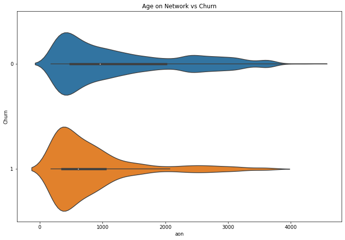

```python
plt.figure(figsize=(12,8))
sns.violinplot(x='aon', y='Churn', data=data)
plt.title('Age on Network vs Churn')
plt.show()
```

- The customers with lesser 'aon' are more likely to Churn when compared to the Customers with higer 'aon'

```python
# function for numerical variable univariate analysis
from tabulate import tabulate
def num_univariate_analysis(column_names,scale='linear') :
    # boxplot for column vs target

    fig = plt.figure(figsize=(16,8))
    ax1 = fig.add_subplot(1,3,1)
    sns.violinplot(x='Churn', y = column_names[0], data = data, ax=ax1)
    title = ''.join(column_names[0]) +' vs Churn'
    ax1.set(title=title)
    if scale == 'log' :
        plt.yscale('log')
        ax1.set(ylabel= column_names[0] + '(Log Scale)')

    ax2 = fig.add_subplot(1,3,2)
    sns.violinplot(x='Churn', y = column_names[1], data = data, ax=ax2)
    title = ''.join(column_names[1]) +' vs Churn'
    ax2.set(title=title)
    if scale == 'log' :
        plt.yscale('log')
        ax2.set(ylabel= column_names[1] + '(Log Scale)')

    ax3 = fig.add_subplot(1,3,3)
    sns.violinplot(x='Churn', y = column_names[2], data = data, ax=ax3)
    title = ''.join(column_names[2]) +' vs Churn'
    ax3.set(title=title)
    if scale == 'log' :
        plt.yscale('log')
        ax3.set(ylabel= column_names[2] + '(Log Scale)')

    # summary statistic

    print('Customers who churned (Churn : 1)')
    print(churned_customers[column_names].describe())

    print('\nCustomers who did not churn (Churn : 0)')
    print(non_churned_customers[column_names].describe(),'\n')
```

```python
# function for categorical variable univariate analysis
!pip install sidetable
import sidetable
def cat_univariate_analysis(column_names,figsize=(16,4)) :

    # column vs target count plot
    fig = plt.figure(figsize=figsize)

    ax1 = fig.add_subplot(1,3,1)
    sns.countplot(x=column_names[0],hue='Churn',data=data, ax=ax1)
    title = column_names[0] + ' vs No of Churned Customers'
    ax1.set(title= title)
    ax1.legend(loc='upper right')


    ax2 = fig.add_subplot(1,3,2)
    sns.countplot(x=column_names[1],hue='Churn',data=data, ax=ax2)
    title = column_names[1] + ' vs No of Churned Customers'
    ax2.set(title= title)
    ax2.legend(loc='upper right')


    ax3 = fig.add_subplot(1,3,3)
    sns.countplot(x=column_names[2],hue='Churn',data=data, ax=ax3)
    title = column_names[2] + ' vs No of Churned Customers'
    ax3.set(title= title)
    ax3.legend(loc='upper right')


    # Percentages
    print('Customers who churned (Churn : 1)')
    print(tabulate(pd.DataFrame(churned_customers.stb.freq([column_names[0]])), headers='keys', tablefmt='psql'),'\n')
    print(tabulate(pd.DataFrame(churned_customers.stb.freq([column_names[1]])), headers='keys', tablefmt='psql'),'\n')
    print(tabulate(pd.DataFrame(churned_customers.stb.freq([column_names[2]])), headers='keys', tablefmt='psql'),'\n')

    print('\nCustomers who did not churn (Churn : 0)')
    print(tabulate(pd.DataFrame(non_churned_customers.stb.freq([column_names[0]])), headers='keys', tablefmt='psql'),'\n')
    print(tabulate(pd.DataFrame(non_churned_customers.stb.freq([column_names[1]])), headers='keys', tablefmt='psql'),'\n')
    print(tabulate(pd.DataFrame(non_churned_customers.stb.freq([column_names[2]])), headers='keys', tablefmt='psql'),'\n')
```

#### arpu_6, arpu_7 , arpu_8

```
Customers who churned (Churn : 1)
             arpu_6        arpu_7       arpu_8
count   2593.000000   2593.000000  2593.000000
mean     678.716970    550.511946   243.063343
std      551.792864    517.241221   378.843531
min     -209.465000   -158.963000   -37.887000
25%      396.507000    289.641000     0.000000
50%      573.396000    464.674000   101.894000
75%      819.460000    691.588000   351.028000
max    11505.508000  13224.119000  5228.826000

Customers who did not churn (Churn : 0)
             arpu_6        arpu_7        arpu_8
count  27418.000000  27418.000000  27418.000000
mean     578.637360    592.788162    562.453248
std      429.988265    457.265996    492.802655
min    -2258.709000  -2014.045000   -945.808000
25%      362.218000    369.610500    319.118500
50%      489.324000    496.182500    471.024000
75%      690.891750    701.418000    690.921000
max    27731.088000  35145.834000  33543.624000
```

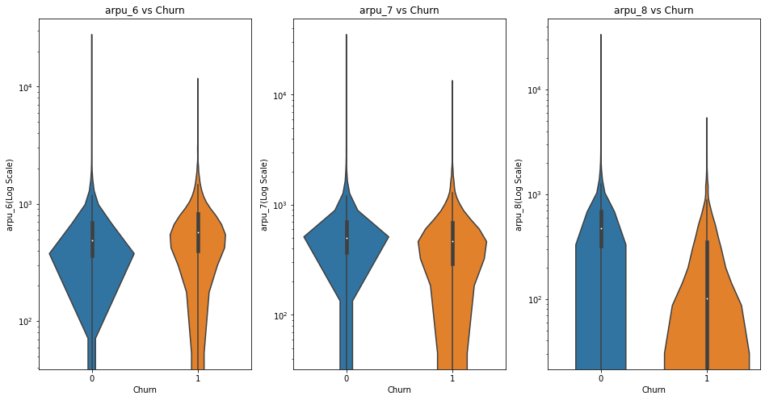

```python
columns = ['arpu_6','arpu_7','arpu_8']
num_univariate_analysis(columns,'log')
```

- We can understand from the above plots that revenue generated by the Customers who are about to churn is very unstable.
- The Customers whose arpu decreases in 7th month are more likely to churn when compared to ones with increase in arpu.

#### total_og_mou_6, total_og_mou_7, total_og_mou_8

```
Customers who churned (Churn : 1)
       total_og_mou_6  total_og_mou_7  total_og_mou_8
count     2593.000000     2593.000000     2593.000000
mean       867.961342      677.868909      225.083741
std        852.697688      786.961399      471.672718
min          0.000000        0.000000        0.000000
25%        277.880000      110.090000        0.000000
50%        658.360000      466.910000        0.000000
75%       1209.040000      926.760000      255.810000
max       8488.360000     8285.640000     5206.210000

Customers who did not churn (Churn : 0)
       total_og_mou_6  total_og_mou_7  total_og_mou_8
count    27418.000000    27418.000000    27418.000000
mean       669.554896      712.080684      661.480046
std        636.531612      674.580516      691.079113
min          0.000000        0.000000        0.000000
25%        265.682500      284.500000      227.970000
50%        500.410000      529.935000      470.475000
75%        872.070000      931.197500      866.045000
max      10674.030000    11365.310000    14043.060000
```

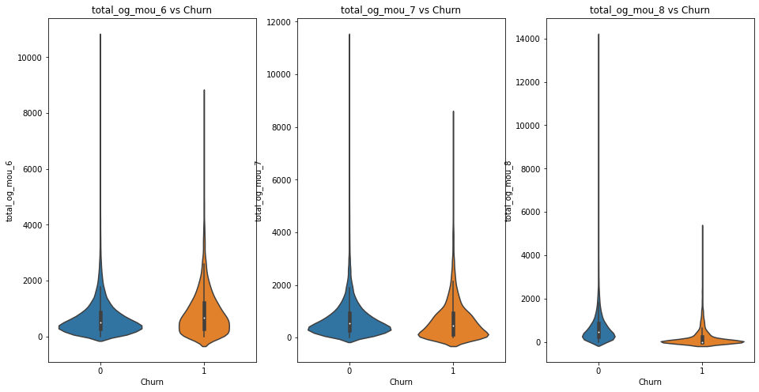

```python
columns = ['total_og_mou_6', 'total_og_mou_7', 'total_og_mou_8']
num_univariate_analysis(columns)
```

- The Customers with high total_og_mou in 6th month and lower total_og_mou in 7th month are more likely to churn compared to the rest.

#### 'total_ic_mou_6', 'total_ic_mou_7', 'total_ic_mou_8'

```
Customers who churned (Churn : 1)
       total_ic_mou_6  total_ic_mou_7  total_ic_mou_8
count     2593.000000     2593.000000     2593.000000
mean       241.954404      193.341076       68.807042
std        360.836586      318.183813      154.450340
min          0.000000        0.000000        0.000000
25%         49.460000       27.890000        0.000000
50%        137.330000       99.980000        0.000000
75%        289.510000      235.740000       70.290000
max       6633.180000     5137.560000     1859.280000

Customers who did not churn (Churn : 0)
       total_ic_mou_6  total_ic_mou_7  total_ic_mou_8
count    27418.000000    27418.000000    27418.000000
mean       313.712052      326.369333      316.858595
std        360.580253      372.112086      366.818717
min          0.000000        0.000000        0.000000
25%         94.460000      107.802500       98.265000
50%        212.160000      222.290000      212.360000
75%        401.602500      410.182500      402.270000
max       6798.640000     7279.080000     5990.710000
```

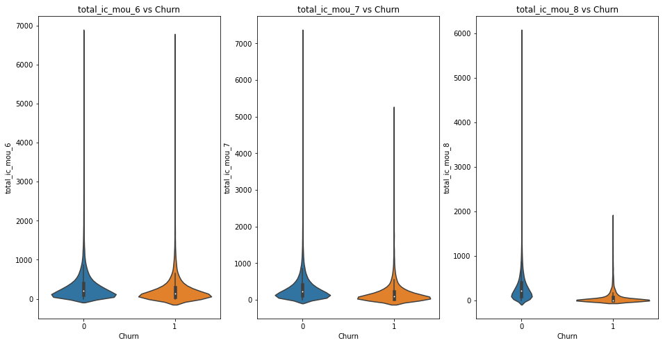

```python
columns = ['total_ic_mou_6', 'total_ic_mou_7', 'total_ic_mou_8']
num_univariate_analysis(columns)
```

- The Customers with decrease in rate of total_ic_mou in 7th month are more likely to churn, compared to the rest.

#### vol_2g_mb_6, vol_2g_mb_7, vol_2g_mb_8

```
Customers who churned (Churn : 1)
       vol_2g_mb_6  vol_2g_mb_7  vol_2g_mb_8
count  2593.000000  2593.000000  2593.000000
mean     60.775588    49.054393    15.283185
std     243.084276   219.485813   120.975111
min       0.000000     0.000000     0.000000
25%       0.000000     0.000000     0.000000
50%       0.000000     0.000000     0.000000
75%       0.000000     0.000000     0.000000
max    4017.160000  3430.730000  3349.190000

Customers who did not churn (Churn : 0)
        vol_2g_mb_6   vol_2g_mb_7   vol_2g_mb_8
count  27418.000000  27418.000000  27418.000000
mean      80.569210     80.925060     74.309036
std      280.420463    285.265125    277.889339
min        0.000000      0.000000      0.000000
25%        0.000000      0.000000      0.000000
50%        0.000000      0.000000      0.000000
75%       16.937500     18.267500     14.245000
max    10285.900000   7873.550000  11117.610000
```

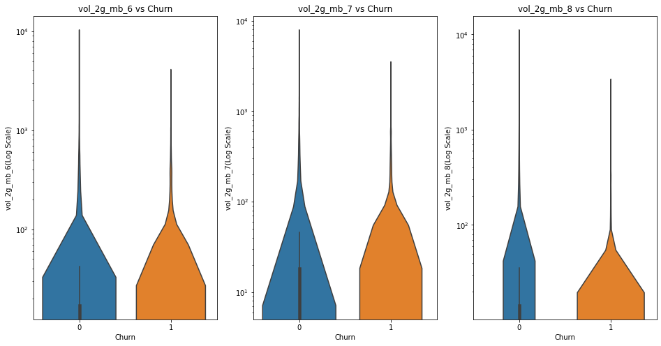

```python
columns = ['vol_2g_mb_6', 'vol_2g_mb_7', 'vol_2g_mb_8']
num_univariate_analysis(columns, 'log')
```

- Customers with stable usage of 2g volumes throughout 6 and 7 months are less likely to churn.
- Customers with fall in consumption of 2g volumes in 7th month are more likely to Churn.

#### vol_3g_mb_6, vol_3g_mb_7, vol_3g_mb_8, monthly_3g_6

```
Customers who churned (Churn : 1)
       vol_3g_mb_6   vol_3g_mb_7   vol_3g_mb_8
count  2593.000000   2593.000000   2593.000000
mean    188.395461    157.714254     56.776880
std     715.327843    690.773561    446.532769
min       0.000000      0.000000      0.000000
25%       0.000000      0.000000      0.000000
50%       0.000000      0.000000      0.000000
75%       0.000000      0.000000      0.000000
max    9400.120000  15115.510000  13440.720000

Customers who did not churn (Churn : 0)
        vol_3g_mb_6   vol_3g_mb_7   vol_3g_mb_8
count  27418.000000  27418.000000  27418.000000
mean     265.012522    289.478375    290.016390
std      878.846885    868.808831    885.821105
min        0.000000      0.000000      0.000000
25%        0.000000      0.000000      0.000000
50%        0.000000      0.000000      0.000000
75%        0.000000     35.855000     27.120000
max    45735.400000  28144.120000  30036.060000
```

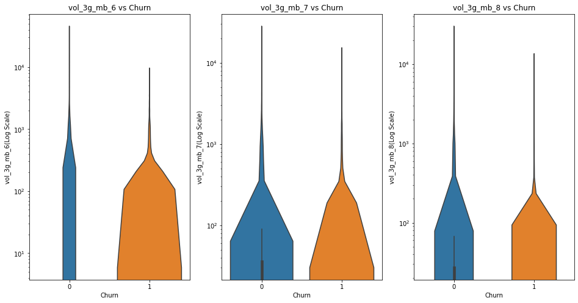

```python
columns = ['vol_3g_mb_6', 'vol_3g_mb_7', 'vol_3g_mb_8', 'monthly_3g_6']
num_univariate_analysis(columns, 'log')
```

- Customers with stable usage of 3g volumes throughout 6 and 7 months are less likely to churn.
- Customers with fall in consumption of 3g volumes in 7th month are more likely to Churn.

#### monthly_2g_6, monthly_2g_7, monthly_2g_8

```
Customers who churned (Churn : 1)
+----+----------------+---------+------------+--------------------+----------------------+
|    |   monthly_2g_6 |   count |    percent |   cumulative_count |   cumulative_percent |
|----+----------------+---------+------------+--------------------+----------------------|
|  0 |              0 |    2454 | 94.6394    |               2454 |              94.6394 |
|  1 |              1 |     126 |  4.85924   |               2580 |              99.4987 |
|  2 |              2 |      11 |  0.424219  |               2591 |              99.9229 |
|  3 |              4 |       2 |  0.0771307 |               2593 |             100      |
+----+----------------+---------+------------+--------------------+----------------------+

+----+----------------+---------+-----------+--------------------+----------------------+
|    |   monthly_2g_7 |   count |   percent |   cumulative_count |   cumulative_percent |
|----+----------------+---------+-----------+--------------------+----------------------|
|  0 |              0 |    2477 | 95.5264   |               2477 |              95.5264 |
|  1 |              1 |     104 |  4.0108   |               2581 |              99.5372 |
|  2 |              2 |      12 |  0.462784 |               2593 |             100      |
+----+----------------+---------+-----------+--------------------+----------------------+

+----+----------------+---------+------------+--------------------+----------------------+
|    |   monthly_2g_8 |   count |    percent |   cumulative_count |   cumulative_percent |
|----+----------------+---------+------------+--------------------+----------------------|
|  0 |              0 |    2555 | 98.5345    |               2555 |              98.5345 |
|  1 |              1 |      37 |  1.42692   |               2592 |              99.9614 |
|  2 |              2 |       1 |  0.0385654 |               2593 |             100      |
+----+----------------+---------+------------+--------------------+----------------------+


Customers who did not churn (Churn : 0)
+----+----------------+---------+------------+--------------------+----------------------+
|    |   monthly_2g_6 |   count |    percent |   cumulative_count |   cumulative_percent |
|----+----------------+---------+------------+--------------------+----------------------|
|  0 |              0 |   24228 | 88.3653    |              24228 |              88.3653 |
|  1 |              1 |    2825 | 10.3035    |              27053 |              98.6688 |
|  2 |              2 |     334 |  1.21818   |              27387 |              99.8869 |
|  3 |              3 |      26 |  0.0948282 |              27413 |              99.9818 |
|  4 |              4 |       5 |  0.0182362 |              27418 |             100      |
+----+----------------+---------+------------+--------------------+----------------------+

+----+----------------+---------+-------------+--------------------+----------------------+
|    |   monthly_2g_7 |   count |     percent |   cumulative_count |   cumulative_percent |
|----+----------------+---------+-------------+--------------------+----------------------|
|  0 |              0 |   24079 | 87.8219     |              24079 |              87.8219 |
|  1 |              1 |    2909 | 10.6098     |              26988 |              98.4317 |
|  2 |              2 |     394 |  1.43701    |              27382 |              99.8687 |
|  3 |              3 |      29 |  0.10577    |              27411 |              99.9745 |
|  4 |              4 |       5 |  0.0182362  |              27416 |              99.9927 |
|  5 |              5 |       2 |  0.00729448 |              27418 |             100      |
+----+----------------+---------+-------------+--------------------+----------------------+

+----+----------------+---------+-------------+--------------------+----------------------+
|    |   monthly_2g_8 |   count |     percent |   cumulative_count |   cumulative_percent |
|----+----------------+---------+-------------+--------------------+----------------------|
|  0 |              0 |   24383 | 88.9306     |              24383 |              88.9306 |
|  1 |              1 |    2724 |  9.93508    |              27107 |              98.8657 |
|  2 |              2 |     282 |  1.02852    |              27389 |              99.8942 |
|  3 |              3 |      22 |  0.0802393  |              27411 |              99.9745 |
|  4 |              4 |       5 |  0.0182362  |              27416 |              99.9927 |
|  5 |              5 |       2 |  0.00729448 |              27418 |             100      |
+----+----------------+---------+-------------+--------------------+----------------------+
```

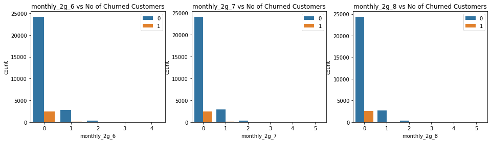

```python
columns = ['monthly_2g_6', 'monthly_2g_7', 'monthly_2g_8']
cat_univariate_analysis(columns)
```

#### monthly_3g_6, monthly_3g_7, monthly_3g_8

```
Customers who churned (Churn : 1)
+----+----------------+---------+------------+--------------------+----------------------+
|    |   monthly_3g_6 |   count |    percent |   cumulative_count |   cumulative_percent |
|----+----------------+---------+------------+--------------------+----------------------|
|  0 |              0 |    2352 | 90.7057    |               2352 |              90.7057 |
|  1 |              1 |     170 |  6.55611   |               2522 |              97.2619 |
|  2 |              2 |      49 |  1.8897    |               2571 |              99.1516 |
|  3 |              3 |      13 |  0.50135   |               2584 |              99.6529 |
|  4 |              5 |       4 |  0.154261  |               2588 |              99.8072 |
|  5 |              4 |       4 |  0.154261  |               2592 |              99.9614 |
|  6 |              6 |       1 |  0.0385654 |               2593 |             100      |
+----+----------------+---------+------------+--------------------+----------------------+

+----+----------------+---------+------------+--------------------+----------------------+
|    |   monthly_3g_7 |   count |    percent |   cumulative_count |   cumulative_percent |
|----+----------------+---------+------------+--------------------+----------------------|
|  0 |              0 |    2399 | 92.5183    |               2399 |              92.5183 |
|  1 |              1 |     136 |  5.24489   |               2535 |              97.7632 |
|  2 |              2 |      48 |  1.85114   |               2583 |              99.6143 |
|  3 |              3 |       9 |  0.347088  |               2592 |              99.9614 |
|  4 |              5 |       1 |  0.0385654 |               2593 |             100      |
+----+----------------+---------+------------+--------------------+----------------------+

+----+----------------+---------+------------+--------------------+----------------------+
|    |   monthly_3g_8 |   count |    percent |   cumulative_count |   cumulative_percent |
|----+----------------+---------+------------+--------------------+----------------------|
|  0 |              0 |    2524 | 97.339     |               2524 |              97.339  |
|  1 |              1 |      56 |  2.15966   |               2580 |              99.4987 |
|  2 |              2 |       8 |  0.308523  |               2588 |              99.8072 |
|  3 |              3 |       4 |  0.154261  |               2592 |              99.9614 |
|  4 |              4 |       1 |  0.0385654 |               2593 |             100      |
+----+----------------+---------+------------+--------------------+----------------------+


Customers who did not churn (Churn : 0)
+----+----------------+---------+-------------+--------------------+----------------------+
|    |   monthly_3g_6 |   count |     percent |   cumulative_count |   cumulative_percent |
|----+----------------+---------+-------------+--------------------+----------------------|
|  0 |              0 |   24080 | 87.8255     |              24080 |              87.8255 |
|  1 |              1 |    2371 |  8.6476     |              26451 |              96.4731 |
```

[output cut: 33 more lines]

```
|    |   monthly_3g_8 |   count |     percent |   cumulative_count |   cumulative_percent |
|----+----------------+---------+-------------+--------------------+----------------------|
|  0 |              0 |   24002 | 87.541      |              24002 |              87.541  |
|  1 |              1 |    2347 |  8.56007    |              26349 |              96.1011 |
|  2 |              2 |     728 |  2.65519    |              27077 |              98.7563 |
|  3 |              3 |     193 |  0.703917   |              27270 |              99.4602 |
|  4 |              4 |      86 |  0.313663   |              27356 |              99.7739 |
|  5 |              5 |      30 |  0.109417   |              27386 |              99.8833 |
|  6 |              6 |      14 |  0.0510613  |              27400 |              99.9343 |
|  7 |              7 |       9 |  0.0328252  |              27409 |              99.9672 |
|  8 |              9 |       3 |  0.0109417  |              27412 |              99.9781 |
|  9 |              8 |       3 |  0.0109417  |              27415 |              99.9891 |
| 10 |             10 |       2 |  0.00729448 |              27417 |              99.9964 |
| 11 |             16 |       1 |  0.00364724 |              27418 |             100      |
+----+----------------+---------+-------------+--------------------+----------------------+
```

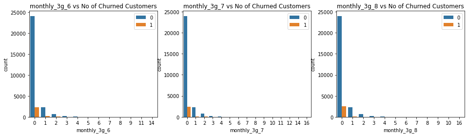

```python
columns = ['monthly_3g_6', 'monthly_3g_7', 'monthly_3g_8']
cat_univariate_analysis(columns)
```

#### sachet_3g_6, sachet_3g_7, sachet_3g_8

```python
columns = ['sachet_3g_6', 'sachet_3g_7','sachet_3g_8']
print(data[columns].dtypes)
cat_univariate_analysis(columns)
```

[output not shown]

#### aug_vbc_3g, jul_vbc_3g, jun_vbc_3g

```
Customers who churned (Churn : 1)
          vbc_3g_6     vbc_3g_7     vbc_3g_8
count  2593.000000  2593.000000  2593.000000
mean     81.564601    71.143880    32.610659
std     320.898511   284.882601   197.998246
min       0.000000     0.000000     0.000000
25%       0.000000     0.000000     0.000000
50%       0.000000     0.000000     0.000000
75%       0.000000     0.000000     0.000000
max    6931.810000  4908.270000  5738.740000

Customers who did not churn (Churn : 0)
           vbc_3g_6      vbc_3g_7      vbc_3g_8
count  27418.000000  27418.000000  27418.000000
mean     125.124167    141.178182    138.597023
std      395.413666    417.292310    402.761779
min        0.000000      0.000000      0.000000
25%        0.000000      0.000000      0.000000
50%        0.000000      0.000000      0.000000
75%        0.000000      9.940000     17.675000
max    11166.210000   9165.600000  12916.220000
```

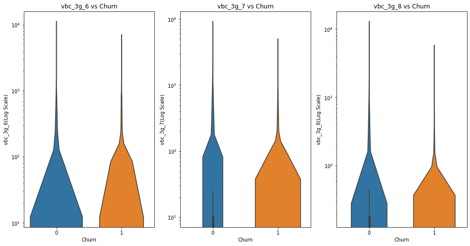

```python
columns = [ 'vbc_3g_6', 'vbc_3g_7','vbc_3g_8']
num_univariate_analysis(columns, 'log')
```

### Bivariate Analysis

```python
data.head()
```

| mobile_number | arpu_6 | arpu_7 | arpu_8 | onnet_mou_6 | onnet_mou_7 | onnet_mou_8 | offnet_mou_6 | offnet_mou_7 | offnet_mou_8 | roam_ic_mou_6 | roam_ic_mou_7 | roam_ic_mou_8 | roam_og_mou_6 | roam_og_mou_7 | roam_og_mou_8 | loc_og_t2t_mou_6 | loc_og_t2t_mou_7 | loc_og_t2t_mou_8 | loc_og_t2m_mou_6 | loc_og_t2m_mou_7 | loc_og_t2m_mou_8 | loc_og_t2f_mou_6 | loc_og_t2f_mou_7 | loc_og_t2f_mou_8 | loc_og_t2c_mou_6 | loc_og_t2c_mou_7 | loc_og_t2c_mou_8 | loc_og_mou_6 | loc_og_mou_7 | … |
| --- | --- | --- | --- | --- | --- | --- | --- | --- | --- | --- | --- | --- | --- | --- | --- | --- | --- | --- | --- | --- | --- | --- | --- | --- | --- | --- | --- | --- | --- | --- |
| 7000701601 | 1069.180 | 1349.850 | 3171.480 | 57.84 | 54.68 | 52.29 | 453.43 | 567.16 | 325.91 | 16.23 | 33.49 | 31.64 | 23.74 | 12.59 | 38.06 | 51.39 | 31.38 | 40.28 | 308.63 | 447.38 | 162.28 | 62.13 | 55.14 | 53.23 | 0.0 | 0.0 | 0.00 | 422.16 | 533.91 | … |
| 7001524846 | 378.721 | 492.223 | 137.362 | 413.69 | 351.03 | 35.08 | 94.66 | 80.63 | 136.48 | 0.00 | 0.00 | 0.00 | 0.00 | 0.00 | 0.00 | 297.13 | 217.59 | 12.49 | 80.96 | 70.58 | 50.54 | 0.00 | 0.00 | 0.00 | 0.0 | 0.0 | 7.15 | 378.09 | 288.18 | … |
| 7002191713 | 492.846 | 205.671 | 593.260 | 501.76 | 108.39 | 534.24 | 413.31 | 119.28 | 482.46 | 23.53 | 144.24 | 72.11 | 7.98 | 35.26 | 1.44 | 49.63 | 6.19 | 36.01 | 151.13 | 47.28 | 294.46 | 4.54 | 0.00 | 23.51 | 0.0 | 0.0 | 0.49 | 205.31 | 53.48 | … |
| 7000875565 | 430.975 | 299.869 | 187.894 | 50.51 | 74.01 | 70.61 | 296.29 | 229.74 | 162.76 | 0.00 | 2.83 | 0.00 | 0.00 | 17.74 | 0.00 | 42.61 | 65.16 | 67.38 | 273.29 | 145.99 | 128.28 | 0.00 | 4.48 | 10.26 | 0.0 | 0.0 | 0.00 | 315.91 | 215.64 | … |
| 7000187447 | 690.008 | 18.980 | 25.499 | 1185.91 | 9.28 | 7.79 | 61.64 | 0.00 | 5.54 | 0.00 | 4.76 | 4.81 | 0.00 | 8.46 | 13.34 | 38.99 | 0.00 | 0.00 | 58.54 | 0.00 | 0.00 | 0.00 | 0.00 | 0.00 | 0.0 | 0.0 | 0.00 | 97.54 | 0.00 | … |

### 'total_og_mou_6' vs 'total_og_mou_8' with respect to Churn.

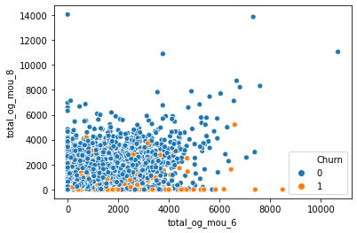

```python
sns.scatterplot(x=data['total_og_mou_6'],y=data['total_og_mou_8'],hue=data['Churn'])
```

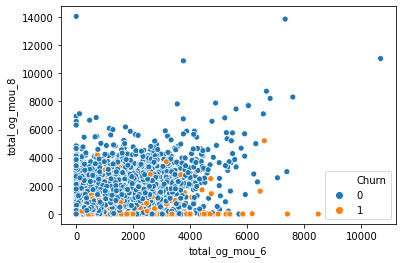

```python
sns.scatterplot(x=data['total_og_mou_6'],y=data['total_og_mou_8'],hue=data['Churn'])
```

### 'aon' vs 'total_og_mou_8' with respect to Churn.

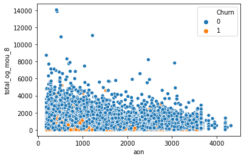

```python
sns.scatterplot(x=data['aon'],y=data['total_og_mou_8'],hue=data['Churn'])
```

- The customers with lesser total_og_mou_8 and aon are more likely to churn compared to the one with higher total_og_mou_8 and aon.

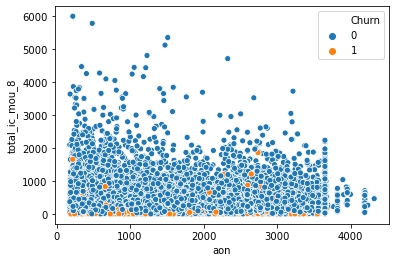

```python
sns.scatterplot(x=data['aon'],y=data['total_ic_mou_8'],hue=data['Churn'])
```

- The customers with less total_ic_mou_8 are more likely to churn irrespective of aon.
- The customers with total_ic_mou_8 > 2000 are very less likely to churn.

### 'max_rech_amt_6' vs 'max_rech_amt_8' with respect to 'Churn'.

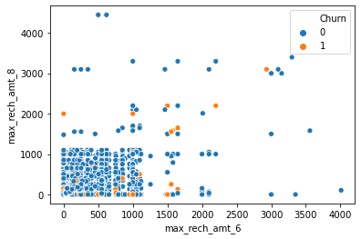

```python
sns.scatterplot(x=data['max_rech_amt_6'],y=data['max_rech_amt_8'],hue=data['Churn'])
```

### Correlation Analysis

```python
# function to correlate variables
def correlation(dataframe) :

    columnsForAnalysis = set(dataframe.columns.values) - {'Churn'}
    cor0=dataframe[columnsForAnalysis].corr()
    type(cor0)
    cor0.where(np.triu(np.ones(cor0.shape),k=1).astype(np.bool))
    cor0=cor0.unstack().reset_index()
    cor0.columns=['VAR1','VAR2','CORR']
    cor0.dropna(subset=['CORR'], inplace=True)
    cor0.CORR=round(cor0['CORR'],2)
    cor0.CORR=cor0.CORR.abs()
    cor0.sort_values(by=['CORR'],ascending=False)
    cor0=cor0[~(cor0['VAR1']==cor0['VAR2'])]

    # removing duplicate correlations
    cor0['pair'] = cor0[['VAR1', 'VAR2']].apply(lambda x: '{}-{}'.format(*sorted((x[0], x[1]))), axis=1)

    cor0 = cor0.drop_duplicates(subset=['pair'], keep='first')
    cor0 = cor0[['VAR1', 'VAR2','CORR']]
    return pd.DataFrame(cor0.sort_values(by=['CORR'],ascending=False))
```

```python
# Correlations for Churn : 0  - non churn customers
# Absolute values are reported
pd.set_option('precision', 2)
cor_0 = correlation(non_churned_customers)

# filtering for correlations >= 40%
condition = cor_0['CORR'] > 0.4
cor_0 = cor_0[condition]
cor_0.style.background_gradient(cmap='GnBu').hide_index()
```

| VAR1 | VAR2 | CORR |
| --- | --- | --- |
| isd_og_mou_8 | isd_og_mou_7 | 0.96 |
| isd_og_mou_8 | isd_og_mou_6 | 0.95 |
| arpu_8 | total_rech_amt_8 | 0.95 |
| isd_og_mou_7 | isd_og_mou_6 | 0.95 |
| arpu_6 | total_rech_amt_6 | 0.94 |
| total_rech_amt_7 | arpu_7 | 0.94 |
| Average_rech_amt_6n7 | arpu_7 | 0.91 |
| total_rech_amt_7 | Average_rech_amt_6n7 | 0.91 |
| total_ic_mou_6 | loc_ic_mou_6 | 0.90 |
| Average_rech_amt_6n7 | total_rech_amt_6 | 0.90 |
| arpu_6 | Average_rech_amt_6n7 | 0.89 |
| loc_ic_mou_8 | total_ic_mou_8 | 0.89 |
| loc_ic_mou_7 | total_ic_mou_7 | 0.88 |
| loc_ic_mou_7 | loc_ic_mou_8 | 0.85 |
| std_og_t2t_mou_8 | onnet_mou_8 | 0.85 |
| loc_ic_mou_8 | loc_ic_t2m_mou_8 | 0.85 |
| loc_ic_t2m_mou_6 | loc_ic_mou_6 | 0.85 |
| std_og_t2m_mou_8 | offnet_mou_8 | 0.85 |
| std_og_t2t_mou_7 | onnet_mou_7 | 0.84 |
| std_og_mou_8 | total_og_mou_8 | 0.84 |
| loc_og_mou_8 | loc_og_mou_7 | 0.84 |
| std_ic_mou_8 | std_ic_t2m_mou_8 | 0.84 |
| std_og_t2t_mou_6 | onnet_mou_6 | 0.84 |
| offnet_mou_7 | std_og_t2m_mou_7 | 0.84 |
| total_og_mou_7 | std_og_mou_7 | 0.83 |
| loc_ic_mou_7 | loc_ic_mou_6 | 0.83 |
| total_ic_mou_7 | total_ic_mou_8 | 0.83 |
| loc_og_t2t_mou_8 | loc_og_t2t_mou_7 | 0.83 |
| loc_ic_mou_7 | loc_ic_t2m_mou_7 | 0.83 |
| loc_ic_t2m_mou_7 | loc_ic_t2m_mou_8 | 0.82 |

[output cut: 332 more lines]

```python
# Correlations for Churn : 1  - churned customers
# Absolute values are reported
pd.set_option('precision', 2)
cor_1 = correlation(churned_customers)

# filtering for correlations >= 40%
condition = cor_1['CORR'] > 0.4
cor_1 = cor_1[condition]
cor_1.style.background_gradient(cmap='GnBu').hide_index()
```

| VAR1 | VAR2 | CORR |
| --- | --- | --- |
| og_others_7 | og_others_8 | 1.00 |
| arpu_8 | total_rech_amt_8 | 0.96 |
| arpu_6 | total_rech_amt_6 | 0.95 |
| std_og_mou_8 | total_og_mou_8 | 0.95 |
| total_rech_amt_7 | arpu_7 | 0.95 |
| std_og_t2t_mou_7 | onnet_mou_7 | 0.95 |
| total_og_mou_7 | std_og_mou_7 | 0.94 |
| og_others_8 | loc_og_t2f_mou_6 | 0.93 |
| std_og_t2t_mou_8 | onnet_mou_8 | 0.93 |
| loc_og_t2f_mou_7 | loc_og_t2f_mou_6 | 0.93 |
| og_others_7 | loc_og_t2f_mou_6 | 0.93 |
| total_og_mou_6 | std_og_mou_6 | 0.92 |
| offnet_mou_6 | std_og_t2m_mou_6 | 0.92 |
| offnet_mou_7 | std_og_t2m_mou_7 | 0.92 |
| std_og_t2t_mou_6 | onnet_mou_6 | 0.92 |
| std_ic_mou_8 | std_ic_t2m_mou_8 | 0.92 |
| loc_og_t2f_mou_7 | og_others_8 | 0.91 |
| loc_og_t2f_mou_7 | og_others_7 | 0.91 |
| loc_ic_mou_8 | loc_ic_t2m_mou_8 | 0.90 |
| loc_ic_t2m_mou_6 | loc_ic_mou_6 | 0.90 |
| loc_ic_mou_8 | total_ic_mou_8 | 0.89 |
| loc_og_t2m_mou_8 | loc_og_mou_8 | 0.88 |
| total_ic_mou_6 | loc_ic_mou_6 | 0.87 |
| std_og_t2m_mou_8 | offnet_mou_8 | 0.87 |
| loc_ic_mou_7 | total_ic_mou_7 | 0.86 |
| loc_ic_mou_7 | loc_ic_t2m_mou_7 | 0.84 |
| loc_og_t2m_mou_7 | loc_og_mou_7 | 0.84 |
| std_ic_t2m_mou_7 | std_ic_mou_7 | 0.82 |
| total_ic_mou_8 | loc_ic_t2m_mou_8 | 0.81 |
| std_og_mou_8 | std_og_t2t_mou_8 | 0.79 |

[output cut: 255 more lines]

## Data Preparation

### Derived Variables

```python
# Derived variables to measure change in usage

# Usage
data['delta_vol_2g'] = data['vol_2g_mb_8'] - data['vol_2g_mb_6'].add(data['vol_2g_mb_7']).div(2)
data['delta_vol_3g'] = data['vol_3g_mb_8'] - data['vol_3g_mb_6'].add(data['vol_3g_mb_7']).div(2)
data['delta_total_og_mou'] = data['total_og_mou_8'] - data['total_og_mou_6'].add(data['total_og_mou_7']).div(2)
data['delta_total_ic_mou'] = data['total_ic_mou_8'] - data['total_ic_mou_6'].add(data['total_ic_mou_7']).div(2)
data['delta_vbc_3g'] = data['vbc_3g_8'] - data['vbc_3g_6'].add(data['vbc_3g_7']).div(2)

# Revenue
data['delta_arpu'] = data['arpu_8'] - data['arpu_6'].add(data['arpu_7']).div(2)
data['delta_total_rech_amt'] = data['total_rech_amt_8'] - data['total_rech_amt_6'].add(data['total_rech_amt_7']).div(2)
```

```python
# Removing variables used for derivation :
data.drop(columns=[
 'vol_2g_mb_8', 'vol_2g_mb_6', 'vol_2g_mb_7',
  'vol_3g_mb_8'  , 'vol_3g_mb_6', 'vol_3g_mb_7' ,
    'total_og_mou_8','total_og_mou_6', 'total_og_mou_7',
    'total_ic_mou_8','total_ic_mou_6', 'total_ic_mou_7',
    'vbc_3g_8','vbc_3g_6','vbc_3g_7',
    'arpu_8','arpu_6','arpu_7',
    'total_rech_amt_8', 'total_rech_amt_6', 'total_rech_amt_7'

], inplace=True)
```

### Outlier Treatment

```python
# Looking at quantiles from 0.90 to 1.
data.quantile(np.arange(0.9,1.01,0.01)).style.bar()
```

|  | onnet_mou_6 | onnet_mou_7 | onnet_mou_8 | offnet_mou_6 | offnet_mou_7 | offnet_mou_8 | roam_ic_mou_6 | roam_ic_mou_7 | roam_ic_mou_8 | roam_og_mou_6 | roam_og_mou_7 | roam_og_mou_8 | loc_og_t2t_mou_6 | loc_og_t2t_mou_7 | loc_og_t2t_mou_8 | loc_og_t2m_mou_6 | loc_og_t2m_mou_7 | loc_og_t2m_mou_8 | loc_og_t2f_mou_6 | loc_og_t2f_mou_7 | loc_og_t2f_mou_8 | loc_og_t2c_mou_6 | loc_og_t2c_mou_7 | loc_og_t2c_mou_8 | loc_og_mou_6 | loc_og_mou_7 | loc_og_mou_8 | std_og_t2t_mou_6 | std_og_t2t_mou_7 | … |
| --- | --- | --- | --- | --- | --- | --- | --- | --- | --- | --- | --- | --- | --- | --- | --- | --- | --- | --- | --- | --- | --- | --- | --- | --- | --- | --- | --- | --- | --- | --- |
| 0.9 | 794.98 | 824.38 | 723.61 | 915.58 | 935.69 | 853.79 | 32.73 | 18.36 | 18.68 | 64.48 | 41.20 | 37.11 | 207.93 | 207.84 | 196.91 | 435.16 | 437.49 | 416.66 | 18.38 | 18.66 | 16.96 | 4.04 | 4.84 | 4.45 | 661.74 | 657.38 | 633.34 | 630.53 | 663.79 | … |
| 0.91 | 848.97 | 878.35 | 783.49 | 966.74 | 984.02 | 899.29 | 39.69 | 23.28 | 23.39 | 78.43 | 50.01 | 46.44 | 225.96 | 224.87 | 213.83 | 461.10 | 461.81 | 441.84 | 20.28 | 20.68 | 18.84 | 4.68 | 5.51 | 5.11 | 703.11 | 692.67 | 669.63 | 686.26 | 722.84 | … |
| 0.92 | 909.05 | 941.99 | 848.96 | 1031.39 | 1038.09 | 953.35 | 48.71 | 29.68 | 29.64 | 93.60 | 60.97 | 57.59 | 247.94 | 244.78 | 232.33 | 490.63 | 488.04 | 468.83 | 22.56 | 23.14 | 20.93 | 5.45 | 6.26 | 5.86 | 742.96 | 735.69 | 711.57 | 750.31 | 786.39 | … |
| 0.93 | 990.48 | 1016.15 | 920.96 | 1094.77 | 1103.93 | 1017.35 | 60.42 | 37.28 | 37.90 | 111.15 | 75.00 | 72.45 | 275.51 | 271.70 | 254.64 | 523.56 | 519.80 | 500.38 | 25.25 | 26.00 | 23.51 | 6.34 | 7.15 | 6.79 | 794.01 | 786.73 | 759.45 | 812.08 | 856.34 | … |
| 0.9400000000000001 | 1066.85 | 1097.12 | 1007.56 | 1168.09 | 1186.36 | 1096.62 | 73.96 | 49.44 | 48.29 | 137.40 | 94.73 | 90.27 | 307.64 | 305.87 | 282.50 | 563.70 | 559.41 | 537.10 | 29.13 | 29.75 | 26.89 | 7.36 | 8.45 | 7.84 | 855.97 | 849.42 | 817.15 | 888.23 | 933.58 | … |
| 0.9500000000000001 | 1153.97 | 1208.17 | 1115.66 | 1271.47 | 1286.28 | 1188.46 | 94.59 | 63.34 | 62.80 | 168.46 | 119.34 | 114.80 | 348.62 | 346.90 | 324.14 | 614.99 | 608.01 | 585.06 | 33.59 | 34.09 | 31.31 | 8.69 | 9.95 | 9.33 | 935.51 | 920.12 | 883.25 | 986.24 | 1029.29 | … |
| 0.9600000000000001 | 1282.78 | 1344.04 | 1256.34 | 1406.07 | 1407.78 | 1305.32 | 120.08 | 83.43 | 82.12 | 211.03 | 153.97 | 145.54 | 411.69 | 412.46 | 380.74 | 674.30 | 670.99 | 646.48 | 39.84 | 40.05 | 37.61 | 10.61 | 11.86 | 11.45 | 1025.57 | 1016.38 | 975.80 | 1099.72 | 1146.44 | … |
| 0.9700000000000001 | 1444.23 | 1497.25 | 1441.53 | 1578.82 | 1585.02 | 1481.57 | 155.13 | 117.54 | 112.07 | 270.52 | 203.66 | 188.86 | 508.01 | 500.20 | 458.64 | 758.99 | 749.79 | 734.08 | 49.38 | 49.09 | 46.36 | 13.04 | 14.68 | 14.14 | 1163.16 | 1143.62 | 1101.16 | 1243.36 | 1308.19 | … |
| 0.9800000000000001 | 1694.68 | 1772.62 | 1700.24 | 1837.93 | 1838.39 | 1739.01 | 221.26 | 166.28 | 165.81 | 363.12 | 282.49 | 266.53 | 668.59 | 660.28 | 596.48 | 885.83 | 868.35 | 853.83 | 62.69 | 63.06 | 60.11 | 17.15 | 19.23 | 18.67 | 1372.78 | 1338.79 | 1306.65 | 1458.71 | 1520.56 | … |
| 0.9900000000000001 | 2166.37 | 2220.37 | 2188.50 | 2326.29 | 2410.10 | 2211.64 | 349.35 | 292.54 | 288.49 | 543.71 | 448.13 | 432.74 | 1076.24 | 1059.88 | 956.50 | 1147.05 | 1112.66 | 1092.59 | 90.88 | 91.06 | 86.68 | 24.86 | 28.24 | 28.87 | 1806.94 | 1761.43 | 1689.07 | 1885.20 | 1919.19 | … |
| 1.0 | 7376.71 | 8157.78 | 10752.56 | 8362.36 | 9667.13 | 14007.34 | 2613.31 | 3813.29 | 4169.81 | 3775.11 | 2812.04 | 5337.04 | 6431.33 | 7400.66 | 10752.56 | 4729.74 | 4557.14 | 4961.33 | 1466.03 | 1196.43 | 928.49 | 342.86 | 569.71 | 351.83 | 10643.38 | 7674.78 | 11039.91 | 7366.58 | 8133.66 | … |

```python
# Looking at percentage change in quantiles from 0.90 to 1.
data.quantile(np.arange(0.9,1.01,0.01)).pct_change().mul(100).style.bar()
```

|  | onnet_mou_6 | onnet_mou_7 | onnet_mou_8 | offnet_mou_6 | offnet_mou_7 | offnet_mou_8 | roam_ic_mou_6 | roam_ic_mou_7 | roam_ic_mou_8 | roam_og_mou_6 | roam_og_mou_7 | roam_og_mou_8 | loc_og_t2t_mou_6 | loc_og_t2t_mou_7 | loc_og_t2t_mou_8 | loc_og_t2m_mou_6 | loc_og_t2m_mou_7 | loc_og_t2m_mou_8 | loc_og_t2f_mou_6 | loc_og_t2f_mou_7 | loc_og_t2f_mou_8 | loc_og_t2c_mou_6 | loc_og_t2c_mou_7 | loc_og_t2c_mou_8 | loc_og_mou_6 | loc_og_mou_7 | loc_og_mou_8 | std_og_t2t_mou_6 | std_og_t2t_mou_7 | … |
| --- | --- | --- | --- | --- | --- | --- | --- | --- | --- | --- | --- | --- | --- | --- | --- | --- | --- | --- | --- | --- | --- | --- | --- | --- | --- | --- | --- | --- | --- | --- |
| 0.9 | nan | nan | nan | nan | nan | nan | nan | nan | nan | nan | nan | nan | nan | nan | nan | nan | nan | nan | nan | nan | nan | nan | nan | nan | nan | nan | nan | nan | nan | … |
| 0.91 | 6.79 | 6.55 | 8.27 | 5.59 | 5.17 | 5.33 | 21.27 | 26.80 | 25.22 | 21.64 | 21.39 | 25.13 | 8.67 | 8.20 | 8.59 | 5.96 | 5.56 | 6.04 | 10.34 | 10.83 | 11.08 | 15.84 | 13.88 | 14.88 | 6.25 | 5.37 | 5.73 | 8.84 | 8.90 | … |
| 0.92 | 7.08 | 7.25 | 8.36 | 6.69 | 5.49 | 6.01 | 22.72 | 27.49 | 26.73 | 19.34 | 21.90 | 24.03 | 9.73 | 8.85 | 8.65 | 6.41 | 5.68 | 6.11 | 11.24 | 11.91 | 11.09 | 16.45 | 13.57 | 14.71 | 5.67 | 6.21 | 6.26 | 9.33 | 8.79 | … |
| 0.93 | 8.96 | 7.87 | 8.48 | 6.14 | 6.34 | 6.71 | 24.03 | 25.62 | 27.86 | 18.75 | 23.02 | 25.80 | 11.12 | 11.00 | 9.60 | 6.71 | 6.51 | 6.73 | 11.91 | 12.32 | 12.33 | 16.33 | 14.27 | 15.79 | 6.87 | 6.94 | 6.73 | 8.23 | 8.89 | … |
| 0.9400000000000001 | 7.71 | 7.97 | 9.40 | 6.70 | 7.47 | 7.79 | 22.41 | 32.61 | 27.41 | 23.62 | 26.30 | 24.59 | 11.66 | 12.58 | 10.94 | 7.67 | 7.62 | 7.34 | 15.38 | 14.43 | 14.39 | 16.09 | 18.10 | 15.52 | 7.80 | 7.97 | 7.60 | 9.38 | 9.02 | … |
| 0.9500000000000001 | 8.17 | 10.12 | 10.73 | 8.85 | 8.42 | 8.38 | 27.89 | 28.10 | 30.03 | 22.61 | 25.97 | 27.18 | 13.32 | 13.41 | 14.74 | 9.10 | 8.69 | 8.93 | 15.33 | 14.58 | 16.43 | 18.07 | 17.72 | 18.94 | 9.29 | 8.32 | 8.09 | 11.03 | 10.25 | … |
| 0.9600000000000001 | 11.16 | 11.25 | 12.61 | 10.59 | 9.45 | 9.83 | 26.95 | 31.73 | 30.77 | 25.27 | 29.02 | 26.77 | 18.09 | 18.90 | 17.46 | 9.64 | 10.36 | 10.50 | 18.58 | 17.51 | 20.13 | 22.09 | 19.26 | 22.68 | 9.63 | 10.46 | 10.48 | 11.51 | 11.38 | … |
| 0.9700000000000001 | 12.59 | 11.40 | 14.74 | 12.29 | 12.59 | 13.50 | 29.19 | 40.89 | 36.48 | 28.19 | 32.27 | 29.77 | 23.40 | 21.27 | 20.46 | 12.56 | 11.74 | 13.55 | 23.95 | 22.57 | 23.25 | 22.90 | 23.79 | 23.54 | 13.42 | 12.52 | 12.85 | 13.06 | 14.11 | … |
| 0.9800000000000001 | 17.34 | 18.39 | 17.95 | 16.41 | 15.99 | 17.38 | 42.63 | 41.47 | 47.95 | 34.23 | 38.71 | 41.12 | 31.61 | 32.00 | 30.06 | 16.71 | 15.81 | 16.31 | 26.97 | 28.45 | 29.66 | 31.50 | 30.95 | 32.04 | 18.02 | 17.07 | 18.66 | 17.32 | 16.23 | … |
| 0.9900000000000001 | 27.83 | 25.26 | 28.72 | 26.57 | 31.10 | 27.18 | 57.89 | 75.93 | 73.99 | 49.73 | 58.63 | 62.36 | 60.97 | 60.52 | 60.36 | 29.49 | 28.14 | 27.96 | 44.96 | 44.40 | 44.20 | 44.96 | 46.86 | 54.64 | 31.63 | 31.57 | 29.27 | 29.24 | 26.22 | … |
| 1.0 | 240.51 | 267.41 | 391.32 | 259.47 | 301.11 | 533.35 | 648.04 | 1203.51 | 1345.42 | 594.33 | 527.51 | 1133.30 | 497.57 | 598.26 | 1024.15 | 312.34 | 309.57 | 354.09 | 1513.24 | 1213.96 | 971.17 | 1279.33 | 1917.74 | 1118.63 | 489.03 | 335.71 | 553.61 | 290.76 | 323.81 | … |

```python
# Columns with outliers
pct_change_99_1 = data.quantile(np.arange(0.9,1.01,0.01)).pct_change().mul(100).iloc[-1]
outlier_condition = pct_change_99_1 > 100
columns_with_outliers = pct_change_99_1[outlier_condition].index.values
print('Columns with outliers :\n', columns_with_outliers)
```

```
Columns with outliers :
 ['onnet_mou_6' 'onnet_mou_7' 'onnet_mou_8' 'offnet_mou_6' 'offnet_mou_7'
 'offnet_mou_8' 'roam_ic_mou_6' 'roam_ic_mou_7' 'roam_ic_mou_8'
 'roam_og_mou_6' 'roam_og_mou_7' 'roam_og_mou_8' 'loc_og_t2t_mou_6'
 'loc_og_t2t_mou_7' 'loc_og_t2t_mou_8' 'loc_og_t2m_mou_6'
 'loc_og_t2m_mou_7' 'loc_og_t2m_mou_8' 'loc_og_t2f_mou_6'
 'loc_og_t2f_mou_7' 'loc_og_t2f_mou_8' 'loc_og_t2c_mou_6'
 'loc_og_t2c_mou_7' 'loc_og_t2c_mou_8' 'loc_og_mou_6' 'loc_og_mou_7'
 'loc_og_mou_8' 'std_og_t2t_mou_6' 'std_og_t2t_mou_7' 'std_og_t2t_mou_8'
 'std_og_t2m_mou_6' 'std_og_t2m_mou_7' 'std_og_t2m_mou_8'
 'std_og_t2f_mou_6' 'std_og_t2f_mou_7' 'std_og_t2f_mou_8' 'std_og_mou_6'
 'std_og_mou_7' 'std_og_mou_8' 'isd_og_mou_6' 'isd_og_mou_7'
 'isd_og_mou_8' 'spl_og_mou_6' 'spl_og_mou_7' 'spl_og_mou_8' 'og_others_6'
 'og_others_7' 'og_others_8' 'loc_ic_t2t_mou_6' 'loc_ic_t2t_mou_7'
 'loc_ic_t2t_mou_8' 'loc_ic_t2m_mou_6' 'loc_ic_t2m_mou_7'
 'loc_ic_t2m_mou_8' 'loc_ic_t2f_mou_6' 'loc_ic_t2f_mou_7'
 'loc_ic_t2f_mou_8' 'loc_ic_mou_6' 'loc_ic_mou_7' 'loc_ic_mou_8'
 'std_ic_t2t_mou_6' 'std_ic_t2t_mou_7' 'std_ic_t2t_mou_8'
 'std_ic_t2m_mou_6' 'std_ic_t2m_mou_7' 'std_ic_t2m_mou_8'
 'std_ic_t2f_mou_6' 'std_ic_t2f_mou_7' 'std_ic_t2f_mou_8' 'std_ic_mou_6'
 'std_ic_mou_7' 'std_ic_mou_8' 'spl_ic_mou_6' 'spl_ic_mou_7'
 'spl_ic_mou_8' 'isd_ic_mou_6' 'isd_ic_mou_7' 'isd_ic_mou_8' 'ic_others_6'
 'ic_others_7' 'ic_others_8' 'total_rech_num_6' 'total_rech_num_7'
 'total_rech_num_8' 'max_rech_amt_6' 'max_rech_amt_7' 'max_rech_amt_8'
 'last_day_rch_amt_6' 'last_day_rch_amt_7' 'last_day_rch_amt_8'
 'Average_rech_amt_6n7' 'delta_vol_2g' 'delta_vol_3g' 'delta_total_og_mou'
 'delta_total_ic_mou' 'delta_vbc_3g' 'delta_arpu' 'delta_total_rech_amt']
```

```python
# capping outliers to 99th percentile values
outlier_treatment = pd.DataFrame(columns=['Column', 'Outlier Threshold', 'Outliers replaced'])
for col in columns_with_outliers :
    outlier_threshold = data[col].quantile(0.99)
    condition = data[col] > outlier_threshold
    outlier_treatment = outlier_treatment.append({'Column' : col , 'Outlier Threshold' : outlier_threshold, 'Outliers replaced' : data.loc[condition,col].shape[0] }, ignore_index=True)
    data.loc[condition, col] = outlier_threshold
outlier_treatment
```

|  | Column | Outlier Threshold | Outliers replaced |
| --- | --- | --- | --- |
| 0 | onnet_mou_6 | 2166.37 | 301 |
| 1 | onnet_mou_7 | 2220.37 | 301 |
| 2 | onnet_mou_8 | 2188.50 | 301 |
| 3 | offnet_mou_6 | 2326.29 | 301 |
| 4 | offnet_mou_7 | 2410.10 | 301 |
| 5 | offnet_mou_8 | 2211.64 | 301 |
| 6 | roam_ic_mou_6 | 349.35 | 301 |
| 7 | roam_ic_mou_7 | 292.54 | 301 |
| 8 | roam_ic_mou_8 | 288.49 | 301 |
| 9 | roam_og_mou_6 | 543.71 | 301 |
| 10 | roam_og_mou_7 | 448.13 | 301 |
| 11 | roam_og_mou_8 | 432.74 | 301 |
| 12 | loc_og_t2t_mou_6 | 1076.24 | 301 |
| 13 | loc_og_t2t_mou_7 | 1059.88 | 301 |
| 14 | loc_og_t2t_mou_8 | 956.50 | 301 |
| 15 | loc_og_t2m_mou_6 | 1147.05 | 301 |
| 16 | loc_og_t2m_mou_7 | 1112.66 | 301 |
| 17 | loc_og_t2m_mou_8 | 1092.59 | 301 |
| 18 | loc_og_t2f_mou_6 | 90.88 | 301 |
| 19 | loc_og_t2f_mou_7 | 91.06 | 301 |
| 20 | loc_og_t2f_mou_8 | 86.68 | 300 |
| 21 | loc_og_t2c_mou_6 | 24.86 | 301 |
| 22 | loc_og_t2c_mou_7 | 28.24 | 301 |
| 23 | loc_og_t2c_mou_8 | 28.87 | 301 |
| 24 | loc_og_mou_6 | 1806.94 | 301 |
| 25 | loc_og_mou_7 | 1761.43 | 301 |
| 26 | loc_og_mou_8 | 1689.07 | 301 |
| 27 | std_og_t2t_mou_6 | 1885.20 | 301 |
| 28 | std_og_t2t_mou_7 | 1919.19 | 301 |
| 29 | std_og_t2t_mou_8 | 1938.13 | 301 |

[output cut: 68 more lines]

```python
categorical = data.dtypes == 'category'
categorical_vars = data.columns[categorical].to_list()
ind_categorical_vars = set(categorical_vars) - {'Churn'} #independent categorical variables
ind_categorical_vars
```

```
{'monthly_2g_6',
 'monthly_2g_7',
 'monthly_2g_8',
 'monthly_3g_6',
 'monthly_3g_7',
 'monthly_3g_8',
 'sachet_2g_6',
 'sachet_2g_7',
 'sachet_2g_8',
 'sachet_3g_6',
 'sachet_3g_7',
 'sachet_3g_8'}
```

### Grouping Categories with less Contribution

```python
# Finding & Grouping categories with less than 1% contribution in each column into "Others"
for col in ind_categorical_vars :
    category_counts = 100*data[col].value_counts(normalize=True)
    print('\n',tabulate(pd.DataFrame(category_counts), headers='keys', tablefmt='psql'),'\n')
    low_count_categories = category_counts[category_counts <= 1].index.to_list()
    print(f"Replaced {low_count_categories} in {col} with category : Others")
    data[col].replace(low_count_categories,'Others',inplace=True)
```

```
 +----+---------------+
|    |   sachet_3g_6 |
|----+---------------|
|  0 |   93.4091     |
|  1 |    4.35507    |
|  2 |    1.04295    |
|  3 |    0.396521   |
|  4 |    0.219919   |
|  5 |    0.123288   |
|  6 |    0.089967   |
|  7 |    0.0866349  |
|  8 |    0.0499817  |
|  9 |    0.0499817  |
| 10 |    0.0366532  |
| 11 |    0.0266569  |
| 15 |    0.0166606  |
| 12 |    0.0133284  |
| 19 |    0.0133284  |
| 13 |    0.00999633 |
| 14 |    0.00999633 |
| 18 |    0.00999633 |
| 23 |    0.00999633 |
| 16 |    0.00666422 |
| 22 |    0.00666422 |
| 29 |    0.00666422 |
| 28 |    0.00333211 |
| 17 |    0.00333211 |
| 21 |    0.00333211 |
+----+---------------+

Replaced [3, 4, 5, 6, 7, 8, 9, 10, 11, 15, 12, 19, 13, 14, 18, 23, 16, 22, 29, 28, 17, 21] in sachet_3g_6 with category : Others

 +----+----------------+
|    |   monthly_2g_7 |
|----+----------------|
|  0 |    88.4876     |
|  1 |    10.0397     |
|  2 |     1.35284    |
|  3 |     0.0966312  |
|  4 |     0.0166606  |
```

[output cut: 266 more lines]

```
| 29 |    0.00666422 |
| 27 |    0.00666422 |
| 24 |    0.00666422 |
| 22 |    0.00666422 |
| 21 |    0.00666422 |
| 23 |    0.00333211 |
| 25 |    0.00333211 |
| 26 |    0.00333211 |
| 31 |    0.00333211 |
| 32 |    0.00333211 |
| 33 |    0.00333211 |
| 44 |    0.00333211 |
+----+---------------+

Replaced [6, 7, 8, 9, 10, 11, 12, 14, 15, 13, 16, 18, 17, 19, 20, 34, 29, 27, 24, 22, 21, 23, 25, 26, 31, 32, 33, 44] in sachet_2g_8 with category : Others
```

### Creating Dummy Variables

```python
dummy_vars = pd.get_dummies(data[ind_categorical_vars], drop_first=False, prefix=ind_categorical_vars, prefix_sep='_')
dummy_vars.head()
```

| mobile_number | sachet_3g_6_0 | sachet_3g_6_1 | sachet_3g_6_2 | sachet_3g_6_Others | monthly_2g_7_0 | monthly_2g_7_1 | monthly_2g_7_2 | monthly_2g_7_Others | monthly_2g_8_0 | monthly_2g_8_1 | monthly_2g_8_Others | sachet_3g_8_0 | sachet_3g_8_1 | sachet_3g_8_Others | monthly_3g_7_0 | monthly_3g_7_1 | monthly_3g_7_2 | monthly_3g_7_Others | sachet_2g_6_0 | sachet_2g_6_1 | sachet_2g_6_2 | sachet_2g_6_3 | sachet_2g_6_4 | sachet_2g_6_Others | monthly_2g_6_0 | monthly_2g_6_1 | monthly_2g_6_2 | monthly_2g_6_Others | sachet_2g_7_0 | … |
| --- | --- | --- | --- | --- | --- | --- | --- | --- | --- | --- | --- | --- | --- | --- | --- | --- | --- | --- | --- | --- | --- | --- | --- | --- | --- | --- | --- | --- | --- | --- |
| 7000701601 | 1 | 0 | 0 | 0 | 1 | 0 | 0 | 0 | 1 | 0 | 0 | 1 | 0 | 0 | 1 | 0 | 0 | 0 | 1 | 0 | 0 | 0 | 0 | 0 | 1 | 0 | 0 | 0 | 1 | … |
| 7001524846 | 1 | 0 | 0 | 0 | 0 | 1 | 0 | 0 | 1 | 0 | 0 | 1 | 0 | 0 | 1 | 0 | 0 | 0 | 1 | 0 | 0 | 0 | 0 | 0 | 1 | 0 | 0 | 0 | 0 | … |
| 7002191713 | 1 | 0 | 0 | 0 | 1 | 0 | 0 | 0 | 1 | 0 | 0 | 1 | 0 | 0 | 1 | 0 | 0 | 0 | 1 | 0 | 0 | 0 | 0 | 0 | 1 | 0 | 0 | 0 | 1 | … |
| 7000875565 | 1 | 0 | 0 | 0 | 1 | 0 | 0 | 0 | 1 | 0 | 0 | 1 | 0 | 0 | 1 | 0 | 0 | 0 | 1 | 0 | 0 | 0 | 0 | 0 | 1 | 0 | 0 | 0 | 1 | … |
| 7000187447 | 1 | 0 | 0 | 0 | 1 | 0 | 0 | 0 | 1 | 0 | 0 | 1 | 0 | 0 | 1 | 0 | 0 | 0 | 1 | 0 | 0 | 0 | 0 | 0 | 1 | 0 | 0 | 0 | 1 | … |

```python
reference_cols = dummy_vars.filter(regex='.*Others$').columns.to_list() # Using category 'Others' in each column as reference.
dummy_vars.drop(columns=reference_cols, inplace=True)
reference_cols
```

```
['sachet_3g_6_Others',
 'monthly_2g_7_Others',
 'monthly_2g_8_Others',
 'sachet_3g_8_Others',
 'monthly_3g_7_Others',
 'sachet_2g_6_Others',
 'monthly_2g_6_Others',
 'sachet_2g_7_Others',
 'sachet_3g_7_Others',
 'monthly_3g_8_Others',
 'monthly_3g_6_Others',
 'sachet_2g_8_Others']
```

```python
# concatenating dummy variables with original 'data'
data.drop(columns=ind_categorical_vars, inplace=True) # dropping original categorical columns
data = pd.concat([data, dummy_vars], axis=1)
data.head()
```

| mobile_number | onnet_mou_6 | onnet_mou_7 | onnet_mou_8 | offnet_mou_6 | offnet_mou_7 | offnet_mou_8 | roam_ic_mou_6 | roam_ic_mou_7 | roam_ic_mou_8 | roam_og_mou_6 | roam_og_mou_7 | roam_og_mou_8 | loc_og_t2t_mou_6 | loc_og_t2t_mou_7 | loc_og_t2t_mou_8 | loc_og_t2m_mou_6 | loc_og_t2m_mou_7 | loc_og_t2m_mou_8 | loc_og_t2f_mou_6 | loc_og_t2f_mou_7 | loc_og_t2f_mou_8 | loc_og_t2c_mou_6 | loc_og_t2c_mou_7 | loc_og_t2c_mou_8 | loc_og_mou_6 | loc_og_mou_7 | loc_og_mou_8 | std_og_t2t_mou_6 | std_og_t2t_mou_7 | … |
| --- | --- | --- | --- | --- | --- | --- | --- | --- | --- | --- | --- | --- | --- | --- | --- | --- | --- | --- | --- | --- | --- | --- | --- | --- | --- | --- | --- | --- | --- | --- |
| 7000701601 | 57.84 | 54.68 | 52.29 | 453.43 | 567.16 | 325.91 | 16.23 | 33.49 | 31.64 | 23.74 | 12.59 | 38.06 | 51.39 | 31.38 | 40.28 | 308.63 | 447.38 | 162.28 | 62.13 | 55.14 | 53.23 | 0.0 | 0.0 | 0.00 | 422.16 | 533.91 | 255.79 | 4.30 | 23.29 | … |
| 7001524846 | 413.69 | 351.03 | 35.08 | 94.66 | 80.63 | 136.48 | 0.00 | 0.00 | 0.00 | 0.00 | 0.00 | 0.00 | 297.13 | 217.59 | 12.49 | 80.96 | 70.58 | 50.54 | 0.00 | 0.00 | 0.00 | 0.0 | 0.0 | 7.15 | 378.09 | 288.18 | 63.04 | 116.56 | 133.43 | … |
| 7002191713 | 501.76 | 108.39 | 534.24 | 413.31 | 119.28 | 482.46 | 23.53 | 144.24 | 72.11 | 7.98 | 35.26 | 1.44 | 49.63 | 6.19 | 36.01 | 151.13 | 47.28 | 294.46 | 4.54 | 0.00 | 23.51 | 0.0 | 0.0 | 0.49 | 205.31 | 53.48 | 353.99 | 446.41 | 85.98 | … |
| 7000875565 | 50.51 | 74.01 | 70.61 | 296.29 | 229.74 | 162.76 | 0.00 | 2.83 | 0.00 | 0.00 | 17.74 | 0.00 | 42.61 | 65.16 | 67.38 | 273.29 | 145.99 | 128.28 | 0.00 | 4.48 | 10.26 | 0.0 | 0.0 | 0.00 | 315.91 | 215.64 | 205.93 | 7.89 | 2.58 | … |
| 7000187447 | 1185.91 | 9.28 | 7.79 | 61.64 | 0.00 | 5.54 | 0.00 | 4.76 | 4.81 | 0.00 | 8.46 | 13.34 | 38.99 | 0.00 | 0.00 | 58.54 | 0.00 | 0.00 | 0.00 | 0.00 | 0.00 | 0.0 | 0.0 | 0.00 | 97.54 | 0.00 | 0.00 | 1146.91 | 0.81 | … |

```python
dummy_cols = dummy_vars.columns.to_list()
data[dummy_cols] = data[dummy_cols].astype('category')
```

```python
data.shape
```

```
(30011, 142)
```

----joint

**This following section contains**

- Test Train Split
- Class Imbalance
- Standardization
- Modelling
  - Model 1 : Logistic Regression with RFE & Manual Elimination ( Interpretable Model )
  - Model 2 : PCA + Logistic Regression
  - Model 3 : PCA + Random Forest Classifier
  - Model 4 : PCA + XGBoost

### Train-Test Split

```python
y = data.pop('Churn') # Predicted / Target Variable
X = data # Predictor variables
```

```python
from sklearn.model_selection import train_test_split
X_train, X_test, y_train, y_test = train_test_split(X,y, train_size=0.7, random_state=42)
```

### Class Imbalance

```python
y.value_counts(normalize=True).to_frame()
```

|  | Churn |
| --- | --- |
| 0 | 0.913598 |
| 1 | 0.086402 |

```python
# Ratio of classes
class_0 = y[y == 0].count()
class_1 = y[y == 1].count()

print(f'Class Imbalance Ratio : {round(class_1/class_0,3)}')
```

```
Class Imbalance Ratio : 0.095
```

- To account for class imbalance, Synthetic Minority Class Oversampling Technique (SMOTE) could be used.

### Using SMOTE

```python
#!pip install imblearn
from imblearn.over_sampling import SMOTE
smt = SMOTE(random_state=42, k_neighbors=5)

# Resampling Train set to account for class imbalance

X_train_resampled, y_train_resampled= smt.fit_resample(X_train, y_train)
X_train_resampled.head()
```

|  | onnet_mou_6 | onnet_mou_7 | onnet_mou_8 | offnet_mou_6 | offnet_mou_7 | offnet_mou_8 | roam_ic_mou_6 | roam_ic_mou_7 | roam_ic_mou_8 | roam_og_mou_6 | roam_og_mou_7 | roam_og_mou_8 | loc_og_t2t_mou_6 | loc_og_t2t_mou_7 | loc_og_t2t_mou_8 | loc_og_t2m_mou_6 | loc_og_t2m_mou_7 | loc_og_t2m_mou_8 | loc_og_t2f_mou_6 | loc_og_t2f_mou_7 | loc_og_t2f_mou_8 | loc_og_t2c_mou_6 | loc_og_t2c_mou_7 | loc_og_t2c_mou_8 | loc_og_mou_6 | loc_og_mou_7 | loc_og_mou_8 | std_og_t2t_mou_6 | std_og_t2t_mou_7 | … |
| --- | --- | --- | --- | --- | --- | --- | --- | --- | --- | --- | --- | --- | --- | --- | --- | --- | --- | --- | --- | --- | --- | --- | --- | --- | --- | --- | --- | --- | --- | --- |
| 0 | 53.01 | 52.64 | 37.48 | 316.01 | 195.74 | 68.36 | 0.0 | 0.0 | 0.0 | 0.0 | 0.0 | 0.0 | 53.01 | 52.64 | 37.48 | 282.38 | 171.64 | 44.51 | 31.59 | 17.38 | 19.43 | 0.0 | 0.0 | 0.00 | 366.99 | 241.68 | 101.43 | 0.00 | 0.00 | … |
| 1 | 91.39 | 216.14 | 150.58 | 504.19 | 301.98 | 434.41 | 0.0 | 0.0 | 0.0 | 0.0 | 0.0 | 0.0 | 40.36 | 36.21 | 27.73 | 37.26 | 36.73 | 59.61 | 0.00 | 0.00 | 0.00 | 0.0 | 0.0 | 0.58 | 77.63 | 72.94 | 87.34 | 51.03 | 179.93 | … |
| 2 | 11.96 | 14.13 | 0.40 | 1.51 | 0.00 | 0.00 | 0.0 | 0.0 | 0.0 | 0.0 | 0.0 | 0.0 | 11.96 | 14.13 | 0.40 | 1.51 | 0.00 | 0.00 | 0.00 | 0.00 | 0.00 | 0.0 | 0.0 | 0.00 | 13.48 | 14.13 | 0.40 | 0.00 | 0.00 | … |
| 3 | 532.66 | 537.31 | 738.21 | 49.03 | 71.64 | 39.43 | 0.0 | 0.0 | 0.0 | 0.0 | 0.0 | 0.0 | 24.46 | 19.79 | 37.74 | 41.26 | 47.86 | 39.43 | 1.19 | 4.04 | 0.00 | 0.0 | 0.0 | 0.00 | 66.93 | 71.71 | 77.18 | 508.19 | 517.51 | … |
| 4 | 122.68 | 105.51 | 149.33 | 302.23 | 211.44 | 264.11 | 0.0 | 0.0 | 0.0 | 0.0 | 0.0 | 0.0 | 122.68 | 105.51 | 149.33 | 301.04 | 194.06 | 257.14 | 0.00 | 0.66 | 0.51 | 0.0 | 0.0 | 0.00 | 423.73 | 300.24 | 406.99 | 0.00 | 0.00 | … |

### Standardizing Columns

```python
# columns with numerical data
condition1 = data.dtypes == 'int'
condition2 = data.dtypes == 'float'
numerical_vars = data.columns[condition1 | condition2].to_list()
```

```python
# Standard scaling
from sklearn.preprocessing import StandardScaler
scaler = StandardScaler()

# Fit and transform train set
X_train_resampled[numerical_vars] = scaler.fit_transform(X_train_resampled[numerical_vars])

# Transform test set
X_test[numerical_vars] = scaler.transform(X_test[numerical_vars])
```

```python
# summary statistics of standardized variables
round(X_train_resampled.describe(),2)
```

|  | onnet_mou_6 | onnet_mou_7 | onnet_mou_8 | offnet_mou_6 | offnet_mou_7 | offnet_mou_8 | roam_ic_mou_6 | roam_ic_mou_7 | roam_ic_mou_8 | roam_og_mou_6 | roam_og_mou_7 | roam_og_mou_8 | loc_og_t2t_mou_6 | loc_og_t2t_mou_7 | loc_og_t2t_mou_8 | loc_og_t2m_mou_6 | loc_og_t2m_mou_7 | loc_og_t2m_mou_8 | loc_og_t2f_mou_6 | loc_og_t2f_mou_7 | loc_og_t2f_mou_8 | loc_og_t2c_mou_6 | loc_og_t2c_mou_7 | loc_og_t2c_mou_8 | loc_og_mou_6 | loc_og_mou_7 | loc_og_mou_8 | std_og_t2t_mou_6 | std_og_t2t_mou_7 | … |
| --- | --- | --- | --- | --- | --- | --- | --- | --- | --- | --- | --- | --- | --- | --- | --- | --- | --- | --- | --- | --- | --- | --- | --- | --- | --- | --- | --- | --- | --- | --- |
| count | 38374.00 | 38374.00 | 38374.00 | 38374.00 | 38374.00 | 38374.00 | 38374.00 | 38374.00 | 38374.00 | 38374.00 | 38374.00 | 38374.00 | 38374.00 | 38374.00 | 38374.00 | 38374.00 | 38374.00 | 38374.00 | 38374.00 | 38374.00 | 38374.00 | 38374.00 | 38374.00 | 38374.00 | 38374.00 | 38374.00 | 38374.00 | 38374.00 | 38374.00 | … |
| mean | -0.00 | -0.00 | 0.00 | 0.00 | -0.00 | -0.00 | -0.00 | -0.00 | 0.00 | -0.00 | -0.00 | 0.00 | -0.00 | -0.00 | 0.00 | 0.00 | -0.00 | 0.00 | 0.00 | -0.00 | -0.00 | -0.00 | 0.00 | -0.00 | 0.00 | -0.00 | -0.00 | -0.00 | -0.00 | … |
| std | 1.00 | 1.00 | 1.00 | 1.00 | 1.00 | 1.00 | 1.00 | 1.00 | 1.00 | 1.00 | 1.00 | 1.00 | 1.00 | 1.00 | 1.00 | 1.00 | 1.00 | 1.00 | 1.00 | 1.00 | 1.00 | 1.00 | 1.00 | 1.00 | 1.00 | 1.00 | 1.00 | 1.00 | 1.00 | … |
| min | -0.73 | -0.68 | -0.53 | -0.94 | -0.89 | -0.70 | -0.31 | -0.32 | -0.33 | -0.33 | -0.36 | -0.36 | -0.50 | -0.49 | -0.42 | -0.75 | -0.73 | -0.59 | -0.38 | -0.38 | -0.33 | -0.37 | -0.37 | -0.31 | -0.76 | -0.74 | -0.60 | -0.57 | -0.54 | … |
| 25% | -0.63 | -0.60 | -0.52 | -0.66 | -0.65 | -0.66 | -0.31 | -0.32 | -0.33 | -0.33 | -0.36 | -0.36 | -0.45 | -0.45 | -0.42 | -0.63 | -0.63 | -0.59 | -0.38 | -0.38 | -0.33 | -0.37 | -0.37 | -0.31 | -0.63 | -0.63 | -0.60 | -0.57 | -0.54 | … |
| 50% | -0.42 | -0.41 | -0.40 | -0.33 | -0.33 | -0.36 | -0.31 | -0.32 | -0.33 | -0.33 | -0.36 | -0.36 | -0.32 | -0.32 | -0.35 | -0.37 | -0.37 | -0.43 | -0.38 | -0.38 | -0.33 | -0.37 | -0.37 | -0.31 | -0.36 | -0.37 | -0.43 | -0.50 | -0.48 | … |
| 75% | 0.20 | 0.15 | 0.01 | 0.27 | 0.26 | 0.23 | -0.27 | -0.25 | -0.22 | -0.28 | -0.21 | -0.20 | 0.01 | 0.00 | -0.04 | 0.23 | 0.22 | 0.16 | -0.13 | -0.13 | -0.20 | -0.24 | -0.21 | -0.31 | 0.24 | 0.24 | 0.17 | 0.08 | 0.01 | … |
| max | 4.09 | 4.46 | 5.67 | 4.02 | 4.45 | 5.24 | 6.11 | 6.09 | 6.19 | 5.41 | 5.44 | 5.67 | 7.06 | 7.45 | 7.71 | 5.26 | 5.34 | 5.79 | 7.25 | 7.30 | 7.57 | 6.32 | 6.47 | 7.42 | 5.35 | 5.53 | 5.83 | 4.02 | 4.36 | … |

## Modelling

### Model 1 : Interpretable Model : Logistic Regression

#### Baseline Logistic Regression Model

```python
from sklearn.linear_model import LogisticRegression


baseline_model = LogisticRegression(random_state=100, class_weight='balanced') # `weight of class` balancing technique used
baseline_model = baseline_model.fit(X_train, y_train)

y_train_pred = baseline_model.predict_proba(X_train)[:,1]
y_test_pred  = baseline_model.predict_proba(X_test)[:,1]
```

```python
y_train_pred = pd.Series(y_train_pred,index = X_train.index, ) # converting test and train to a series to preserve index
y_test_pred = pd.Series(y_test_pred,index = X_test.index)
```

**Baseline Performance**

```python
# Function for Baseline Performance Metrics
import math
def model_metrics(matrix) :
    TN = matrix[0][0]
    TP = matrix[1][1]
    FP = matrix[0][1]
    FN = matrix[1][0]
    accuracy = round((TP + TN)/float(TP+TN+FP+FN),3)
    print('Accuracy :' ,accuracy )
    sensitivity = round(TP/float(FN + TP),3)
    print('Sensitivity / True Positive Rate / Recall :', sensitivity)
    specificity = round(TN/float(TN + FP),3)
    print('Specificity / True Negative Rate : ', specificity)
    precision = round(TP/float(TP + FP),3)
    print('Precision / Positive Predictive Value :', precision)
    print('F1-score :', round(2*precision*sensitivity/(precision + sensitivity),3))
```

```python
# Prediction at threshold of 0.5
classification_threshold = 0.5

y_train_pred_classified = y_train_pred.map(lambda x : 1 if x > classification_threshold else 0)
y_test_pred_classified = y_test_pred.map(lambda x : 1 if x > classification_threshold else 0)
```

```python
from sklearn.metrics import confusion_matrix
train_matrix = confusion_matrix(y_train, y_train_pred_classified)
print('Confusion Matrix for train:\n', train_matrix)
test_matrix = confusion_matrix(y_test, y_test_pred_classified)
print('\nConfusion Matrix for test: \n', test_matrix)
```

```
Confusion Matrix for train:
 [[16001  3186]
 [  326  1494]]

Confusion Matrix for test:
 [[6090 2141]
 [ 149  624]]
```

```python
# Baseline Model Performance :

print('Train Performance : \n')
model_metrics(train_matrix)

print('\n\nTest Performance : \n')
model_metrics(test_matrix)
```

```
Train Performance :

Accuracy : 0.833
Sensitivity / True Positive Rate / Recall : 0.821
Specificity / True Negative Rate :  0.834
Precision / Positive Predictive Value : 0.319
F1-score : 0.459


Test Performance :

Accuracy : 0.746
Sensitivity / True Positive Rate / Recall : 0.807
Specificity / True Negative Rate :  0.74
Precision / Positive Predictive Value : 0.226
F1-score : 0.353
```

**Baseline Performance - Finding Optimum Probability Cutoff**

```python
# Specificity / Sensitivity Tradeoff

# Classification at probability thresholds between 0 and 1
y_train_pred_thres = pd.DataFrame(index=X_train.index)
thresholds = [float(x)/10 for x in range(10)]

def thresholder(x, thresh) :
    if x > thresh :
        return 1
    else :
        return 0


for i in thresholds:
    y_train_pred_thres[i]= y_train_pred.map(lambda x : thresholder(x,i))
y_train_pred_thres.head()
```

| mobile_number | 0.0 | 0.1 | 0.2 | 0.3 | 0.4 | 0.5 | 0.6 | 0.7 | 0.8 | 0.9 |
| --- | --- | --- | --- | --- | --- | --- | --- | --- | --- | --- |
| 7000166926 | 1 | 1 | 1 | 1 | 1 | 0 | 0 | 0 | 0 | 0 |
| 7001343085 | 1 | 1 | 1 | 0 | 0 | 0 | 0 | 0 | 0 | 0 |
| 7001863283 | 1 | 1 | 0 | 0 | 0 | 0 | 0 | 0 | 0 | 0 |
| 7002275981 | 1 | 1 | 1 | 0 | 0 | 0 | 0 | 0 | 0 | 0 |
| 7001086221 | 1 | 0 | 0 | 0 | 0 | 0 | 0 | 0 | 0 | 0 |

```python
# # sensitivity, specificity, accuracy for each threshold
metrics_df = pd.DataFrame(columns=['sensitivity', 'specificity', 'accuracy'])

# Function for calculation of metrics for each threshold
def model_metrics_thres(matrix) :
    TN = matrix[0][0]
    TP = matrix[1][1]
    FP = matrix[0][1]
    FN = matrix[1][0]
    accuracy = round((TP + TN)/float(TP+TN+FP+FN),3)
    sensitivity = round(TP/float(FN + TP),3)
    specificity = round(TN/float(TN + FP),3)
    return sensitivity,specificity,accuracy

# generating a data frame for metrics for each threshold
for thres,column in zip(thresholds,y_train_pred_thres.columns.to_list()) :
    confusion = confusion_matrix(y_train, y_train_pred_thres.loc[:,column])
    sensitivity,specificity,accuracy = model_metrics_thres(confusion)

    metrics_df =  metrics_df.append({
        'sensitivity' :sensitivity,
        'specificity' : specificity,
        'accuracy' : accuracy
    }, ignore_index = True)

metrics_df.index = thresholds
metrics_df
```

|  | sensitivity | specificity | accuracy |
| --- | --- | --- | --- |
| 0.0 | 1.000 | 0.000 | 0.087 |
| 0.1 | 0.974 | 0.345 | 0.399 |
| 0.2 | 0.947 | 0.523 | 0.560 |
| 0.3 | 0.910 | 0.658 | 0.680 |
| 0.4 | 0.868 | 0.763 | 0.772 |
| 0.5 | 0.821 | 0.834 | 0.833 |
| 0.6 | 0.770 | 0.883 | 0.873 |
| 0.7 | 0.677 | 0.921 | 0.899 |
| 0.8 | 0.493 | 0.953 | 0.913 |
| 0.9 | 0.234 | 0.981 | 0.916 |

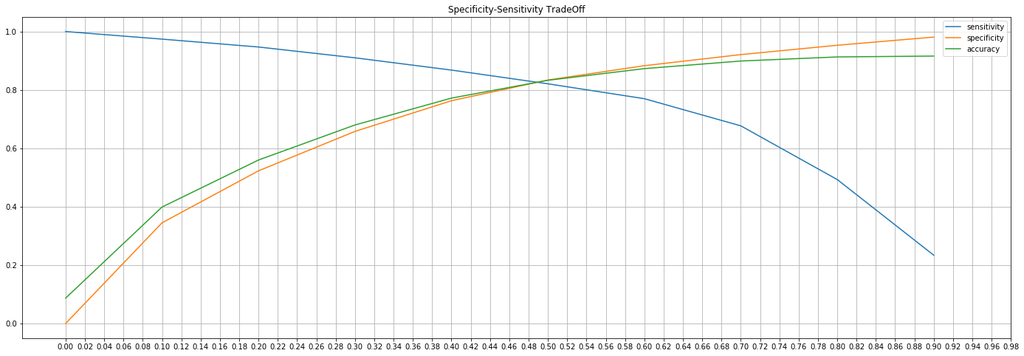

```python
metrics_df.plot(kind='line', figsize=(24,8), grid=True, xticks=np.arange(0,1,0.02),
                title='Specificity-Sensitivity TradeOff');
```

#### Baseline Performance at Optimum Cutoff

```python
optimum_cutoff = 0.49
y_train_pred_final = y_train_pred.map(lambda x : 1 if x > optimum_cutoff else 0)
y_test_pred_final = y_test_pred.map(lambda x : 1 if x > optimum_cutoff else 0)

train_matrix = confusion_matrix(y_train, y_train_pred_final)
print('Confusion Matrix for train:\n', train_matrix)
test_matrix = confusion_matrix(y_test, y_test_pred_final)
print('\nConfusion Matrix for test: \n', test_matrix)
```

[output not shown]

```python
print('Train Performance: \n')
model_metrics(train_matrix)

print('\n\nTest Performance : \n')
model_metrics(test_matrix)
```

[output not shown]

```python
# ROC_AUC score
from sklearn.metrics import roc_auc_score
print('ROC AUC score for Train : ',round(roc_auc_score(y_train, y_train_pred),3), '\n' )
print('ROC AUC score for Test : ',round(roc_auc_score(y_test, y_test_pred),3) )
```

```
ROC AUC score for Train :  0.891

ROC AUC score for Test :  0.838
```

#### Feature Selection using RFE

```python
from sklearn.feature_selection import RFE
from sklearn.linear_model import LogisticRegression
lr = LogisticRegression(random_state=100 , class_weight='balanced')
rfe = RFE(lr, 15)
results = rfe.fit(X_train,y_train)
results.support_
```

```
array([False, False, False, False, False, False, False, False, False,
       False, False, False, False, False, False, False, False, False,
       False, False, False, False, False, False, False, False, False,
       False, False, False, False, False, False, False, False,  True,
       False, False, False, False, False, False, False, False, False,
       False, False, False, False, False, False, False, False, False,
       False, False,  True, False, False, False, False, False, False,
       False, False, False, False,  True,  True, False, False, False,
       False, False, False, False, False, False, False, False, False,
        True, False,  True, False, False, False, False, False, False,
       False, False, False, False, False, False, False, False, False,
        True, False, False,  True, False, False,  True, False, False,
       False,  True, False, False,  True, False, False, False, False,
        True, False, False,  True, False, False, False, False, False,
       False, False, False,  True, False, False, False, False, False,
        True, False, False, False, False, False])
```

```python
# DataFrame with features supported by RFE
rfe_support = pd.DataFrame({'Column' : X.columns.to_list(), 'Rank' : rfe.ranking_,
                                      'Support' :  rfe.support_}).sort_values(by=
                                       'Rank', ascending=True)
rfe_support
```

|  | Column | Rank | Support |
| --- | --- | --- | --- |
| 99 | sachet_3g_6_0 | 1 | True |
| 120 | sachet_2g_7_0 | 1 | True |
| 102 | monthly_2g_7_0 | 1 | True |
| 135 | sachet_2g_8_0 | 1 | True |
| 81 | total_rech_num_6 | 1 | True |
| 129 | monthly_3g_8_0 | 1 | True |
| 105 | monthly_2g_8_0 | 1 | True |
| 83 | total_rech_num_8 | 1 | True |
| 117 | monthly_2g_6_0 | 1 | True |
| 68 | std_ic_t2f_mou_8 | 1 | True |
| 67 | std_ic_t2f_mou_7 | 1 | True |
| 112 | sachet_2g_6_0 | 1 | True |
| 109 | monthly_3g_7_0 | 1 | True |
| 56 | loc_ic_t2f_mou_8 | 1 | True |
| 35 | std_og_t2f_mou_8 | 1 | True |
| 40 | isd_og_mou_7 | 2 | False |
| 53 | loc_ic_t2m_mou_8 | 3 | False |
| 19 | loc_og_t2f_mou_7 | 4 | False |
| 62 | std_ic_t2t_mou_8 | 5 | False |
| 61 | std_ic_t2t_mou_7 | 6 | False |
| 107 | sachet_3g_8_0 | 7 | False |
| 41 | isd_og_mou_8 | 8 | False |
| 89 | last_day_rch_amt_8 | 9 | False |
| 11 | roam_og_mou_8 | 10 | False |
| 132 | monthly_3g_6_0 | 11 | False |
| 39 | isd_og_mou_6 | 12 | False |
| 79 | ic_others_7 | 13 | False |
| 50 | loc_ic_t2t_mou_8 | 14 | False |
| 7 | roam_ic_mou_7 | 15 | False |
| 58 | loc_ic_mou_7 | 16 | False |

[output cut: 111 more lines]

```python
# RFE Selected columns
rfe_selected_columns = rfe_support.loc[rfe_support['Rank'] == 1,'Column'].to_list()
rfe_selected_columns
```

```
['sachet_3g_6_0',
 'sachet_2g_7_0',
 'monthly_2g_7_0',
 'sachet_2g_8_0',
 'total_rech_num_6',
 'monthly_3g_8_0',
 'monthly_2g_8_0',
 'total_rech_num_8',
 'monthly_2g_6_0',
 'std_ic_t2f_mou_8',
 'std_ic_t2f_mou_7',
 'sachet_2g_6_0',
 'monthly_3g_7_0',
 'loc_ic_t2f_mou_8',
 'std_og_t2f_mou_8']
```

#### Logistic Regression with RFE Selected Columns

#### Model I

```python
# Logistic Regression Model with RFE columns
import statsmodels.api as sm

# Note that the SMOTE resampled Train set is used with statsmodels.api.GLM since it doesnot support class_weight
logr = sm.GLM(y_train_resampled,(sm.add_constant(X_train_resampled[rfe_selected_columns])), family = sm.families.Binomial())
logr_fit = logr.fit()
logr_fit.summary()
```

Generalized Linear Model Regression Results

| Dep. Variable: | Churn | No. Observations: | 38374 |
| --- | --- | --- | --- |
| Model: | GLM | Df Residuals: | 38358 |
| Model Family: | Binomial | Df Model: | 15 |
| Link Function: | logit | Scale: | 1.0000 |
| Method: | IRLS | Log-Likelihood: | -19485. |
| Date: | Mon, 30 Nov 2020 | Deviance: | 38969. |
| Time: | 21:57:09 | Pearson chi2: | 2.80e+05 |
| No. Iterations: | 7 |  |  |
| Covariance Type: | nonrobust |  |  |

|  | coef | std err | z | P>\|z\| | [0.025 | 0.975] |
| --- | --- | --- | --- | --- | --- | --- |
| const | -0.2334 | 0.015 | -15.657 | 0.000 | -0.263 | -0.204 |
| sachet_3g_6_0 | -0.0396 | 0.014 | -2.886 | 0.004 | -0.066 | -0.013 |
| sachet_2g_7_0 | -0.0980 | 0.016 | -6.201 | 0.000 | -0.129 | -0.067 |
| monthly_2g_7_0 | 0.0096 | 0.016 | 0.594 | 0.552 | -0.022 | 0.041 |
| sachet_2g_8_0 | 0.0489 | 0.015 | 3.359 | 0.001 | 0.020 | 0.077 |
| total_rech_num_6 | 0.6047 | 0.017 | 35.547 | 0.000 | 0.571 | 0.638 |
| monthly_3g_8_0 | 0.3993 | 0.017 | 23.439 | 0.000 | 0.366 | 0.433 |
| monthly_2g_8_0 | 0.3697 | 0.018 | 21.100 | 0.000 | 0.335 | 0.404 |
| total_rech_num_8 | -1.2013 | 0.019 | -62.378 | 0.000 | -1.239 | -1.164 |
| monthly_2g_6_0 | -0.0194 | 0.015 | -1.262 | 0.207 | -0.050 | 0.011 |
| std_ic_t2f_mou_8 | -0.3364 | 0.026 | -12.792 | 0.000 | -0.388 | -0.285 |
| std_ic_t2f_mou_7 | 0.1535 | 0.019 | 8.148 | 0.000 | 0.117 | 0.190 |
| sachet_2g_6_0 | -0.1117 | 0.016 | -6.847 | 0.000 | -0.144 | -0.080 |
| monthly_3g_7_0 | -0.2094 | 0.017 | -12.602 | 0.000 | -0.242 | -0.177 |
| loc_ic_t2f_mou_8 | -1.2743 | 0.038 | -33.599 | 0.000 | -1.349 | -1.200 |
| std_og_t2f_mou_8 | -0.2476 | 0.021 | -11.621 | 0.000 | -0.289 | -0.206 |

#### Logistic Regression with Manual Feature Elimination

```python
# Using P-value and vif for manual feature elimination

from statsmodels.stats.outliers_influence import variance_inflation_factor
def vif(X_train_resampled, logr_fit, selected_columns) :
    vif = pd.DataFrame()
    vif['Features'] = rfe_selected_columns
    vif['VIF'] = [variance_inflation_factor(X_train_resampled[selected_columns].values, i) for i in range(X_train_resampled[selected_columns].shape[1])]
    vif['VIF'] = round(vif['VIF'], 2)
    vif = vif.set_index('Features')
    vif['P-value'] = round(logr_fit.pvalues,4)
    vif = vif.sort_values(by = ["VIF",'P-value'], ascending = [False,False])
    return vif

vif(X_train_resampled, logr_fit, rfe_selected_columns)
```

| Features | VIF | P-value |
| --- | --- | --- |
| std_ic_t2f_mou_8 | 1.66 | 0.0000 |
| sachet_2g_6_0 | 1.64 | 0.0000 |
| sachet_2g_7_0 | 1.57 | 0.0000 |
| std_ic_t2f_mou_7 | 1.56 | 0.0000 |
| monthly_2g_7_0 | 1.54 | 0.5524 |
| monthly_3g_7_0 | 1.54 | 0.0000 |
| monthly_3g_8_0 | 1.52 | 0.0000 |
| monthly_2g_8_0 | 1.43 | 0.0000 |
| monthly_2g_6_0 | 1.38 | 0.2069 |
| sachet_2g_8_0 | 1.36 | 0.0008 |
| total_rech_num_6 | 1.27 | 0.0000 |
| total_rech_num_8 | 1.25 | 0.0000 |
| std_og_t2f_mou_8 | 1.20 | 0.0000 |
| sachet_3g_6_0 | 1.12 | 0.0039 |
| loc_ic_t2f_mou_8 | 1.09 | 0.0000 |

- 'monthly_2g_7_0' has the very p-value. Hence, this feature could be eliminated

```python
selected_columns = rfe_selected_columns
selected_columns.remove('monthly_2g_7_0')
selected_columns
```

```
['sachet_3g_6_0',
 'sachet_2g_7_0',
 'sachet_2g_8_0',
 'total_rech_num_6',
 'monthly_3g_8_0',
 'monthly_2g_8_0',
 'total_rech_num_8',
 'monthly_2g_6_0',
 'std_ic_t2f_mou_8',
 'std_ic_t2f_mou_7',
 'sachet_2g_6_0',
 'monthly_3g_7_0',
 'loc_ic_t2f_mou_8',
 'std_og_t2f_mou_8']
```

#### Model II

```python
logr2 = sm.GLM(y_train_resampled,(sm.add_constant(X_train_resampled[selected_columns])), family = sm.families.Binomial())
logr2_fit = logr2.fit()
logr2_fit.summary()
```

Generalized Linear Model Regression Results

| Dep. Variable: | Churn | No. Observations: | 38374 |
| --- | --- | --- | --- |
| Model: | GLM | Df Residuals: | 38359 |
| Model Family: | Binomial | Df Model: | 14 |
| Link Function: | logit | Scale: | 1.0000 |
| Method: | IRLS | Log-Likelihood: | -19485. |
| Date: | Mon, 30 Nov 2020 | Deviance: | 38970. |
| Time: | 21:57:09 | Pearson chi2: | 2.80e+05 |
| No. Iterations: | 7 |  |  |
| Covariance Type: | nonrobust |  |  |

|  | coef | std err | z | P>\|z\| | [0.025 | 0.975] |
| --- | --- | --- | --- | --- | --- | --- |
| const | -0.2335 | 0.015 | -15.662 | 0.000 | -0.263 | -0.204 |
| sachet_3g_6_0 | -0.0395 | 0.014 | -2.881 | 0.004 | -0.066 | -0.013 |
| sachet_2g_7_0 | -0.0982 | 0.016 | -6.217 | 0.000 | -0.129 | -0.067 |
| sachet_2g_8_0 | 0.0491 | 0.015 | 3.372 | 0.001 | 0.021 | 0.078 |
| total_rech_num_6 | 0.6049 | 0.017 | 35.566 | 0.000 | 0.572 | 0.638 |
| monthly_3g_8_0 | 0.4000 | 0.017 | 23.521 | 0.000 | 0.367 | 0.433 |
| monthly_2g_8_0 | 0.3733 | 0.016 | 22.696 | 0.000 | 0.341 | 0.406 |
| total_rech_num_8 | -1.2012 | 0.019 | -62.375 | 0.000 | -1.239 | -1.163 |
| monthly_2g_6_0 | -0.0163 | 0.014 | -1.128 | 0.259 | -0.045 | 0.012 |
| std_ic_t2f_mou_8 | -0.3361 | 0.026 | -12.784 | 0.000 | -0.388 | -0.285 |
| std_ic_t2f_mou_7 | 0.1532 | 0.019 | 8.136 | 0.000 | 0.116 | 0.190 |
| sachet_2g_6_0 | -0.1111 | 0.016 | -6.823 | 0.000 | -0.143 | -0.079 |
| monthly_3g_7_0 | -0.2098 | 0.017 | -12.633 | 0.000 | -0.242 | -0.177 |
| loc_ic_t2f_mou_8 | -1.2749 | 0.038 | -33.622 | 0.000 | -1.349 | -1.201 |
| std_og_t2f_mou_8 | -0.2476 | 0.021 | -11.620 | 0.000 | -0.289 | -0.206 |

```python
# vif and p-values
vif(X_train_resampled, logr2_fit, selected_columns)
```

| Features | VIF | P-value |
| --- | --- | --- |
| std_ic_t2f_mou_8 | 1.66 | 0.0000 |
| sachet_2g_6_0 | 1.63 | 0.0000 |
| sachet_2g_7_0 | 1.57 | 0.0000 |
| std_ic_t2f_mou_7 | 1.56 | 0.0000 |
| monthly_3g_7_0 | 1.54 | 0.0000 |
| monthly_3g_8_0 | 1.52 | 0.0000 |
| sachet_2g_8_0 | 1.36 | 0.0007 |
| total_rech_num_6 | 1.27 | 0.0000 |
| total_rech_num_8 | 1.25 | 0.0000 |
| monthly_2g_8_0 | 1.23 | 0.0000 |
| monthly_2g_6_0 | 1.21 | 0.2595 |
| std_og_t2f_mou_8 | 1.20 | 0.0000 |
| sachet_3g_6_0 | 1.12 | 0.0040 |
| loc_ic_t2f_mou_8 | 1.09 | 0.0000 |

- 'monthly_2g_6_0' has very high p-value. Hence, this feature could be eliminated

```python
selected_columns.remove('monthly_2g_6_0')
selected_columns
```

```
['sachet_3g_6_0',
 'sachet_2g_7_0',
 'sachet_2g_8_0',
 'total_rech_num_6',
 'monthly_3g_8_0',
 'monthly_2g_8_0',
 'total_rech_num_8',
 'std_ic_t2f_mou_8',
 'std_ic_t2f_mou_7',
 'sachet_2g_6_0',
 'monthly_3g_7_0',
 'loc_ic_t2f_mou_8',
 'std_og_t2f_mou_8']
```

#### Model III

```python
logr3 = sm.GLM(y_train_resampled,(sm.add_constant(X_train_resampled[selected_columns])), family = sm.families.Binomial())
logr3_fit = logr3.fit()
logr3_fit.summary()
```

Generalized Linear Model Regression Results

| Dep. Variable: | Churn | No. Observations: | 38374 |
| --- | --- | --- | --- |
| Model: | GLM | Df Residuals: | 38360 |
| Model Family: | Binomial | Df Model: | 13 |
| Link Function: | logit | Scale: | 1.0000 |
| Method: | IRLS | Log-Likelihood: | -19486. |
| Date: | Mon, 30 Nov 2020 | Deviance: | 38971. |
| Time: | 21:57:10 | Pearson chi2: | 2.79e+05 |
| No. Iterations: | 7 |  |  |
| Covariance Type: | nonrobust |  |  |

|  | coef | std err | z | P>\|z\| | [0.025 | 0.975] |
| --- | --- | --- | --- | --- | --- | --- |
| const | -0.2336 | 0.015 | -15.667 | 0.000 | -0.263 | -0.204 |
| sachet_3g_6_0 | -0.0399 | 0.014 | -2.916 | 0.004 | -0.067 | -0.013 |
| sachet_2g_7_0 | -0.0987 | 0.016 | -6.249 | 0.000 | -0.130 | -0.068 |
| sachet_2g_8_0 | 0.0488 | 0.015 | 3.354 | 0.001 | 0.020 | 0.077 |
| total_rech_num_6 | 0.6053 | 0.017 | 35.581 | 0.000 | 0.572 | 0.639 |
| monthly_3g_8_0 | 0.3994 | 0.017 | 23.494 | 0.000 | 0.366 | 0.433 |
| monthly_2g_8_0 | 0.3666 | 0.015 | 23.953 | 0.000 | 0.337 | 0.397 |
| total_rech_num_8 | -1.2033 | 0.019 | -62.720 | 0.000 | -1.241 | -1.166 |
| std_ic_t2f_mou_8 | -0.3363 | 0.026 | -12.788 | 0.000 | -0.388 | -0.285 |
| std_ic_t2f_mou_7 | 0.1532 | 0.019 | 8.137 | 0.000 | 0.116 | 0.190 |
| sachet_2g_6_0 | -0.1108 | 0.016 | -6.810 | 0.000 | -0.143 | -0.079 |
| monthly_3g_7_0 | -0.2099 | 0.017 | -12.640 | 0.000 | -0.242 | -0.177 |
| loc_ic_t2f_mou_8 | -1.2736 | 0.038 | -33.621 | 0.000 | -1.348 | -1.199 |
| std_og_t2f_mou_8 | -0.2474 | 0.021 | -11.617 | 0.000 | -0.289 | -0.206 |

```python
# vif and p-values
vif(X_train_resampled, logr3_fit, selected_columns)
```

| Features | VIF | P-value |
| --- | --- | --- |
| std_ic_t2f_mou_8 | 1.66 | 0.0000 |
| sachet_2g_6_0 | 1.63 | 0.0000 |
| sachet_2g_7_0 | 1.57 | 0.0000 |
| std_ic_t2f_mou_7 | 1.56 | 0.0000 |
| monthly_3g_7_0 | 1.54 | 0.0000 |
| monthly_3g_8_0 | 1.52 | 0.0000 |
| sachet_2g_8_0 | 1.36 | 0.0008 |
| total_rech_num_6 | 1.27 | 0.0000 |
| total_rech_num_8 | 1.24 | 0.0000 |
| std_og_t2f_mou_8 | 1.20 | 0.0000 |
| sachet_3g_6_0 | 1.12 | 0.0035 |
| loc_ic_t2f_mou_8 | 1.09 | 0.0000 |
| monthly_2g_8_0 | 1.03 | 0.0000 |

- All features have low p-values(<0.05) and VIF (<5)
- This model could be used as the interpretable logistic regression model.

### Final Logistic Regression Model with RFE and Manual Elimination

```python
logr3_fit.summary()
```

Generalized Linear Model Regression Results

| Dep. Variable: | Churn | No. Observations: | 38374 |
| --- | --- | --- | --- |
| Model: | GLM | Df Residuals: | 38360 |
| Model Family: | Binomial | Df Model: | 13 |
| Link Function: | logit | Scale: | 1.0000 |
| Method: | IRLS | Log-Likelihood: | -19486. |
| Date: | Mon, 30 Nov 2020 | Deviance: | 38971. |
| Time: | 21:57:10 | Pearson chi2: | 2.79e+05 |
| No. Iterations: | 7 |  |  |
| Covariance Type: | nonrobust |  |  |

|  | coef | std err | z | P>\|z\| | [0.025 | 0.975] |
| --- | --- | --- | --- | --- | --- | --- |
| const | -0.2336 | 0.015 | -15.667 | 0.000 | -0.263 | -0.204 |
| sachet_3g_6_0 | -0.0399 | 0.014 | -2.916 | 0.004 | -0.067 | -0.013 |
| sachet_2g_7_0 | -0.0987 | 0.016 | -6.249 | 0.000 | -0.130 | -0.068 |
| sachet_2g_8_0 | 0.0488 | 0.015 | 3.354 | 0.001 | 0.020 | 0.077 |
| total_rech_num_6 | 0.6053 | 0.017 | 35.581 | 0.000 | 0.572 | 0.639 |
| monthly_3g_8_0 | 0.3994 | 0.017 | 23.494 | 0.000 | 0.366 | 0.433 |
| monthly_2g_8_0 | 0.3666 | 0.015 | 23.953 | 0.000 | 0.337 | 0.397 |
| total_rech_num_8 | -1.2033 | 0.019 | -62.720 | 0.000 | -1.241 | -1.166 |
| std_ic_t2f_mou_8 | -0.3363 | 0.026 | -12.788 | 0.000 | -0.388 | -0.285 |
| std_ic_t2f_mou_7 | 0.1532 | 0.019 | 8.137 | 0.000 | 0.116 | 0.190 |
| sachet_2g_6_0 | -0.1108 | 0.016 | -6.810 | 0.000 | -0.143 | -0.079 |
| monthly_3g_7_0 | -0.2099 | 0.017 | -12.640 | 0.000 | -0.242 | -0.177 |
| loc_ic_t2f_mou_8 | -1.2736 | 0.038 | -33.621 | 0.000 | -1.348 | -1.199 |
| std_og_t2f_mou_8 | -0.2474 | 0.021 | -11.617 | 0.000 | -0.289 | -0.206 |

```python
selected_columns
```

```
['sachet_3g_6_0',
 'sachet_2g_7_0',
 'sachet_2g_8_0',
 'total_rech_num_6',
 'monthly_3g_8_0',
 'monthly_2g_8_0',
 'total_rech_num_8',
 'std_ic_t2f_mou_8',
 'std_ic_t2f_mou_7',
 'sachet_2g_6_0',
 'monthly_3g_7_0',
 'loc_ic_t2f_mou_8',
 'std_og_t2f_mou_8']
```

```python
# Prediction
y_train_pred_lr = logr3_fit.predict(sm.add_constant(X_train_resampled[selected_columns]))
y_train_pred_lr.head()
```

```
0    0.118916
1    0.343873
2    0.381230
3    0.015277
4    0.001595
dtype: float64
```

```python
y_test_pred_lr = logr3_fit.predict(sm.add_constant(X_test[selected_columns]))
y_test_pred_lr.head()
```

```
mobile_number
7002242818    0.013556
7000517161    0.903162
7002162382    0.247123
7002152271    0.330787
7002058655    0.056105
dtype: float64
```

#### Performance

**Finding Optimum Probability Cutoff**

```python
# Specificity / Sensitivity Tradeoff

# Classification at probability thresholds between 0 and 1
y_train_pred_thres = pd.DataFrame(index=X_train_resampled.index)
thresholds = [float(x)/10 for x in range(10)]

def thresholder(x, thresh) :
    if x > thresh :
        return 1
    else :
        return 0


for i in thresholds:
    y_train_pred_thres[i]= y_train_pred_lr.map(lambda x : thresholder(x,i))
y_train_pred_thres.head()
```

|  | 0.0 | 0.1 | 0.2 | 0.3 | 0.4 | 0.5 | 0.6 | 0.7 | 0.8 | 0.9 |
| --- | --- | --- | --- | --- | --- | --- | --- | --- | --- | --- |
| 0 | 1 | 1 | 0 | 0 | 0 | 0 | 0 | 0 | 0 | 0 |
| 1 | 1 | 1 | 1 | 1 | 0 | 0 | 0 | 0 | 0 | 0 |
| 2 | 1 | 1 | 1 | 1 | 0 | 0 | 0 | 0 | 0 | 0 |
| 3 | 1 | 0 | 0 | 0 | 0 | 0 | 0 | 0 | 0 | 0 |
| 4 | 1 | 0 | 0 | 0 | 0 | 0 | 0 | 0 | 0 | 0 |

```python
# DataFrame for Performance metrics at each threshold

logr_metrics_df = pd.DataFrame(columns=['sensitivity', 'specificity', 'accuracy'])
for thres,column in zip(thresholds,y_train_pred_thres.columns.to_list()) :
    confusion = confusion_matrix(y_train_resampled, y_train_pred_thres.loc[:,column])
    sensitivity,specificity,accuracy = model_metrics_thres(confusion)
    logr_metrics_df =  logr_metrics_df.append({
        'sensitivity' :sensitivity,
        'specificity' : specificity,
        'accuracy' : accuracy
    }, ignore_index = True)

logr_metrics_df.index = thresholds
logr_metrics_df
```

|  | sensitivity | specificity | accuracy |
| --- | --- | --- | --- |
| 0.0 | 1.000 | 0.000 | 0.500 |
| 0.1 | 0.976 | 0.224 | 0.600 |
| 0.2 | 0.947 | 0.351 | 0.649 |
| 0.3 | 0.916 | 0.472 | 0.694 |
| 0.4 | 0.864 | 0.598 | 0.731 |
| 0.5 | 0.794 | 0.722 | 0.758 |
| 0.6 | 0.703 | 0.841 | 0.772 |
| 0.7 | 0.550 | 0.930 | 0.740 |
| 0.8 | 0.310 | 0.975 | 0.642 |
| 0.9 | 0.095 | 0.994 | 0.544 |

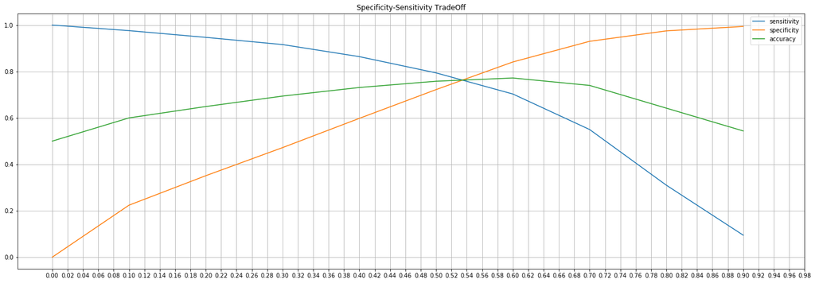

```python
logr_metrics_df.plot(kind='line', figsize=(24,8), grid=True, xticks=np.arange(0,1,0.02),
                title='Specificity-Sensitivity TradeOff');
```

- The optimum probability cutoff for Logistic regression model is 0.53

```python
optimum_cutoff = 0.53
y_train_pred_lr_final = y_train_pred_lr.map(lambda x : 1 if x > optimum_cutoff else 0)
y_test_pred_lr_final = y_test_pred_lr.map(lambda x : 1 if x > optimum_cutoff else 0)

train_matrix = confusion_matrix(y_train_resampled, y_train_pred_lr_final)
print('Confusion Matrix for train:\n', train_matrix)
test_matrix = confusion_matrix(y_test, y_test_pred_lr_final)
print('\nConfusion Matrix for test: \n', test_matrix)
```

```
Confusion Matrix for train:
 [[14531  4656]
 [ 4411 14776]]

Confusion Matrix for test:
 [[6313 1918]
 [ 191  582]]
```

```python
print('Train Performance: \n')
model_metrics(train_matrix)

print('\n\nTest Performance : \n')
model_metrics(test_matrix)
```

```
Train Performance:

Accuracy : 0.764
Sensitivity / True Positive Rate / Recall : 0.77
Specificity / True Negative Rate :  0.757
Precision / Positive Predictive Value : 0.76
F1-score : 0.765


Test Performance :

Accuracy : 0.766
Sensitivity / True Positive Rate / Recall : 0.753
Specificity / True Negative Rate :  0.767
Precision / Positive Predictive Value : 0.233
F1-score : 0.356
```

```python
# ROC_AUC score
print('ROC AUC score for Train : ',round(roc_auc_score(y_train_resampled, y_train_pred_lr),3), '\n' )
print('ROC AUC score for Test : ',round(roc_auc_score(y_test, y_test_pred_lr),3) )
```

```
ROC AUC score for Train :  0.843

ROC AUC score for Test :  0.828
```

## Model 1 : Logistic Regression (Interpretable Model Summary)

```python
lr_summary_html = logr3_fit.summary().tables[1].as_html()
lr_results = pd.read_html(lr_summary_html, header=0, index_col=0)[0]
coef_column = lr_results.columns[0]
print('Most important predictors of Churn , in order of importance and their coefficients are as follows : \n')
lr_results.sort_values(by=coef_column, key=lambda x: abs(x), ascending=False)['coef']
```

```
Most important predictors of Churn , in order of importance and their coefficients are as follows :
```

```
loc_ic_t2f_mou_8   -1.2736
total_rech_num_8   -1.2033
total_rech_num_6    0.6053
monthly_3g_8_0      0.3994
monthly_2g_8_0      0.3666
std_ic_t2f_mou_8   -0.3363
std_og_t2f_mou_8   -0.2474
const              -0.2336
monthly_3g_7_0     -0.2099
std_ic_t2f_mou_7    0.1532
sachet_2g_6_0      -0.1108
sachet_2g_7_0      -0.0987
sachet_2g_8_0       0.0488
sachet_3g_6_0      -0.0399
Name: coef, dtype: float64
```

- The above model could be used as the interpretable model for predicting telecom churn.

## PCA

```python
from sklearn.decomposition import PCA
pca = PCA(random_state = 42)
pca.fit(X_train) # note that pca is fit on original train set instead of resampled train set.
pca.components_
```

```
array([[ 1.64887430e-01,  1.93987506e-01,  1.67239205e-01, ...,
         1.43967238e-06, -1.55704675e-06, -1.88892194e-06],
       [ 6.48591961e-02,  9.55966684e-02,  1.20775174e-01, ...,
        -2.12841595e-06, -1.47944145e-06, -3.90881587e-07],
       [ 2.38415388e-01,  2.73645507e-01,  2.38436263e-01, ...,
        -1.25598531e-06, -4.37900299e-07,  6.19889336e-07],
       ...,
       [ 1.68015588e-06,  1.93600851e-06, -1.82065762e-06, ...,
         4.25473944e-03,  2.56738368e-03,  3.51118176e-03],
       [ 0.00000000e+00, -1.11533905e-16,  1.57807487e-16, ...,
         1.73764144e-15,  6.22907679e-16,  1.45339158e-16],
       [ 0.00000000e+00,  4.98537742e-16, -6.02718139e-16, ...,
         1.27514583e-15,  1.25772226e-15,  3.41773342e-16]])
```

```python
pca.explained_variance_ratio_
```

```
array([2.72067612e-01, 1.62438240e-01, 1.20827535e-01, 1.06070063e-01,
       9.11349433e-02, 4.77504400e-02, 2.63978655e-02, 2.56843982e-02,
       1.91789343e-02, 1.68045932e-02, 1.55523468e-02, 1.31676589e-02,
       1.04552128e-02, 7.72970448e-03, 7.22746863e-03, 6.14494838e-03,
       5.62073089e-03, 5.44579273e-03, 4.59009989e-03, 4.38488162e-03,
       3.46703626e-03, 3.27941490e-03, 2.78099200e-03, 2.13444270e-03,
       2.07542043e-03, 1.89794720e-03, 1.41383936e-03, 1.30240760e-03,
       1.15369576e-03, 1.05262500e-03, 9.64293417e-04, 9.16686049e-04,
       8.84067044e-04, 7.62966236e-04, 6.61794767e-04, 5.69667265e-04,
       5.12585166e-04, 5.04441248e-04, 4.82396680e-04, 4.46889495e-04,
       4.36441254e-04, 4.10389488e-04, 3.51844810e-04, 3.12626195e-04,
       2.51673027e-04, 2.34723896e-04, 1.96950034e-04, 1.71296745e-04,
       1.59882693e-04, 1.48330353e-04, 1.45919483e-04, 1.08583729e-04,
       1.04038518e-04, 8.90621848e-05, 8.53009223e-05, 7.60704088e-05,
       7.57150133e-05, 6.16615717e-05, 6.07777411e-05, 5.70517541e-05,
       5.36161089e-05, 5.28495367e-05, 5.14887086e-05, 4.73768570e-05,
       4.71283394e-05, 4.11523975e-05, 4.10392906e-05, 2.86090257e-05,
       2.19793282e-05, 1.58203581e-05, 1.50969788e-05, 1.42865579e-05,
       1.34537530e-05, 1.33026062e-05, 1.10239870e-05, 8.27539516e-06,
       7.55845974e-06, 6.45372276e-06, 6.22570067e-06, 3.42288900e-06,
       3.20804681e-06, 3.09270863e-06, 2.86608967e-06, 2.44898003e-06,
       2.08230568e-06, 1.85144734e-06, 1.64714248e-06, 1.45630245e-06,
       1.35265729e-06, 1.05472047e-06, 9.89133015e-07, 8.65864423e-07,
       7.45065121e-07, 3.66727807e-07, 6.49277820e-08, 6.13357428e-08,
       4.35995018e-08, 2.28152900e-08, 2.00441141e-08, 1.84235145e-08,
       1.66102335e-08, 1.47870989e-08, 1.23390691e-08, 1.12094165e-08,
       1.09702422e-08, 9.51924270e-09, 8.61596309e-09, 7.38051070e-09,
       7.15370081e-09, 6.29095319e-09, 5.00739371e-09, 4.68791660e-09,
       4.23376173e-09, 4.04558169e-09, 3.75847771e-09, 3.71213838e-09,
       3.32806929e-09, 3.23527525e-09, 3.12734302e-09, 2.82062311e-09,
       2.72602311e-09, 2.66103741e-09, 2.46562734e-09, 2.20243536e-09,
       2.15044476e-09, 1.59498492e-09, 1.47087974e-09, 1.06159357e-09,
       9.33938436e-10, 8.10080735e-10, 8.04656028e-10, 6.12994365e-10,
       4.82074297e-10, 4.02577318e-10, 3.58059984e-10, 3.28374076e-10,
       3.03687605e-10, 7.12091816e-11, 6.13978255e-11, 1.04375208e-33,
       1.04375208e-33])
```

#### Scree Plot

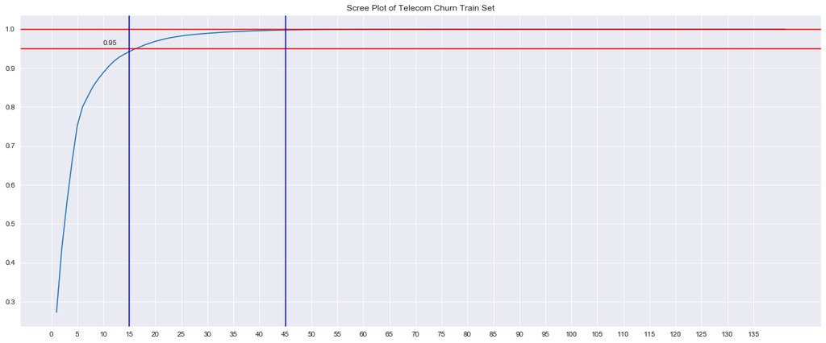

```python
var_cum = np.cumsum(pca.explained_variance_ratio_)
plt.figure(figsize=(20,8))
sns.set_style('darkgrid')
sns.lineplot(np.arange(1,len(var_cum) + 1), var_cum)
plt.xticks(np.arange(0,140,5))
plt.axhline(0.95,color='r')
plt.axhline(1.0,color='r')
plt.axvline(15,color='b')
plt.axvline(45,color='b')
plt.text(10,0.96,'0.95')

plt.title('Scree Plot of Telecom Churn Train Set');
```

```python
# Perform PCA using the first 45 components
pca_final = PCA(n_components=45, random_state=42)
transformed_data = pca_final.fit_transform(X_train)
X_train_pca = pd.DataFrame(transformed_data, columns=["PC_"+str(x) for x in range(1,46)], index = X_train.index)
data_train_pca = pd.concat([X_train_pca, y_train], axis=1)

data_train_pca.head()
```

| mobile_number | PC_1 | PC_2 | PC_3 | PC_4 | PC_5 | PC_6 | PC_7 | PC_8 | PC_9 | PC_10 | PC_11 | PC_12 | PC_13 | PC_14 | PC_15 | PC_16 | PC_17 | PC_18 | PC_19 | PC_20 | PC_21 | PC_22 | PC_23 | PC_24 | PC_25 | PC_26 | PC_27 | PC_28 | PC_29 | … |
| --- | --- | --- | --- | --- | --- | --- | --- | --- | --- | --- | --- | --- | --- | --- | --- | --- | --- | --- | --- | --- | --- | --- | --- | --- | --- | --- | --- | --- | --- | --- |
| 7000166926 | -907.572208 | -342.923676 | 13.094442 | 58.813506 | -95.616159 | -1050.535219 | 254.648987 | -31.445039 | 305.140339 | -216.814250 | 95.825021 | 231.408291 | -111.002572 | -2.007256 | 444.977249 | 31.541681 | 573.831941 | -278.539708 | 30.768637 | -36.915195 | -0.293915 | -83.574447 | -13.960479 | -60.930941 | -53.208613 | 56.049658 | -17.776675 | -12.624526 | 14.149393 | … |
| 7001343085 | 573.898045 | -902.385767 | -424.839214 | -331.153508 | -148.987005 | -36.955710 | -134.445130 | 265.325388 | -92.070929 | -164.203586 | 25.105150 | -36.980621 | 164.785936 | -222.908959 | -12.573878 | -50.569424 | -44.767869 | -62.984835 | -18.100729 | -86.239469 | -115.399141 | -45.776518 | 16.345395 | -21.497140 | -10.541281 | -71.754047 | 29.230830 | -20.880178 | -0.690183 | … |
| 7001863283 | -1538.198366 | 514.032564 | 846.865497 | 57.032319 | -1126.228705 | -84.209511 | -44.422495 | -88.158881 | -58.411887 | 50.518811 | 3.052703 | -229.100202 | -109.215465 | -3.253782 | 7.045279 | -85.645393 | 54.536446 | -52.292779 | 20.978943 | -90.806167 | 96.348659 | 24.280381 | -52.425262 | 42.430049 | -40.627473 | -12.715890 | -4.331719 | -4.092290 | 50.339358 | … |
| 7002275981 | 486.830772 | -224.929803 | 1130.460535 | -496.189015 | 6.009139 | 81.106845 | -148.667431 | 170.280911 | -7.375197 | -99.556793 | -159.659135 | -14.186219 | -98.682096 | 213.233743 | -34.920639 | -17.212430 | 29.644778 | 4.941994 | 2.799763 | -49.580528 | -88.567855 | 16.809461 | -9.471018 | 4.383889 | 29.532189 | 38.211558 | 32.465761 | -5.316497 | -60.149577 | … |
| 7001086221 | -1420.949314 | 794.071749 | 99.221352 | 155.118564 | 145.349456 | 784.723580 | -10.947301 | 609.724272 | -172.482377 | -42.796400 | 59.174124 | -162.912577 | -112.219187 | -55.108445 | 17.303261 | -152.111164 | -611.929832 | 181.577435 | -211.358075 | -77.180329 | 116.282095 | 83.488753 | -26.254488 | 128.490023 | -69.085253 | 4.854304 | -128.278573 | 44.328867 | -6.470515 | … |

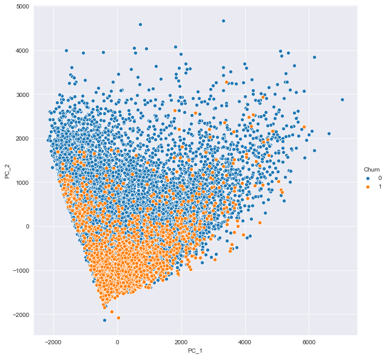

```python
## Plotting principal components
sns.pairplot(data=data_train_pca, x_vars=["PC_1"], y_vars=["PC_2"], hue = "Churn", size=8);
```

## Model 2 : PCA + Logistic Regression Model

```python
# X,y Split
y_train_pca = data_train_pca.pop('Churn')
X_train_pca = data_train_pca

# Transforming test set with pca ( 45 components)
X_test_pca = pca_final.transform(X_test)

# Logistic Regression
lr_pca = LogisticRegression(random_state=100, class_weight='balanced')
lr_pca.fit(X_train_pca,y_train_pca )
```

```
LogisticRegression(class_weight='balanced', random_state=100)
```

```python
# y_train predictions
y_train_pred_lr_pca = lr_pca.predict(X_train_pca)
y_train_pred_lr_pca[:5]
```

```
array([1, 0, 0, 0, 0])
```

```python
# Test Prediction
X_test_pca = pca_final.transform(X_test)
y_test_pred_lr_pca = lr_pca.predict(X_test_pca)
y_test_pred_lr_pca[:5]
```

```
array([1, 1, 1, 1, 1])
```

**Baseline Performance**

```python
train_matrix = confusion_matrix(y_train, y_train_pred_lr_pca)
test_matrix = confusion_matrix(y_test, y_test_pred_lr_pca)

print('Train Performance :\n')
model_metrics(train_matrix)

print('\nTest Performance :\n')
model_metrics(test_matrix)
```

```
Train Performance :

Accuracy : 0.645
Sensitivity / True Positive Rate / Recall : 0.905
Specificity / True Negative Rate :  0.62
Precision / Positive Predictive Value : 0.184
F1-score : 0.306

Test Performance :

Accuracy : 0.086
Sensitivity / True Positive Rate / Recall : 1.0
Specificity / True Negative Rate :  0.0
Precision / Positive Predictive Value : 0.086
F1-score : 0.158
```

#### Hyperparameter Tuning

```python
# Creating a Logistic regression model using pca transformed train set
from sklearn.pipeline import Pipeline
lr_pca = LogisticRegression(random_state=100, class_weight='balanced')
```

```python
from sklearn.model_selection import RandomizedSearchCV, GridSearchCV , StratifiedKFold
params = {
    'penalty' : ['l1','l2','none'],
    'C' : [0,1,2,3,4,5,10,50]
}
folds = StratifiedKFold(n_splits=4, shuffle=True, random_state=100)

search = GridSearchCV(cv=folds, estimator = lr_pca, param_grid=params,scoring='roc_auc', verbose=True, n_jobs=-1)
search.fit(X_train_pca, y_train_pca)
```

```
Fitting 4 folds for each of 24 candidates, totalling 96 fits
```

```
[Parallel(n_jobs=-1)]: Using backend LokyBackend with 4 concurrent workers.
[Parallel(n_jobs=-1)]: Done  42 tasks      | elapsed:    4.0s
[Parallel(n_jobs=-1)]: Done  96 out of  96 | elapsed:    6.9s finished
```

```
GridSearchCV(cv=StratifiedKFold(n_splits=4, random_state=100, shuffle=True),
             estimator=LogisticRegression(class_weight='balanced',
                                          random_state=100),
             n_jobs=-1,
             param_grid={'C': [0, 1, 2, 3, 4, 5, 10, 50],
                         'penalty': ['l1', 'l2', 'none']},
             scoring='roc_auc', verbose=True)
```

```python
# Optimum Hyperparameters
print('Best ROC-AUC score :', search.best_score_)
print('Best Parameters :', search.best_params_)
```

```
Best ROC-AUC score : 0.8763924253372933
Best Parameters : {'C': 0, 'penalty': 'none'}
```

```python
# Modelling using the best LR-PCA estimator
lr_pca_best = search.best_estimator_
lr_pca_best_fit = lr_pca_best.fit(X_train_pca, y_train_pca)

# Prediction on Train set
y_train_pred_lr_pca_best = lr_pca_best_fit.predict(X_train_pca)
y_train_pred_lr_pca_best[:5]
```

```
array([1, 1, 0, 0, 0])
```

```python
# Prediction on test set
y_test_pred_lr_pca_best = lr_pca_best_fit.predict(X_test_pca)
y_test_pred_lr_pca_best[:5]
```

```
array([1, 1, 1, 1, 1])
```

```python
## Model Performance after Hyper Parameter Tuning

train_matrix = confusion_matrix(y_train, y_train_pred_lr_pca_best)
test_matrix = confusion_matrix(y_test, y_test_pred_lr_pca_best)

print('Train Performance :\n')
model_metrics(train_matrix)

print('\nTest Performance :\n')
model_metrics(test_matrix)
```

```
Train Performance :

Accuracy : 0.627
Sensitivity / True Positive Rate / Recall : 0.918
Specificity / True Negative Rate :  0.599
Precision / Positive Predictive Value : 0.179
F1-score : 0.3

Test Performance :

Accuracy : 0.086
Sensitivity / True Positive Rate / Recall : 1.0
Specificity / True Negative Rate :  0.0
Precision / Positive Predictive Value : 0.086
F1-score : 0.158
```

## Model 3 : PCA + Random Forest

```python
from sklearn.ensemble import RandomForestClassifier

# creating a random forest classifier using pca output

pca_rf = RandomForestClassifier(random_state=42, class_weight= {0 : class_1/(class_0 + class_1) , 1 : class_0/(class_0 + class_1) } , oob_score=True, n_jobs=-1,verbose=1)
pca_rf
```

```
RandomForestClassifier(class_weight={0: 0.08640165272733331,
                                     1: 0.9135983472726666},
                       n_jobs=-1, oob_score=True, random_state=42, verbose=1)
```

```python
# Hyper parameter Tuning
params = {
    'n_estimators'  : [30,40,50,100],
    'max_depth' : [3,4,5,6,7],
    'min_samples_leaf' : [15,20,25,30]
}
folds = StratifiedKFold(n_splits=4, shuffle=True, random_state=42)
pca_rf_model_search = GridSearchCV(estimator=pca_rf, param_grid=params,
                                   cv=folds, scoring='roc_auc', verbose=True, n_jobs=-1 )

pca_rf_model_search.fit(X_train_pca, y_train)
```

```
Fitting 4 folds for each of 80 candidates, totalling 320 fits
```

```
[Parallel(n_jobs=-1)]: Using backend LokyBackend with 4 concurrent workers.
[Parallel(n_jobs=-1)]: Done  42 tasks      | elapsed:   23.2s
[Parallel(n_jobs=-1)]: Done 192 tasks      | elapsed:  2.7min
[Parallel(n_jobs=-1)]: Done 320 out of 320 | elapsed:  5.5min finished
[Parallel(n_jobs=-1)]: Using backend ThreadingBackend with 4 concurrent workers.
[Parallel(n_jobs=-1)]: Done  42 tasks      | elapsed:    1.2s
[Parallel(n_jobs=-1)]: Done 100 out of 100 | elapsed:    2.6s finished
```

```
GridSearchCV(cv=StratifiedKFold(n_splits=4, random_state=42, shuffle=True),
             estimator=RandomForestClassifier(class_weight={0: 0.08640165272733331,
                                                            1: 0.9135983472726666},
                                              n_jobs=-1, oob_score=True,
                                              random_state=42, verbose=1),
             n_jobs=-1,
             param_grid={'max_depth': [3, 4, 5, 6, 7],
                         'min_samples_leaf': [15, 20, 25, 30],
                         'n_estimators': [30, 40, 50, 100]},
             scoring='roc_auc', verbose=True)
```

```python
# Optimum Hyperparameters
print('Best ROC-AUC score :', pca_rf_model_search.best_score_)
print('Best Parameters :', pca_rf_model_search.best_params_)
```

```
Best ROC-AUC score : 0.8861621751601011
Best Parameters : {'max_depth': 7, 'min_samples_leaf': 20, 'n_estimators': 100}
```

```python
# Modelling using the best PCA-RandomForest Estimator
pca_rf_best = pca_rf_model_search.best_estimator_
pca_rf_best_fit = pca_rf_best.fit(X_train_pca, y_train)

# Prediction on Train set
y_train_pred_pca_rf_best = pca_rf_best_fit.predict(X_train_pca)
y_train_pred_pca_rf_best[:5]
```

```
[Parallel(n_jobs=-1)]: Using backend ThreadingBackend with 4 concurrent workers.
[Parallel(n_jobs=-1)]: Done  42 tasks      | elapsed:    1.1s
[Parallel(n_jobs=-1)]: Done 100 out of 100 | elapsed:    2.7s finished
[Parallel(n_jobs=4)]: Using backend ThreadingBackend with 4 concurrent workers.
[Parallel(n_jobs=4)]: Done  42 tasks      | elapsed:    0.0s
[Parallel(n_jobs=4)]: Done 100 out of 100 | elapsed:    0.1s finished
```

```
array([0, 0, 0, 0, 0])
```

```python
# Prediction on test set
y_test_pred_pca_rf_best = pca_rf_best_fit.predict(X_test_pca)
y_test_pred_pca_rf_best[:5]
```

```
[Parallel(n_jobs=4)]: Using backend ThreadingBackend with 4 concurrent workers.
[Parallel(n_jobs=4)]: Done  42 tasks      | elapsed:    0.1s
[Parallel(n_jobs=4)]: Done 100 out of 100 | elapsed:    0.1s finished
```

```
array([0, 0, 0, 0, 0])
```

```python
## PCA - RandomForest Model Performance - Hyper Parameter Tuned

train_matrix = confusion_matrix(y_train, y_train_pred_pca_rf_best)
test_matrix = confusion_matrix(y_test, y_test_pred_pca_rf_best)

print('Train Performance :\n')
model_metrics(train_matrix)

print('\nTest Performance :\n')
model_metrics(test_matrix)
```

[output not shown]

```python
## out of bag error
pca_rf_best_fit.oob_score_
```

```
0.8625220164707003
```

## Model 4 : PCA + XGBoost

```python
import xgboost as xgb
pca_xgb = xgb.XGBClassifier(random_state=42, scale_pos_weight= class_0/class_1 ,
                                    tree_method='hist',
                                   objective='binary:logistic',


                                  )  # scale_pos_weight takes care of class imbalance
pca_xgb.fit(X_train_pca, y_train)
```

```
XGBClassifier(base_score=0.5, booster='gbtree', colsample_bylevel=1,
              colsample_bynode=1, colsample_bytree=1, gamma=0, gpu_id=-1,
              importance_type='gain', interaction_constraints='',
              learning_rate=0.300000012, max_delta_step=0, max_depth=6,
              min_child_weight=1, missing=nan, monotone_constraints='()',
              n_estimators=100, n_jobs=0, num_parallel_tree=1, random_state=42,
              reg_alpha=0, reg_lambda=1, scale_pos_weight=10.573852680293097,
              subsample=1, tree_method='hist', validate_parameters=1,
              verbosity=None)
```

```python
print('Baseline Train AUC Score')
roc_auc_score(y_train, pca_xgb.predict_proba(X_train_pca)[:, 1])
```

```
Baseline Train AUC Score
```

```
0.9999996277241286
```

```python
print('Baseline Test AUC Score')
roc_auc_score(y_test, pca_xgb.predict_proba(X_test_pca)[:, 1])
```

```
Baseline Test AUC Score
```

```
0.46093390352284136
```

```python
## Hyper parameter Tuning
parameters = {
              'learning_rate': [0.1, 0.2, 0.3],
              'gamma' : [10,20,50],
              'max_depth': [2,3,4],
              'min_child_weight': [25,50],
              'n_estimators': [150,200,500]}
pca_xgb_search = GridSearchCV(estimator=pca_xgb , param_grid=parameters,scoring='roc_auc', cv=folds, n_jobs=-1, verbose=1)
pca_xgb_search.fit(X_train_pca, y_train)
```

```
Fitting 4 folds for each of 162 candidates, totalling 648 fits
```

```
[Parallel(n_jobs=-1)]: Using backend LokyBackend with 4 concurrent workers.
[Parallel(n_jobs=-1)]: Done  42 tasks      | elapsed:   28.3s
[Parallel(n_jobs=-1)]: Done 192 tasks      | elapsed:  2.1min
[Parallel(n_jobs=-1)]: Done 442 tasks      | elapsed:  4.8min
[Parallel(n_jobs=-1)]: Done 648 out of 648 | elapsed:  8.0min finished
```

```
GridSearchCV(cv=StratifiedKFold(n_splits=4, random_state=42, shuffle=True),
             estimator=XGBClassifier(base_score=0.5, booster='gbtree',
                                     colsample_bylevel=1, colsample_bynode=1,
                                     colsample_bytree=1, gamma=0, gpu_id=-1,
                                     importance_type='gain',
                                     interaction_constraints='',
                                     learning_rate=0.300000012,
                                     max_delta_step=0, max_depth=6,
                                     min_child_weight=1, missing=nan,
                                     monotone_...
                                     n_estimators=100, n_jobs=0,
                                     num_parallel_tree=1, random_state=42,
                                     reg_alpha=0, reg_lambda=1,
                                     scale_pos_weight=10.573852680293097,
                                     subsample=1, tree_method='hist',
                                     validate_parameters=1, verbosity=None),
             n_jobs=-1,
             param_grid={'gamma': [10, 20, 50],
                         'learning_rate': [0.1, 0.2, 0.3],
                         'max_depth': [2, 3, 4], 'min_child_weight': [25, 50],
                         'n_estimators': [150, 200, 500]},
             scoring='roc_auc', verbose=1)
```

```python
# Optimum Hyperparameters
print('Best ROC-AUC score :', pca_xgb_search.best_score_)
print('Best Parameters :', pca_xgb_search.best_params_)
```

```
Best ROC-AUC score : 0.8955777259491308
Best Parameters : {'gamma': 10, 'learning_rate': 0.1, 'max_depth': 2, 'min_child_weight': 50, 'n_estimators': 500}
```

```python
# Modelling using the best PCA-XGBoost Estimator
pca_xgb_best = pca_xgb_search.best_estimator_
pca_xgb_best_fit = pca_xgb_best.fit(X_train_pca, y_train)

# Prediction on Train set
y_train_pred_pca_xgb_best = pca_xgb_best_fit.predict(X_train_pca)
y_train_pred_pca_xgb_best[:5]
```

```
array([0, 0, 0, 0, 0])
```

```python
X_train_pca.head()
```

| mobile_number | PC_1 | PC_2 | PC_3 | PC_4 | PC_5 | PC_6 | PC_7 | PC_8 | PC_9 | PC_10 | PC_11 | PC_12 | PC_13 | PC_14 | PC_15 | PC_16 | PC_17 | PC_18 | PC_19 | PC_20 | PC_21 | PC_22 | PC_23 | PC_24 | PC_25 | PC_26 | PC_27 | PC_28 | PC_29 | … |
| --- | --- | --- | --- | --- | --- | --- | --- | --- | --- | --- | --- | --- | --- | --- | --- | --- | --- | --- | --- | --- | --- | --- | --- | --- | --- | --- | --- | --- | --- | --- |
| 7000166926 | -907.572208 | -342.923676 | 13.094442 | 58.813506 | -95.616159 | -1050.535219 | 254.648987 | -31.445039 | 305.140339 | -216.814250 | 95.825021 | 231.408291 | -111.002572 | -2.007256 | 444.977249 | 31.541681 | 573.831941 | -278.539708 | 30.768637 | -36.915195 | -0.293915 | -83.574447 | -13.960479 | -60.930941 | -53.208613 | 56.049658 | -17.776675 | -12.624526 | 14.149393 | … |
| 7001343085 | 573.898045 | -902.385767 | -424.839214 | -331.153508 | -148.987005 | -36.955710 | -134.445130 | 265.325388 | -92.070929 | -164.203586 | 25.105150 | -36.980621 | 164.785936 | -222.908959 | -12.573878 | -50.569424 | -44.767869 | -62.984835 | -18.100729 | -86.239469 | -115.399141 | -45.776518 | 16.345395 | -21.497140 | -10.541281 | -71.754047 | 29.230830 | -20.880178 | -0.690183 | … |
| 7001863283 | -1538.198366 | 514.032564 | 846.865497 | 57.032319 | -1126.228705 | -84.209511 | -44.422495 | -88.158881 | -58.411887 | 50.518811 | 3.052703 | -229.100202 | -109.215465 | -3.253782 | 7.045279 | -85.645393 | 54.536446 | -52.292779 | 20.978943 | -90.806167 | 96.348659 | 24.280381 | -52.425262 | 42.430049 | -40.627473 | -12.715890 | -4.331719 | -4.092290 | 50.339358 | … |
| 7002275981 | 486.830772 | -224.929803 | 1130.460535 | -496.189015 | 6.009139 | 81.106845 | -148.667431 | 170.280911 | -7.375197 | -99.556793 | -159.659135 | -14.186219 | -98.682096 | 213.233743 | -34.920639 | -17.212430 | 29.644778 | 4.941994 | 2.799763 | -49.580528 | -88.567855 | 16.809461 | -9.471018 | 4.383889 | 29.532189 | 38.211558 | 32.465761 | -5.316497 | -60.149577 | … |
| 7001086221 | -1420.949314 | 794.071749 | 99.221352 | 155.118564 | 145.349456 | 784.723580 | -10.947301 | 609.724272 | -172.482377 | -42.796400 | 59.174124 | -162.912577 | -112.219187 | -55.108445 | 17.303261 | -152.111164 | -611.929832 | 181.577435 | -211.358075 | -77.180329 | 116.282095 | 83.488753 | -26.254488 | 128.490023 | -69.085253 | 4.854304 | -128.278573 | 44.328867 | -6.470515 | … |

```python
# Prediction on test set
X_test_pca = pca_final.transform(X_test)
X_test_pca = pd.DataFrame(X_test_pca, index=X_test.index, columns = X_train_pca.columns)
y_test_pred_pca_xgb_best = pca_xgb_best_fit.predict(X_test_pca)
y_test_pred_pca_xgb_best[:5]
```

```
array([1, 1, 1, 1, 1])
```

```python
## PCA - XGBOOST [Hyper parameter tuned] Model Performance

train_matrix = confusion_matrix(y_train, y_train_pred_pca_xgb_best)
test_matrix = confusion_matrix(y_test, y_test_pred_pca_xgb_best)

print('Train Performance :\n')
model_metrics(train_matrix)

print('\nTest Performance :\n')
model_metrics(test_matrix)
```

```
Train Performance :

Accuracy : 0.873
Sensitivity / True Positive Rate / Recall : 0.887
Specificity / True Negative Rate :  0.872
Precision / Positive Predictive Value : 0.396
F1-score : 0.548

Test Performance :

Accuracy : 0.086
Sensitivity / True Positive Rate / Recall : 1.0
Specificity / True Negative Rate :  0.0
Precision / Positive Predictive Value : 0.086
F1-score : 0.158
```

```python
## PCA - XGBOOST [Hyper parameter tuned] Model Performance
print('Train AUC Score')
print(roc_auc_score(y_train, pca_xgb_best.predict_proba(X_train_pca)[:, 1]))
print('Test AUC Score')
print(roc_auc_score(y_test, pca_xgb_best.predict_proba(X_test_pca)[:, 1]))
```

```
Train AUC Score
0.9442462043611259
Test AUC Score
0.6353301334697982
```

### Recommendations

```python
print('Most Important Predictors of churn , in the order of importance are : ')
lr_results.sort_values(by=coef_column, key=lambda x: abs(x), ascending=False)['coef']
```

```
Most Important Predictors of churn , in the order of importance are :
```

```
loc_ic_t2f_mou_8   -1.2736
total_rech_num_8   -1.2033
total_rech_num_6    0.6053
monthly_3g_8_0      0.3994
monthly_2g_8_0      0.3666
std_ic_t2f_mou_8   -0.3363
std_og_t2f_mou_8   -0.2474
const              -0.2336
monthly_3g_7_0     -0.2099
std_ic_t2f_mou_7    0.1532
sachet_2g_6_0      -0.1108
sachet_2g_7_0      -0.0987
sachet_2g_8_0       0.0488
sachet_3g_6_0      -0.0399
Name: coef, dtype: float64
```

From the above, the following are the strongest indicators of churn

- Customers who churn show lower average monthly local incoming calls from fixed line in the action period by 1.27 standard deviations , compared to users who don't churn , when all other factors are held constant. This is the strongest indicator of churn.
- Customers who churn show lower number of recharges done in action period by 1.20 standard deviations, when all other factors are held constant. This is the second strongest indicator of churn.
- Further customers who churn have done 0.6 standard deviations higher recharge than non-churn customers. This factor when coupled with above factors is a good indicator of churn.
- Customers who churn are more likely to be users of 'monthly 2g package-0 / monthly 3g package-0' in action period (approximately 0.3 std deviations higher than other packages), when all other factors are held constant.